# EcoPlate Analysis of soil microbiomes from beneath decomposing wildebeest carcasses

Packages used

```r
#install.packages("ggplot2")
library(ggplot2)
#install.packages("tidyverse")
library(tidyverse)
##install.packages("car")
library(car)
#install.packages("vegan")
library(vegan)
#install.packages("grid")
library(grid)
#install.packages(gridExtra)
library(gridExtra)
#install.packages("outliers")
library(outliers)
#install.packages("cowplot")
library(cowplot)
#install.packages("rgl")
library(rgl)
#install.packages("magic")
library(magick)
#install.packages("dplyr")
library(dplyr)##
#install.packages("dunn")
library(dunn.test)
#install.packages("png")
library(png)
#install.packages("moments")
library(moments)
```

Sites Groups and substrates information

```r
Site <- c("S1",  "S2",  "S3",  "S4",  "S5",  "S6",  "S7", "S8", "S9", "S10",
          "S1",  "S2",  "S3",  "S4",  "S5", "S6",  "S7", "S8", "S9", "S10",
          "S1",  "S2",  "S3",  "S4",  "S5",  "S6",  "S7", "S8", "S9", "S10")
Selected_Sites <- c("S2","S4","S5","S7","S2","S4","S5","S7")# Selection for rRNA gene sequencing
Group <- as.character(c("control","control","control","control","control",
                        "control","control","control","control","control",
                        "beneath","beneath","beneath","beneath","beneath",
                        "beneath","beneath","beneath","beneath","beneath",
                        "two meters","two meters","two meters","two meters","two meters",
                        "two meters","two meters","two meters","two meters","two meters"
))

Site_Months <- c("S1",  "S2",  "S3",  "S4",  "S5",  "S6",  "S7", "S8", "S9", "S10",
                 "S1",  "S2",  "S3",  "S4",  "S5", "S6",  "S7", "S8", "S9", "S10",
                 "S1",  "S2",  "S3",  "S4",  "S5",  "S6",  "S7", "S8", "S9", "S10",
                 "S1",  "S2",  "S3",  "S4",  "S5", "S6",  "S7", "S8", "S9", "S10")
SampleNo <- c("S1",  "S2",  "S3",  "S4",  "S5",  "S6",  "S7", "S8", "S9", "S10",
              "S1",  "S2",  "S3",  "S4",  "S5", "S6",  "S7", "S8", "S9", "S10",
              "S1",  "S2",  "S3",  "S4",  "S5",  "S6",  "S7", "S8", "S9", "S10",
              "S1",  "S2",  "S3",  "S4",  "S5", "S6",  "S7", "S8", "S9", "S10",
              "S1",  "S2",  "S3",  "S4",  "S5",  "S6",  "S7", "S8", "S9", "S10",
              "S1",  "S2",  "S3",  "S4",  "S5", "S6",  "S7", "S8", "S9", "S10",
              "S1",  "S2",  "S3",  "S4",  "S5",  "S6",  "S7", "S8", "S9", "S10",
              "S1",  "S2",  "S3",  "S4",  "S5", "S6",  "S7", "S8", "S9", "S10")

Group_Months <- as.character(c("one","one","one","one","one","one","one","one"
                               ,"one","one","six","six","six","six","six"
                               ,"six","six","six","six","six"
                               ,"twelve","twelve","twelve","twelve","twelve"
                               ,"twelve","twelve","twelve","twelve","twelve"
                               ,"eighteen","eighteen","eighteen","eighteen","eighteen"
                               ,"eighteen","eighteen","eighteen","eighteen","eighteen")
)
C_Substrates <- as.character(c("Pyruvic Acid Methyl Ester","Tween 40", "Tween 80","α-Cyclodextrin","Glycogen","D-Cellobiose", "α-D-Lactose", "β-Methyl-D-Glucoside", "D-Xylose","i-Erythritol","D-Mannitol", "N-Acetyl-D-Glucosamine","D-Glucosaminic Acid","Glucose-1-Phosphate","D,L-α-Glycerol Phosphate","D-Galactonic Acid γ-Lactone", "D-Galacturonic Acid","2-Hydroxy Benzoic Acid", "4-Hydroxy Benzoic acid", "γ-Amino Butyric Acid","Itaconic Acid", "α-Keto Butyric Acid","D-Malic Acid","L-Arginine", "L-Asparagine", "L-Phenylalanine", "L-Serine", "L-Threonine", "Glycyl-L-Glutamic Acid","Phenylethylamine", "Putrescine"))
```

Plots theme.

```r
theme <- theme(axis.text.y = element_text(colour = "black", size = 9),
               axis.text.x = element_text(colour = "black", size = 9),
               legend.text = element_text(size = 10,colour ="black"),
               legend.position = "none",
               axis.title.y = element_text(size = 10, colour = "black"),
               axis.title.x = element_text(size = 10, colour = "black"),
               legend.title = element_text(size = 10, colour = "black",
                                           face = "bold"),
               legend.key=element_blank(),
               panel.background = element_rect(fill = 'white', color = 'black'))+
  theme_classic()

colours_Groups <- c("grey","black","khaki4","red4","steelblue4")
cols <- colours_Groups[3:5]
```

The section below is ran to determine the Avarage Well Colour Development (AWCD) of each Ecoplate. AWCD needs to be determined as a prerequisite for further analysis. Therefore this section will be ran twice: Once without the EcoPlate standardisation and transformation to determine AWCD, and once with standardisation and transformation, afterwich analysis will commence.

Standardisation & Transformation was performed as described by Garland,s Biolog standardization (Garland 1997) 1. calculate the mean of the plate blanks (water) 2. subtract blanks mean from each well’s Optical Density (OD) reading 3. if the total OD is less than 0, then replace it with 0 4. divide each OD reading with the AWCD, excluding blanks 5. Each sample is repeated three time in and EcoPlate, and therefore, the mean of the normalized absorbency for the three replicates on each microplate was used. AWCD must be determined for each plate as part of the incubation time point selection criteria. The below function must be ran: excluding the “EcoPlate_rezult <- EcoPlate_rezult/mean(EcoPlate_rezult)” and “EcoPlate_rezult <- log2(EcoPlate_rezult+1)” Once the AWCD has been determined the function must be ran, including the “EcoPlate_rezult <- EcoPlate_rezult/mean(EcoPlate_rezult)” and “EcoPlate_rezult <- log2(EcoPlate_rezult+1)” before the analysis can continue.

```r
EcoPlate_standards <- function(data){#Substrate mean-blank mean and <0=0
  EcoPlate_rezult <- rowMeans(data.frame(bind_cols(as.data.frame(
    ifelse(data.frame(s1=c(data$V1,data$V2,data$V3,data$V4))
           -mean(c(data$V1[1],data$V5[1],data$V9[1]))<0,0,
           (s1=c(data$V1,data$V2,data$V3,data$V4))
           -mean(c(data$V1[1],data$V5[1],data$V9[1])))),
    ifelse(data.frame(s2=c(data$V5,data$V6,data$V7,data$V8))
           -mean(c(data$V1[1],data$V5[1],data$V9[1]))<0,0,
           (s2=c(data$V5,data$V6,data$V7,data$V8))
           -mean(c(data$V1[1],data$V5[1],data$V9[1]))),
    ifelse(data.frame(s3=c(data$V9,data$V10,data$V11,data$V12))
           -mean(c(data$V1[1],data$V5[1],data$V9[1]))<0,0,
           (s3=c(data$V9,data$V10,data$V11,data$V12))
           -mean(c(data$V1[1],data$V5[1],data$V9[1]))))))[-1]
  EcoPlate_rezult <- EcoPlate_rezult # Just the means
#    EcoPlate_rezult <- EcoPlate_rezult/mean(EcoPlate_rezult) #REMOVE FOR AWCD
#   EcoPlate_rezult <- log2(EcoPlate_rezult+1)#REMOVE FOR AWCD
  return(EcoPlate_rezult)
}
```

```r
EcoPlate_grouped <- function(samples){
  Grouped_samples <- samples%>%
    t()%>%
    `colnames<-`(as.character(c("Pyruvic Acid Methyl Ester","Tween 40", "Tween 80","α-Cyclodextrin","Glycogen","D-Cellobiose", "α-D-Lactose", "β-Methyl-D-Glucoside", "D-Xylose","i-Erythritol","D-Mannitol", "N-Acetyl-D-Glucosamine","D-Glucosaminic Acid","Glucose-1-Phosphate","D,L-α-Glycerol Phosphate","D-Galactonic Acid γ-Lactone", "D-Galacturonic Acid","2-Hydroxy Benzoic Acid", "4-Hydroxy Benzoic Acid", "γ-Amino Butyric Acid","Itaconic Acid", "α-Keto Butyric Acid","D-Malic Acid","L-Arginine", "L-Asparagine", "L-Phenylalanine", "L-Serine", "L-Threonine", "Glycyl-L-Glutamic Acid","Phenylethylamine", "Putrescine")))%>%

    cbind.data.frame(Site,Group)%>%
    relocate(Site,.before = "Pyruvic Acid Methyl Ester")%>%
    relocate(Group,.after = Site)%>%
    as.data.frame()

  return(Grouped_samples)
}
```

Data imports of the months 1, 6, 12 and 18 and its Standardisation using the  
EcoPlate_standards function.

```r
##H0####
###M1####
M1H0_0M <- read_csv("Month1_Hours0.csv")

M1H0_S1_0M <- EcoPlate_standards(setNames(data.frame(M1H0_0M[c(1:8),1:12]),
                                          paste0("V",seq_along(data.frame(M1H0_0M[c(1:8),1:12])))))
M1H0_S1_2M <- EcoPlate_standards(setNames(data.frame(M1H0_0M[c(10:17),1:12]),
                                          paste0("V",seq_along(data.frame(M1H0_0M[c(10:17),1:12])))))
M1H0_S1_5M <- EcoPlate_standards(setNames(data.frame(M1H0_0M[c(19:26),1:12]),
                                          paste0("V",seq_along(data.frame(M1H0_0M[c(19:26),1:12])))))
M1H0_S3_0M <- EcoPlate_standards(setNames(data.frame(M1H0_0M[c(28:35),1:12]),
                                          paste0("V",seq_along(data.frame(M1H0_0M[c(28:35),1:12])))))
M1H0_S3_2M <- EcoPlate_standards(setNames(data.frame(M1H0_0M[c(37:44),1:12]),
                                          paste0("V",seq_along(data.frame(M1H0_0M[c(37:44),1:12])))))
M1H0_S3_5M <- EcoPlate_standards(setNames(data.frame(M1H0_0M[c(46:53),1:12]),
                                          paste0("V",seq_along(data.frame(M1H0_0M[c(46:53),1:12])))))
M1H0_S6_0M <- EcoPlate_standards(setNames(data.frame(M1H0_0M[c(55:62),1:12]),
                                          paste0("V",seq_along(data.frame(M1H0_0M[c(55:62),1:12])))))
M1H0_S6_2M <- EcoPlate_standards(setNames(data.frame(M1H0_0M[c(64:71),1:12]),
                                          paste0("V",seq_along(data.frame(M1H0_0M[c(64:71),1:12])))))
M1H0_S6_5M <- EcoPlate_standards(setNames(data.frame(M1H0_0M[c(73:80),1:12]),
                                          paste0("V",seq_along(data.frame(M1H0_0M[c(73:80),1:12])))))
M1H0_S13_0M <- EcoPlate_standards(setNames(data.frame(M1H0_0M[c(82:89),1:12]),
                                           paste0("V",seq_along(data.frame(M1H0_0M[c(82:89),1:12])))))
M1H0_S13_2M <- EcoPlate_standards(setNames(data.frame(M1H0_0M[c(91:98),1:12]),
                                           paste0("V",seq_along(data.frame(M1H0_0M[c(97:98),1:12])))))
M1H0_S13_5M <- EcoPlate_standards(setNames(data.frame(M1H0_0M[c(100:107),1:12]),
                                           paste0("V",seq_along(data.frame(M1H0_0M[c(100:107),1:12])))))
M1H0_S15_0M <- EcoPlate_standards(setNames(data.frame(M1H0_0M[c(109:116),1:12]),
                                           paste0("V",seq_along(data.frame(M1H0_0M[c(109:116),1:12])))))
M1H0_S15_2M <- EcoPlate_standards(setNames(data.frame(M1H0_0M[c(118:125),1:12]),
                                           paste0("V",seq_along(data.frame(M1H0_0M[c(118:125),1:12])))))
M1H0_S15_5M <- EcoPlate_standards(setNames(data.frame(M1H0_0M[c(127:134),1:12]),
                                           paste0("V",seq_along(data.frame(M1H0_0M[c(127:134),1:12])))))

M1H0_0Mb <- read_csv("Month1_Hours0b.csv")

M1H0_S4_0M <- EcoPlate_standards(setNames(data.frame(M1H0_0Mb[c(1:8),1:12]),
                                          paste0("V",seq_along(data.frame(M1H0_0Mb[c(1:8),1:12])))))
M1H0_S4_2M <- EcoPlate_standards(setNames(data.frame(M1H0_0Mb[c(10:17),1:12]),
                                          paste0("V",seq_along(data.frame(M1H0_0Mb[c(10:17),1:12])))))
M1H0_S4_5M <- EcoPlate_standards(setNames(data.frame(M1H0_0Mb[c(19:26),1:12]),
                                          paste0("V",seq_along(data.frame(M1H0_0Mb[c(19:26),1:12])))))
M1H0_S8_0M <- EcoPlate_standards(setNames(data.frame(M1H0_0Mb[c(28:35),1:12]),
                                          paste0("V",seq_along(data.frame(M1H0_0Mb[c(28:35),1:12])))))
M1H0_S8_2M <- EcoPlate_standards(setNames(data.frame(M1H0_0Mb[c(37:44),1:12]),
                                          paste0("V",seq_along(data.frame(M1H0_0Mb[c(37:44),1:12])))))
M1H0_S8_5M <- EcoPlate_standards(setNames(data.frame(M1H0_0Mb[c(46:53),1:12]),
                                          paste0("V",seq_along(data.frame(M1H0_0Mb[c(46:53),1:12])))))
M1H0_S9_0M <- EcoPlate_standards(setNames(data.frame(M1H0_0Mb[c(55:62),1:12]),
                                          paste0("V",seq_along(data.frame(M1H0_0Mb[c(55:62),1:12])))))
M1H0_S9_2M <- EcoPlate_standards(setNames(data.frame(M1H0_0Mb[c(64:71),1:12]),
                                          paste0("V",seq_along(data.frame(M1H0_0Mb[c(64:71),1:12])))))
M1H0_S9_5M <- EcoPlate_standards(setNames(data.frame(M1H0_0Mb[c(73:80),1:12]),
                                          paste0("V",seq_along(data.frame(M1H0_0Mb[c(73:80),1:12])))))
M1H0_S11_0M <- EcoPlate_standards(setNames(data.frame(M1H0_0Mb[c(82:89),1:12]),
                                           paste0("V",seq_along(data.frame(M1H0_0Mb[c(82:89),1:12])))))
M1H0_S11_2M <- EcoPlate_standards(setNames(data.frame(M1H0_0Mb[c(91:98),1:12]),
                                           paste0("V",seq_along(data.frame(M1H0_0Mb[c(97:98),1:12])))))
M1H0_S11_5M <- EcoPlate_standards(setNames(data.frame(M1H0_0Mb[c(100:107),1:12]),
                                           paste0("V",seq_along(data.frame(M1H0_0Mb[c(100:107),1:12])))))
M1H0_S12_0M <- EcoPlate_standards(setNames(data.frame(M1H0_0Mb[c(109:116),1:12]),
                                           paste0("V",seq_along(data.frame(M1H0_0Mb[c(109:116),1:12])))))
M1H0_S12_2M <- EcoPlate_standards(setNames(data.frame(M1H0_0Mb[c(118:125),1:12]),
                                           paste0("V",seq_along(data.frame(M1H0_0Mb[c(118:125),1:12])))))
M1H0_S12_5M <- EcoPlate_standards(setNames(data.frame(M1H0_0Mb[c(127:134),1:12]),
                                           paste0("V",seq_along(data.frame(M1H0_0Mb[c(127:134),1:12])))))

# Group the plates of the same sample-time
M1H0_samples <- bind_cols(M1H0_S1_5M,M1H0_S3_5M,M1H0_S4_5M,M1H0_S6_5M,M1H0_S8_5M,
                          M1H0_S9_5M,M1H0_S11_5M,M1H0_S12_5M,M1H0_S13_5M,M1H0_S15_5M,
                          M1H0_S1_0M,M1H0_S3_0M,M1H0_S4_0M,M1H0_S6_0M,M1H0_S8_0M,
                          M1H0_S9_0M,M1H0_S11_0M,M1H0_S12_0M,M1H0_S13_0M,M1H0_S15_0M,
                          M1H0_S1_2M,M1H0_S3_2M,M1H0_S4_2M,M1H0_S6_2M,M1H0_S8_2M,
                          M1H0_S9_2M,M1H0_S11_2M,M1H0_S12_2M,M1H0_S13_2M,M1H0_S15_2M
)
```

```r
# Create grouped Ecoplate data frames to compare
M1H0 <- EcoPlate_grouped(M1H0_samples)
write.csv(M1H0,file = "M1H0.csv",row.names = F)

###M6####
M6H0_0M <- read_csv("Month6_Hours0.csv")
M6H0_S1_0M <- EcoPlate_standards(setNames(data.frame(M6H0_0M[c(1:8),1:12]),
                                          paste0("V",seq_along(data.frame(M6H0_0M[c(1:8),1:12])))))
M6H0_S1_2M <- EcoPlate_standards(setNames(data.frame(M6H0_0M[c(10:17),1:12]),
                                          paste0("V",seq_along(data.frame(M6H0_0M[c(10:17),1:12])))))
M6H0_S1_5M <- EcoPlate_standards(setNames(data.frame(M6H0_0M[c(19:26),1:12]),
                                          paste0("V",seq_along(data.frame(M6H0_0M[c(19:26),1:12])))))
M6H0_S3_0M <- EcoPlate_standards(setNames(data.frame(M6H0_0M[c(28:35),1:12]),
                                          paste0("V",seq_along(data.frame(M6H0_0M[c(28:35),1:12])))))
M6H0_S3_2M <- EcoPlate_standards(setNames(data.frame(M6H0_0M[c(37:44),1:12]),
                                          paste0("V",seq_along(data.frame(M6H0_0M[c(37:44),1:12])))))
M6H0_S3_5M <- EcoPlate_standards(setNames(data.frame(M6H0_0M[c(46:53),1:12]),
                                          paste0("V",seq_along(data.frame(M6H0_0M[c(46:53),1:12])))))
M6H0_S6_0M <- EcoPlate_standards(setNames(data.frame(M6H0_0M[c(55:62),1:12]),
                                          paste0("V",seq_along(data.frame(M6H0_0M[c(55:62),1:12])))))
M6H0_S6_2M <- EcoPlate_standards(setNames(data.frame(M6H0_0M[c(64:71),1:12]),
                                          paste0("V",seq_along(data.frame(M6H0_0M[c(64:71),1:12])))))
M6H0_S6_5M <- EcoPlate_standards(setNames(data.frame(M6H0_0M[c(73:80),1:12]),
                                          paste0("V",seq_along(data.frame(M6H0_0M[c(73:80),1:12])))))
M6H0_S13_0M <- EcoPlate_standards(setNames(data.frame(M6H0_0M[c(82:89),1:12]),
                                           paste0("V",seq_along(data.frame(M6H0_0M[c(82:89),1:12])))))
M6H0_S13_2M <- EcoPlate_standards(setNames(data.frame(M6H0_0M[c(91:98),1:12]),
                                           paste0("V",seq_along(data.frame(M6H0_0M[c(97:98),1:12])))))
M6H0_S13_5M <- EcoPlate_standards(setNames(data.frame(M6H0_0M[c(100:107),1:12]),
                                           paste0("V",seq_along(data.frame(M6H0_0M[c(100:107),1:12])))))
M6H0_S15_0M <- EcoPlate_standards(setNames(data.frame(M6H0_0M[c(109:116),1:12]),
                                           paste0("V",seq_along(data.frame(M6H0_0M[c(109:116),1:12])))))
M6H0_S15_2M <- EcoPlate_standards(setNames(data.frame(M6H0_0M[c(118:125),1:12]),
                                           paste0("V",seq_along(data.frame(M6H0_0M[c(118:125),1:12])))))
M6H0_S15_5M <- EcoPlate_standards(setNames(data.frame(M6H0_0M[c(127:134),1:12]),
                                           paste0("V",seq_along(data.frame(M6H0_0M[c(127:134),1:12])))))

M6H0_0Mb <- read_csv("Months6_Hours0b.csv")
M6H0_S4_0M <- EcoPlate_standards(setNames(data.frame(M6H0_0Mb[c(1:8),1:12]),
                                          paste0("V",seq_along(data.frame(M6H0_0Mb[c(1:8),1:12])))))
M6H0_S4_2M <- EcoPlate_standards(setNames(data.frame(M6H0_0Mb[c(10:17),1:12]),
                                          paste0("V",seq_along(data.frame(M6H0_0Mb[c(10:17),1:12])))))
M6H0_S4_5M <- EcoPlate_standards(setNames(data.frame(M6H0_0Mb[c(19:26),1:12]),
                                          paste0("V",seq_along(data.frame(M6H0_0Mb[c(19:26),1:12])))))
M6H0_S8_0M <- EcoPlate_standards(setNames(data.frame(M6H0_0Mb[c(28:35),1:12]),
                                          paste0("V",seq_along(data.frame(M6H0_0Mb[c(28:35),1:12])))))
M6H0_S8_2M <- EcoPlate_standards(setNames(data.frame(M6H0_0Mb[c(37:44),1:12]),
                                          paste0("V",seq_along(data.frame(M6H0_0Mb[c(37:44),1:12])))))
M6H0_S8_5M <- EcoPlate_standards(setNames(data.frame(M6H0_0Mb[c(46:53),1:12]),
                                          paste0("V",seq_along(data.frame(M6H0_0Mb[c(46:53),1:12])))))
M6H0_S9_0M <- EcoPlate_standards(setNames(data.frame(M6H0_0Mb[c(55:62),1:12]),
                                          paste0("V",seq_along(data.frame(M6H0_0Mb[c(55:62),1:12])))))
M6H0_S9_2M <- EcoPlate_standards(setNames(data.frame(M6H0_0Mb[c(64:71),1:12]),
                                          paste0("V",seq_along(data.frame(M6H0_0Mb[c(64:71),1:12])))))
M6H0_S9_5M <- EcoPlate_standards(setNames(data.frame(M6H0_0Mb[c(73:80),1:12]),
                                          paste0("V",seq_along(data.frame(M6H0_0Mb[c(73:80),1:12])))))
M6H0_S11_0M <- EcoPlate_standards(setNames(data.frame(M6H0_0Mb[c(82:89),1:12]),
                                           paste0("V",seq_along(data.frame(M6H0_0Mb[c(82:89),1:12])))))
M6H0_S11_2M <- EcoPlate_standards(setNames(data.frame(M6H0_0Mb[c(91:98),1:12]),
                                           paste0("V",seq_along(data.frame(M6H0_0Mb[c(97:98),1:12])))))
M6H0_S11_5M <- EcoPlate_standards(setNames(data.frame(M6H0_0Mb[c(100:107),1:12]),
                                           paste0("V",seq_along(data.frame(M6H0_0Mb[c(100:107),1:12])))))
M6H0_S12_0M <- EcoPlate_standards(setNames(data.frame(M6H0_0Mb[c(109:116),1:12]),
                                           paste0("V",seq_along(data.frame(M6H0_0Mb[c(109:116),1:12])))))
M6H0_S12_2M <- EcoPlate_standards(setNames(data.frame(M6H0_0Mb[c(118:125),1:12]),
                                           paste0("V",seq_along(data.frame(M6H0_0Mb[c(118:125),1:12])))))
M6H0_S12_5M <- EcoPlate_standards(setNames(data.frame(M6H0_0Mb[c(127:134),1:12]),
                                           paste0("V",seq_along(data.frame(M6H0_0Mb[c(127:134),1:12])))))

# Group the plates of the same sample-time
M6H0_samples <- bind_cols(M6H0_S1_5M,M6H0_S3_5M,M6H0_S4_5M,M6H0_S6_5M,M6H0_S8_5M,
                          M6H0_S9_5M,M6H0_S11_5M,M6H0_S12_5M,M6H0_S13_5M,M6H0_S15_5M,
                          M6H0_S1_0M,M6H0_S3_0M,M6H0_S4_0M,M6H0_S6_0M,M6H0_S8_0M,
                          M6H0_S9_0M,M6H0_S11_0M,M6H0_S12_0M,M6H0_S13_0M,M6H0_S15_0M,
                          M6H0_S1_2M,M6H0_S3_2M,M6H0_S4_2M,M6H0_S6_2M,M6H0_S8_2M,
                          M6H0_S9_2M,M6H0_S11_2M,M6H0_S12_2M,M6H0_S13_2M,M6H0_S15_2M
)
```

```r
# Create grouped Ecoplate data frames to compare
M6H0 <- EcoPlate_grouped(M6H0_samples)
write.csv(M6H0,file = "M6H0.csv",row.names = F)
###M12####
M12H0_0M <- read_csv("Month12_Hours0.csv")
M12H0_S1_0M <- EcoPlate_standards(setNames(data.frame(M12H0_0M[c(1:8),1:12]),
                                           paste0("V",seq_along(data.frame(M12H0_0M[c(1:8),1:12])))))
M12H0_S1_2M <- EcoPlate_standards(setNames(data.frame(M12H0_0M[c(10:17),1:12]),
                                           paste0("V",seq_along(data.frame(M12H0_0M[c(10:17),1:12])))))
M12H0_S1_5M <- EcoPlate_standards(setNames(data.frame(M12H0_0M[c(19:26),1:12]),
                                           paste0("V",seq_along(data.frame(M12H0_0M[c(19:26),1:12])))))
M12H0_S3_0M <- EcoPlate_standards(setNames(data.frame(M12H0_0M[c(28:35),1:12]),
                                           paste0("V",seq_along(data.frame(M12H0_0M[c(28:35),1:12])))))
M12H0_S3_2M <- EcoPlate_standards(setNames(data.frame(M12H0_0M[c(37:44),1:12]),
                                           paste0("V",seq_along(data.frame(M12H0_0M[c(37:44),1:12])))))
M12H0_S3_5M <- EcoPlate_standards(setNames(data.frame(M12H0_0M[c(46:53),1:12]),
                                           paste0("V",seq_along(data.frame(M12H0_0M[c(46:53),1:12])))))
M12H0_S6_0M <- EcoPlate_standards(setNames(data.frame(M12H0_0M[c(55:62),1:12]),
                                           paste0("V",seq_along(data.frame(M12H0_0M[c(55:62),1:12])))))
M12H0_S6_2M <- EcoPlate_standards(setNames(data.frame(M12H0_0M[c(64:71),1:12]),
                                           paste0("V",seq_along(data.frame(M12H0_0M[c(64:71),1:12])))))
M12H0_S6_5M <- EcoPlate_standards(setNames(data.frame(M12H0_0M[c(73:80),1:12]),
                                           paste0("V",seq_along(data.frame(M12H0_0M[c(73:80),1:12])))))
M12H0_S13_0M <- EcoPlate_standards(setNames(data.frame(M12H0_0M[c(82:89),1:12]),
                                            paste0("V",seq_along(data.frame(M12H0_0M[c(82:89),1:12])))))
M12H0_S13_2M <- EcoPlate_standards(setNames(data.frame(M12H0_0M[c(91:98),1:12]),
                                            paste0("V",seq_along(data.frame(M12H0_0M[c(97:98),1:12])))))
M12H0_S13_5M <- EcoPlate_standards(setNames(data.frame(M12H0_0M[c(100:107),1:12]),
                                            paste0("V",seq_along(data.frame(M12H0_0M[c(100:107),1:12])))))
M12H0_S15_0M <- EcoPlate_standards(setNames(data.frame(M12H0_0M[c(109:116),1:12]),
                                            paste0("V",seq_along(data.frame(M12H0_0M[c(109:116),1:12])))))
M12H0_S15_2M <- EcoPlate_standards(setNames(data.frame(M12H0_0M[c(118:125),1:12]),
                                            paste0("V",seq_along(data.frame(M12H0_0M[c(118:125),1:12])))))
M12H0_S15_5M <- EcoPlate_standards(setNames(data.frame(M12H0_0M[c(127:134),1:12]),
                                            paste0("V",seq_along(data.frame(M12H0_0M[c(127:134),1:12])))))

M12H0_0Mb <- read_csv("Month12_Hours0b.csv")
M12H0_S4_0M <- EcoPlate_standards(setNames(data.frame(M12H0_0Mb[c(1:8),1:12]),
                                           paste0("V",seq_along(data.frame(M12H0_0Mb[c(1:8),1:12])))))
M12H0_S4_2M <- EcoPlate_standards(setNames(data.frame(M12H0_0Mb[c(10:17),1:12]),
                                           paste0("V",seq_along(data.frame(M12H0_0Mb[c(10:17),1:12])))))
M12H0_S4_5M <- EcoPlate_standards(setNames(data.frame(M12H0_0Mb[c(19:26),1:12]),
                                           paste0("V",seq_along(data.frame(M12H0_0Mb[c(19:26),1:12])))))
M12H0_S8_0M <- EcoPlate_standards(setNames(data.frame(M12H0_0Mb[c(28:35),1:12]),
                                           paste0("V",seq_along(data.frame(M12H0_0Mb[c(28:35),1:12])))))
M12H0_S8_2M <- EcoPlate_standards(setNames(data.frame(M12H0_0Mb[c(37:44),1:12]),
                                           paste0("V",seq_along(data.frame(M12H0_0Mb[c(37:44),1:12])))))
M12H0_S8_5M <- EcoPlate_standards(setNames(data.frame(M12H0_0Mb[c(46:53),1:12]),
                                           paste0("V",seq_along(data.frame(M12H0_0Mb[c(46:53),1:12])))))
M12H0_S9_0M <- EcoPlate_standards(setNames(data.frame(M12H0_0Mb[c(55:62),1:12]),
                                           paste0("V",seq_along(data.frame(M12H0_0Mb[c(55:62),1:12])))))
M12H0_S9_2M <- EcoPlate_standards(setNames(data.frame(M12H0_0Mb[c(64:71),1:12]),
                                           paste0("V",seq_along(data.frame(M12H0_0Mb[c(64:71),1:12])))))
M12H0_S9_5M <- EcoPlate_standards(setNames(data.frame(M12H0_0Mb[c(73:80),1:12]),
                                           paste0("V",seq_along(data.frame(M12H0_0Mb[c(73:80),1:12])))))
M12H0_S11_0M <- EcoPlate_standards(setNames(data.frame(M12H0_0Mb[c(82:89),1:12]),
                                            paste0("V",seq_along(data.frame(M12H0_0Mb[c(82:89),1:12])))))
M12H0_S11_2M <- EcoPlate_standards(setNames(data.frame(M12H0_0Mb[c(91:98),1:12]),
                                            paste0("V",seq_along(data.frame(M12H0_0Mb[c(97:98),1:12])))))
M12H0_S11_5M <- EcoPlate_standards(setNames(data.frame(M12H0_0Mb[c(100:107),1:12]),
                                            paste0("V",seq_along(data.frame(M12H0_0Mb[c(100:107),1:12])))))
M12H0_S12_0M <- EcoPlate_standards(setNames(data.frame(M12H0_0Mb[c(109:116),1:12]),
                                            paste0("V",seq_along(data.frame(M12H0_0Mb[c(109:116),1:12])))))
M12H0_S12_2M <- EcoPlate_standards(setNames(data.frame(M12H0_0Mb[c(118:125),1:12]),
                                            paste0("V",seq_along(data.frame(M12H0_0Mb[c(118:125),1:12])))))
M12H0_S12_5M <- EcoPlate_standards(setNames(data.frame(M12H0_0Mb[c(127:134),1:12]),
                                            paste0("V",seq_along(data.frame(M12H0_0Mb[c(127:134),1:12])))))

# Group the plates of the same sample-time
M12H0_samples <- bind_cols(M12H0_S1_5M,M12H0_S3_5M,M12H0_S4_5M,M12H0_S6_5M,M12H0_S8_5M,
                           M12H0_S9_5M,M12H0_S11_5M,M12H0_S12_5M,M12H0_S13_5M,M12H0_S15_5M,
                           M12H0_S1_0M,M12H0_S3_0M,M12H0_S4_0M,M12H0_S6_0M,M12H0_S8_0M,
                           M12H0_S9_0M,M12H0_S11_0M,M12H0_S12_0M,M12H0_S13_0M,M12H0_S15_0M,
                           M12H0_S1_2M,M12H0_S3_2M,M12H0_S4_2M,M12H0_S6_2M,M12H0_S8_2M,
                           M12H0_S9_2M,M12H0_S11_2M,M12H0_S12_2M,M12H0_S13_2M,M12H0_S15_2M
)
```

```r
# Create grouped Ecoplate data frames to compare
M12H0 <- EcoPlate_grouped(M12H0_samples)
write.csv(M12H0,file = "M12H0.csv",row.names = F)

M18H0_0M <- read_csv("Month18_Hours0.csv")
###M18####
M18H0_S1_0M <- EcoPlate_standards(setNames(data.frame(M18H0_0M[c(1:8),1:12]),
                                           paste0("V",seq_along(data.frame(M18H0_0M[c(1:8),1:12])))))
M18H0_S1_2M <- EcoPlate_standards(setNames(data.frame(M18H0_0M[c(10:17),1:12]),
                                           paste0("V",seq_along(data.frame(M18H0_0M[c(10:17),1:12])))))
M18H0_S1_5M <- EcoPlate_standards(setNames(data.frame(M18H0_0M[c(19:26),1:12]),
                                           paste0("V",seq_along(data.frame(M18H0_0M[c(19:26),1:12])))))
M18H0_S3_0M <- EcoPlate_standards(setNames(data.frame(M18H0_0M[c(28:35),1:12]),
                                           paste0("V",seq_along(data.frame(M18H0_0M[c(28:35),1:12])))))
M18H0_S3_2M <- EcoPlate_standards(setNames(data.frame(M18H0_0M[c(37:44),1:12]),
                                           paste0("V",seq_along(data.frame(M18H0_0M[c(37:44),1:12])))))
M18H0_S3_5M <- EcoPlate_standards(setNames(data.frame(M18H0_0M[c(46:53),1:12]),
                                           paste0("V",seq_along(data.frame(M18H0_0M[c(46:53),1:12])))))
M18H0_S6_0M <- EcoPlate_standards(setNames(data.frame(M18H0_0M[c(55:62),1:12]),
                                           paste0("V",seq_along(data.frame(M18H0_0M[c(55:62),1:12])))))
M18H0_S6_2M <- EcoPlate_standards(setNames(data.frame(M18H0_0M[c(64:71),1:12]),
                                           paste0("V",seq_along(data.frame(M18H0_0M[c(64:71),1:12])))))
M18H0_S6_5M <- EcoPlate_standards(setNames(data.frame(M18H0_0M[c(73:80),1:12]),
                                           paste0("V",seq_along(data.frame(M18H0_0M[c(73:80),1:12])))))
M18H0_S13_0M <- EcoPlate_standards(setNames(data.frame(M18H0_0M[c(82:89),1:12]),
                                            paste0("V",seq_along(data.frame(M18H0_0M[c(82:89),1:12])))))
M18H0_S13_2M <- EcoPlate_standards(setNames(data.frame(M18H0_0M[c(91:98),1:12]),
                                            paste0("V",seq_along(data.frame(M18H0_0M[c(97:98),1:12])))))
M18H0_S13_5M <- EcoPlate_standards(setNames(data.frame(M18H0_0M[c(100:107),1:12]),
                                            paste0("V",seq_along(data.frame(M18H0_0M[c(100:107),1:12])))))
M18H0_S15_0M <- EcoPlate_standards(setNames(data.frame(M18H0_0M[c(109:116),1:12]),
                                            paste0("V",seq_along(data.frame(M18H0_0M[c(109:116),1:12])))))
M18H0_S15_2M <- EcoPlate_standards(setNames(data.frame(M18H0_0M[c(118:125),1:12]),
                                            paste0("V",seq_along(data.frame(M18H0_0M[c(118:125),1:12])))))
M18H0_S15_5M <- EcoPlate_standards(setNames(data.frame(M18H0_0M[c(127:134),1:12]),
                                            paste0("V",seq_along(data.frame(M18H0_0M[c(127:134),1:12])))))

M18H0_0Mb <- read_csv("Month18_Hours0b.csv")
M18H0_S4_0M <- EcoPlate_standards(setNames(data.frame(M18H0_0Mb[c(1:8),1:12]),
                                           paste0("V",seq_along(data.frame(M18H0_0Mb[c(1:8),1:12])))))
M18H0_S4_2M <- EcoPlate_standards(setNames(data.frame(M18H0_0Mb[c(10:17),1:12]),
                                           paste0("V",seq_along(data.frame(M18H0_0Mb[c(10:17),1:12])))))
M18H0_S4_5M <- EcoPlate_standards(setNames(data.frame(M18H0_0Mb[c(19:26),1:12]),
                                           paste0("V",seq_along(data.frame(M18H0_0Mb[c(19:26),1:12])))))
M18H0_S8_0M <- EcoPlate_standards(setNames(data.frame(M18H0_0Mb[c(28:35),1:12]),
                                           paste0("V",seq_along(data.frame(M18H0_0Mb[c(28:35),1:12])))))
M18H0_S8_2M <- EcoPlate_standards(setNames(data.frame(M18H0_0Mb[c(37:44),1:12]),
                                           paste0("V",seq_along(data.frame(M18H0_0Mb[c(37:44),1:12])))))
M18H0_S8_5M <- EcoPlate_standards(setNames(data.frame(M18H0_0Mb[c(46:53),1:12]),
                                           paste0("V",seq_along(data.frame(M18H0_0Mb[c(46:53),1:12])))))
M18H0_S9_0M <- EcoPlate_standards(setNames(data.frame(M18H0_0Mb[c(55:62),1:12]),
                                           paste0("V",seq_along(data.frame(M18H0_0Mb[c(55:62),1:12])))))
M18H0_S9_2M <- EcoPlate_standards(setNames(data.frame(M18H0_0Mb[c(64:71),1:12]),
                                           paste0("V",seq_along(data.frame(M18H0_0Mb[c(64:71),1:12])))))
M18H0_S9_5M <- EcoPlate_standards(setNames(data.frame(M18H0_0Mb[c(73:80),1:12]),
                                           paste0("V",seq_along(data.frame(M18H0_0Mb[c(73:80),1:12])))))
M18H0_S11_0M <- EcoPlate_standards(setNames(data.frame(M18H0_0Mb[c(82:89),1:12]),
                                            paste0("V",seq_along(data.frame(M18H0_0Mb[c(82:89),1:12])))))
M18H0_S11_2M <- EcoPlate_standards(setNames(data.frame(M18H0_0Mb[c(91:98),1:12]),
                                            paste0("V",seq_along(data.frame(M18H0_0Mb[c(97:98),1:12])))))
M18H0_S11_5M <- EcoPlate_standards(setNames(data.frame(M18H0_0Mb[c(100:107),1:12]),
                                            paste0("V",seq_along(data.frame(M18H0_0Mb[c(100:107),1:12])))))
M18H0_S12_0M <- EcoPlate_standards(setNames(data.frame(M18H0_0Mb[c(109:116),1:12]),
                                            paste0("V",seq_along(data.frame(M18H0_0Mb[c(109:116),1:12])))))
M18H0_S12_2M <- EcoPlate_standards(setNames(data.frame(M18H0_0Mb[c(118:125),1:12]),
                                            paste0("V",seq_along(data.frame(M18H0_0Mb[c(118:125),1:12])))))
M18H0_S12_5M <- EcoPlate_standards(setNames(data.frame(M18H0_0Mb[c(127:134),1:12]),
                                            paste0("V",seq_along(data.frame(M18H0_0Mb[c(127:134),1:12])))))

M18H0_samples <- bind_cols(M18H0_S1_5M,M18H0_S3_5M,M18H0_S4_5M,M18H0_S6_5M,M18H0_S8_5M,
                           M18H0_S9_5M,M18H0_S11_5M,M18H0_S12_5M,M18H0_S13_5M,M18H0_S15_5M,
                           M18H0_S1_0M,M18H0_S3_0M,M18H0_S4_0M,M18H0_S6_0M,M18H0_S8_0M,
                           M18H0_S9_0M,M18H0_S11_0M,M18H0_S12_0M,M18H0_S13_0M,M18H0_S15_0M,
                           M18H0_S1_2M,M18H0_S3_2M,M18H0_S4_2M,M18H0_S6_2M,M18H0_S8_2M,
                           M18H0_S9_2M,M18H0_S11_2M,M18H0_S12_2M,M18H0_S13_2M,M18H0_S15_2M
)
```

```r
# Create grouped Ecoplate data frames to compare
M18H0 <- EcoPlate_grouped(M18H0_samples)
write.csv(M18H0,file = "M18H0.csv",row.names = F)

##H72####
###M1####
M1H72_S1_0M <- EcoPlate_standards(read.csv("M1H72S1m0.csv", header = F))
M1H72_S3_0M <- EcoPlate_standards(read.csv("M1H72S3m0.csv", header = F))
M1H72_S4_0M <- EcoPlate_standards(read.csv("M1H72S4m0.csv", header = F))
M1H72_S6_0M <- EcoPlate_standards(read.csv("M1H72S6m0.csv", header = F))
M1H72_S8_0M <- EcoPlate_standards(read.csv("M1H72S8m0.csv", header = F))
M1H72_S9_0M <- EcoPlate_standards(read.csv("M1H72S9m0.csv", header = F))
M1H72_S11_0M <- EcoPlate_standards(read.csv("M1H72S11m0.csv", header = F))
M1H72_S12_0M <- EcoPlate_standards(read.csv("M1H72S12m0.csv", header = F))
M1H72_S13_0M <- EcoPlate_standards(read.csv("M1H72S13m0.csv", header = F))
M1H72_S15_0M <- EcoPlate_standards(read.csv("M1H72S15m0.csv", header = F))

M1H72_S1_2.5M <- EcoPlate_standards(read.csv("M1H72S1m2.5.csv", header = F))
M1H72_S3_2.5M <- EcoPlate_standards(read.csv("M1H72S3m2.5.csv", header = F))
M1H72_S4_2.5M <- EcoPlate_standards(read.csv("M1H72S4m2.5.csv", header = F))
M1H72_S6_2.5M <- EcoPlate_standards(read.csv("M1H72S6m2.5.csv", header = F))
M1H72_S8_2.5M <- EcoPlate_standards(read.csv("M1H72S8m2.5.csv", header = F))
M1H72_S9_2.5M <- EcoPlate_standards(read.csv("M1H72S9m2.5.csv", header = F))
M1H72_S11_2.5M <- EcoPlate_standards(read.csv("M1H72S11m2.5.csv", header = F))
M1H72_S12_2.5M <- EcoPlate_standards(read.csv("M1H72S12m2.5.csv", header = F))
M1H72_S13_2.5M <- EcoPlate_standards(read.csv("M1H72S13m2.5.csv", header = F))
M1H72_S15_2.5M <- EcoPlate_standards(read.csv("M1H72S15m2.5.csv", header = F))

M1H72_S1_5M <- EcoPlate_standards(read.csv("M1H72S1m5.csv", header = F))
M1H72_S3_5M <- EcoPlate_standards(read.csv("M1H72S3m5.csv", header = F))
M1H72_S4_5M <- EcoPlate_standards(read.csv("M1H72S4m5.csv", header = F))
M1H72_S6_5M <- EcoPlate_standards(read.csv("M1H72S6m5.csv", header = F))
M1H72_S8_5M <- EcoPlate_standards(read.csv("M1H72S8m5.csv", header = F))
M1H72_S9_5M <- EcoPlate_standards(read.csv("M1H72S9m5.csv", header = F))
M1H72_S11_5M <- EcoPlate_standards(read.csv("M1H72S11m5.csv", header = F))
M1H72_S12_5M <- EcoPlate_standards(read.csv("M1H72S12m5.csv", header = F))
M1H72_S13_5M <- EcoPlate_standards(read.csv("M1H72S13m5.csv", header = F))
M1H72_S15_5M <- EcoPlate_standards(read.csv("M1H72S15m5.csv", header = F))
# Group the plates of the same sample-time
M1H72_samples <- bind_cols(M1H72_S1_5M,M1H72_S3_5M,M1H72_S4_5M,M1H72_S6_5M,M1H72_S8_5M,
                           M1H72_S9_5M,M1H72_S11_5M,M1H72_S12_5M,M1H72_S13_5M,M1H72_S15_5M,
                           M1H72_S1_0M,M1H72_S3_0M,M1H72_S4_0M,M1H72_S6_0M,M1H72_S8_0M,
                           M1H72_S9_0M,M1H72_S11_0M,M1H72_S12_0M,M1H72_S13_0M,M1H72_S15_0M,
                           M1H72_S1_2.5M,M1H72_S3_2.5M,M1H72_S4_2.5M,M1H72_S6_2.5M,M1H72_S8_2.5M,
                           M1H72_S9_2.5M,M1H72_S11_2.5M,M1H72_S12_2.5M,M1H72_S13_2.5M,M1H72_S15_2.5M
)

# Create grouped Ecoplate data frames to compare
M1H72 <- EcoPlate_grouped(M1H72_samples)
write.csv(M1H72,file = "M1H72.csv",row.names = F)

# Grassland environmental data####
Grass_Env <- bind_cols(data.frame(as.factor(M1H72$Site)),as.factor(M1H72$Group))
colnames(Grass_Env) <- c("Site","Group")
#Grass_Env$Group_ordered <- factor(Grass_Env$Group,levels = c("control","beneath","two meters"),ordered=TRUE)# keep the levels order
Grass_Env_Ctrl_Ben <- data.frame(Grass_Env[-(21:30),1:2])


###M6####
M6H72_S1_0M <- EcoPlate_standards(read.csv("M6H72S1m0.csv", header = F))
M6H72_S3_0M <- EcoPlate_standards(read.csv("M6H72S3m0.csv", header = F))
M6H72_S4_0M <- EcoPlate_standards(read.csv("M6H72S4m0.csv", header = F))
M6H72_S6_0M <- EcoPlate_standards(read.csv("M6H72S6m0.csv", header = F))
M6H72_S8_0M <- EcoPlate_standards(read.csv("M6H72S8m0.csv", header = F))
M6H72_S9_0M <- EcoPlate_standards(read.csv("M6H72S9m0.csv", header = F))
M6H72_S11_0M <- EcoPlate_standards(read.csv("M6H72S11m0.csv", header = F))
M6H72_S12_0M <- EcoPlate_standards(read.csv("M6H72S12m0.csv", header = F))
M6H72_S13_0M <- EcoPlate_standards(read.csv("M6H72S13m0.csv", header = F))
M6H72_S15_0M <- EcoPlate_standards(read.csv("M6H72S15m0.csv", header = F))

M6H72_S1_2.5M <- EcoPlate_standards(read.csv("M6H72S1m2.5.csv", header = F))
M6H72_S3_2.5M <- EcoPlate_standards(read.csv("M6H72S3m2.5.csv", header = F))
M6H72_S4_2.5M <- EcoPlate_standards(read.csv("M6H72S4m2.5.csv", header = F))
M6H72_S6_2.5M <- EcoPlate_standards(read.csv("M6H72S6m2.5.csv", header = F))
M6H72_S8_2.5M <- EcoPlate_standards(read.csv("M6H72S8m2.5.csv", header = F))
M6H72_S9_2.5M <- EcoPlate_standards(read.csv("M6H72S9m2.5.csv", header = F))
M6H72_S11_2.5M <- EcoPlate_standards(read.csv("M6H72S11m2.5.csv", header = F))
M6H72_S12_2.5M <- EcoPlate_standards(read.csv("M6H72S12m2.5.csv", header = F))
M6H72_S13_2.5M <- EcoPlate_standards(read.csv("M6H72S13m2.5.csv", header = F))
M6H72_S15_2.5M <- EcoPlate_standards(read.csv("M6H72S15m2.5.csv", header = F))

M6H72_S1_5M <- EcoPlate_standards(read.csv("M6H72S1m5.csv", header = F))
M6H72_S3_5M <- EcoPlate_standards(read.csv("M6H72S3m5.csv", header = F))
M6H72_S4_5M <- EcoPlate_standards(read.csv("M6H72S4m5.csv", header = F))
M6H72_S6_5M <- EcoPlate_standards(read.csv("M6H72S6m5.csv", header = F))
M6H72_S8_5M <- EcoPlate_standards(read.csv("M6H72S8m5.csv", header = F))
M6H72_S9_5M <- EcoPlate_standards(read.csv("M6H72S9m5.csv", header = F))
M6H72_S11_5M <- EcoPlate_standards(read.csv("M6H72S11m5.csv", header = F))
M6H72_S12_5M <- EcoPlate_standards(read.csv("M6H72S12m5.csv", header = F))
M6H72_S13_5M <- EcoPlate_standards(read.csv("M6H72S13m5.csv", header = F))
M6H72_S15_5M <- EcoPlate_standards(read.csv("M6H72S15m5.csv", header = F))
# Group the plates of the same sample-time
M6H72_samples <- bind_cols(M6H72_S1_5M,M6H72_S3_5M,M6H72_S4_5M,M6H72_S6_5M,M6H72_S8_5M,
                           M6H72_S9_5M,M6H72_S11_5M,M6H72_S12_5M,M6H72_S13_5M,M6H72_S15_5M,
                           M6H72_S1_0M,M6H72_S3_0M,M6H72_S4_0M,M6H72_S6_0M,M6H72_S8_0M,
                           M6H72_S9_0M,M6H72_S11_0M,M6H72_S12_0M,M6H72_S13_0M,M6H72_S15_0M,
                           M6H72_S1_2.5M,M6H72_S3_2.5M,M6H72_S4_2.5M,M6H72_S6_2.5M,M6H72_S8_2.5M,
                           M6H72_S9_2.5M,M6H72_S11_2.5M,M6H72_S12_2.5M,M6H72_S13_2.5M,M6H72_S15_2.5M
)
# Create grouped Ecoplate data frames to compare
M6H72 <- EcoPlate_grouped(M6H72_samples)
write.csv(M6H72,file = "M6H72.csv",row.names = F)
###M12####
M12H72_S1_0M <- EcoPlate_standards(read.csv("M12H72S1m0.csv", header = F))
M12H72_S3_0M <- EcoPlate_standards(read.csv("M12H72S3m0.csv", header = F))
M12H72_S4_0M <- EcoPlate_standards(read.csv("M12H72S4m0.csv", header = F))
M12H72_S6_0M <- EcoPlate_standards(read.csv("M12H72S6m0.csv", header = F))
M12H72_S8_0M <- EcoPlate_standards(read.csv("M12H72S8m0.csv", header = F))
M12H72_S9_0M <- EcoPlate_standards(read.csv("M12H72S9m0.csv", header = F))
M12H72_S11_0M <- EcoPlate_standards(read.csv("M12H72S11m0.csv", header = F))
M12H72_S12_0M <- EcoPlate_standards(read.csv("M12H72S12m0.csv", header = F))
M12H72_S13_0M <- EcoPlate_standards(read.csv("M12H72S13m0.csv", header = F))
M12H72_S15_0M <- EcoPlate_standards(read.csv("M12H72S15m0.csv", header = F))
```

```r
M12H72_S1_2.5M <- EcoPlate_standards(read.csv("M12H72S1m2.5.csv", header = F))
M12H72_S3_2.5M <- EcoPlate_standards(read.csv("M12H72S3m2.5.csv", header = F))
M12H72_S4_2.5M <- EcoPlate_standards(read.csv("M12H72S4m2.5.csv", header = F))
M12H72_S6_2.5M <- EcoPlate_standards(read.csv("M12H72S6m2.5.csv", header = F))
M12H72_S8_2.5M <- EcoPlate_standards(read.csv("M12H72S8m2.5.csv", header = F))
M12H72_S9_2.5M <- EcoPlate_standards(read.csv("M12H72S9m2.5.csv", header = F))
M12H72_S11_2.5M <- EcoPlate_standards(read.csv("M12H72S11m2.5.csv", header = F))
M12H72_S12_2.5M <- EcoPlate_standards(read.csv("M12H72S12m2.5.csv", header = F))
M12H72_S13_2.5M <- EcoPlate_standards(read.csv("M12H72S13m2.5.csv", header = F))
M12H72_S15_2.5M <- EcoPlate_standards(read.csv("M12H72S15m2.5.csv", header = F))

M12H72_S1_5M <- EcoPlate_standards(read.csv("M12H72S1m5.csv", header = F))
M12H72_S3_5M <- EcoPlate_standards(read.csv("M12H72S3m5.csv", header = F))
M12H72_S4_5M <- EcoPlate_standards(read.csv("M12H72S4m5.csv", header = F))
M12H72_S6_5M <- EcoPlate_standards(read.csv("M12H72S6m5.csv", header = F))
M12H72_S8_5M <- EcoPlate_standards(read.csv("M12H72S8m5.csv", header = F))
M12H72_S9_5M <- EcoPlate_standards(read.csv("M12H72S9m5.csv", header = F))
M12H72_S11_5M <- EcoPlate_standards(read.csv("M12H72S11m5.csv", header = F))
M12H72_S12_5M <- EcoPlate_standards(read.csv("M12H72S12m5.csv", header = F))
M12H72_S13_5M <- EcoPlate_standards(read.csv("M12H72S13m5.csv", header = F))
M12H72_S15_5M <- EcoPlate_standards(read.csv("M12H72S15m5.csv", header = F))
# Group the plates of the same sample-time
M12H72_samples <- bind_cols(M12H72_S1_5M,M12H72_S3_5M,M12H72_S4_5M,M12H72_S6_5M,M12H72_S8_5M,
                            M12H72_S9_5M,M12H72_S11_5M,M12H72_S12_5M,M12H72_S13_5M,M12H72_S15_5M,
                            M12H72_S1_0M,M12H72_S3_0M,M12H72_S4_0M,M12H72_S6_0M,M12H72_S8_0M,
                            M12H72_S9_0M,M12H72_S11_0M,M12H72_S12_0M,M12H72_S13_0M,M12H72_S15_0M,
                            M12H72_S1_2.5M,M12H72_S3_2.5M,M12H72_S4_2.5M,M12H72_S6_2.5M,M12H72_S8_2.5M,
                            M12H72_S9_2.5M,M12H72_S11_2.5M,M12H72_S12_2.5M,M12H72_S13_2.5M,M12H72_S15_2.5M
)
# Create grouped Ecoplate data frames to compare
M12H72 <- EcoPlate_grouped(M12H72_samples)
write.csv(M12H72,file = "M12H72.csv",row.names = F)
###M18####
M18H72_S1_0M <- EcoPlate_standards(read.csv("M18H72S1m0.csv", header = F))
M18H72_S3_0M <- EcoPlate_standards(read.csv("M18H72S3m0.csv", header = F))
M18H72_S4_0M <- EcoPlate_standards(read.csv("M18H72S4m0.csv", header = F))
M18H72_S6_0M <- EcoPlate_standards(read.csv("M18H72S6m0.csv", header = F))
M18H72_S8_0M <- EcoPlate_standards(read.csv("M18H72S8m0.csv", header = F))
M18H72_S9_0M <- EcoPlate_standards(read.csv("M18H72S9m0.csv", header = F))
M18H72_S11_0M <- EcoPlate_standards(read.csv("M18H72S11m0.csv", header = F))
M18H72_S12_0M <- EcoPlate_standards(read.csv("M18H72S12m0.csv", header = F))
M18H72_S13_0M <- EcoPlate_standards(read.csv("M18H72S13m0.csv", header = F))
M18H72_S15_0M <- EcoPlate_standards(read.csv("M18H72S15m0.csv", header = F))

M18H72_S1_2.5M <- EcoPlate_standards(read.csv("M18H72S1m2.5.csv", header = F))
M18H72_S3_2.5M <- EcoPlate_standards(read.csv("M18H72S3m2.5.csv", header = F))
M18H72_S4_2.5M <- EcoPlate_standards(read.csv("M18H72S4m2.5.csv", header = F))
M18H72_S6_2.5M <- EcoPlate_standards(read.csv("M18H72S6m2.5.csv", header = F))
M18H72_S8_2.5M <- EcoPlate_standards(read.csv("M18H72S8m2.5.csv", header = F))
M18H72_S9_2.5M <- EcoPlate_standards(read.csv("M18H72S9m2.5.csv", header = F))
M18H72_S11_2.5M <- EcoPlate_standards(read.csv("M18H72S11m2.5.csv", header = F))
M18H72_S12_2.5M <- EcoPlate_standards(read.csv("M18H72S12m2.5.csv", header = F))
M18H72_S13_2.5M <- EcoPlate_standards(read.csv("M18H72S13m2.5.csv", header = F))
M18H72_S15_2.5M <- EcoPlate_standards(read.csv("M18H72S15m2.5.csv", header = F))

M18H72_S1_5M <- EcoPlate_standards(read.csv("M18H72S1m5.csv", header = F))
M18H72_S3_5M <- EcoPlate_standards(read.csv("M18H72S3m5.csv", header = F))
M18H72_S4_5M <- EcoPlate_standards(read.csv("M18H72S4m5.csv", header = F))
M18H72_S6_5M <- EcoPlate_standards(read.csv("M18H72S6m5.csv", header = F))
M18H72_S8_5M <- EcoPlate_standards(read.csv("M18H72S8m5.csv", header = F))
M18H72_S9_5M <- EcoPlate_standards(read.csv("M18H72S9m5.csv", header = F))
M18H72_S11_5M <- EcoPlate_standards(read.csv("M18H72S11m5.csv", header = F))
M18H72_S12_5M <- EcoPlate_standards(read.csv("M18H72S12m5.csv", header = F))
M18H72_S13_5M <- EcoPlate_standards(read.csv("M18H72S13m5.csv", header = F))
M18H72_S15_5M <- EcoPlate_standards(read.csv("M18H72S15m5.csv", header = F))
# Group the plates of the same sample-time
M18H72_samples <- bind_cols(M18H72_S1_5M,M18H72_S3_5M,M18H72_S4_5M,M18H72_S6_5M,M18H72_S8_5M,
                            M18H72_S9_5M,M18H72_S11_5M,M18H72_S12_5M,M18H72_S13_5M,M18H72_S15_5M,
                            M18H72_S1_0M,M18H72_S3_0M,M18H72_S4_0M,M18H72_S6_0M,M18H72_S8_0M,
                            M18H72_S9_0M,M18H72_S11_0M,M18H72_S12_0M,M18H72_S13_0M,M18H72_S15_0M,
                            M18H72_S1_2.5M,M18H72_S3_2.5M,M18H72_S4_2.5M,M18H72_S6_2.5M,M18H72_S8_2.5M,
                            M18H72_S9_2.5M,M18H72_S11_2.5M,M18H72_S12_2.5M,M18H72_S13_2.5M,M18H72_S15_2.5M
)
# Create grouped Ecoplate data frames to compare
M18H72 <- EcoPlate_grouped(M18H72_samples)
write.csv(M18H72,file = "M18H72.csv",row.names = F)

##H144####
###M1####
M1H144_S1_0M <- EcoPlate_standards(read.csv("M1H144S1m0.csv", header = F))
M1H144_S3_0M <- EcoPlate_standards(read.csv("M1H144S3m0.csv", header = F))
M1H144_S4_0M <- EcoPlate_standards(read.csv("M1H144S4m0.csv", header = F))
M1H144_S6_0M <- EcoPlate_standards(read.csv("M1H144S6m0.csv", header = F))
M1H144_S8_0M <- EcoPlate_standards(read.csv("M1H144S8m0.csv", header = F))
M1H144_S9_0M <- EcoPlate_standards(read.csv("M1H144S9m0.csv", header = F))
M1H144_S11_0M <- EcoPlate_standards(read.csv("M1H144S11m0.csv", header = F))
M1H144_S12_0M <- EcoPlate_standards(read.csv("M1H144S12m0.csv", header = F))
M1H144_S13_0M <- EcoPlate_standards(read.csv("M1H144S13m0.csv", header = F))
M1H144_S15_0M <- EcoPlate_standards(read.csv("M1H144S15m0.csv", header = F))
```

```r
M1H144_S1_2.5M <- EcoPlate_standards(read.csv("M1H144S1m2.5.csv", header = F))
M1H144_S3_2.5M <- EcoPlate_standards(read.csv("M1H144S3m2.5.csv", header = F))
M1H144_S4_2.5M <- EcoPlate_standards(read.csv("M1H144S4m2.5.csv", header = F))
M1H144_S6_2.5M <- EcoPlate_standards(read.csv("M1H144S6m2.5.csv", header = F))
M1H144_S8_2.5M <- EcoPlate_standards(read.csv("M1H144S8m2.5.csv", header = F))
M1H144_S9_2.5M <- EcoPlate_standards(read.csv("M1H144S9m2.5.csv", header = F))
M1H144_S11_2.5M <- EcoPlate_standards(read.csv("M1H144S11m2.5.csv", header = F))
M1H144_S12_2.5M <- EcoPlate_standards(read.csv("M1H144S12m2.5.csv", header = F))
M1H144_S13_2.5M <- EcoPlate_standards(read.csv("M1H144S13m2.5.csv", header = F))
M1H144_S15_2.5M <- EcoPlate_standards(read.csv("M1H144S15m2.5.csv", header = F))

M1H144_S1_5M <- EcoPlate_standards(read.csv("M1H144S1m5.csv", header = F))
M1H144_S3_5M <- EcoPlate_standards(read.csv("M1H144S3m5.csv", header = F))
M1H144_S4_5M <- EcoPlate_standards(read.csv("M1H144S4m5.csv", header = F))
M1H144_S6_5M <- EcoPlate_standards(read.csv("M1H144S6m5.csv", header = F))
M1H144_S8_5M <- EcoPlate_standards(read.csv("M1H144S8m5.csv", header = F))
M1H144_S9_5M <- EcoPlate_standards(read.csv("M1H144S9m5.csv", header = F))
M1H144_S11_5M <- EcoPlate_standards(read.csv("M1H144S11m5.csv", header = F))
M1H144_S12_5M <- EcoPlate_standards(read.csv("M1H144S12m5.csv", header = F))
M1H144_S13_5M <- EcoPlate_standards(read.csv("M1H144S13m5.csv", header = F))
M1H144_S15_5M <- EcoPlate_standards(read.csv("M1H144S15m5.csv", header = F))
# Group the plates of the same sample-time
M1H144_samples <- bind_cols(M1H144_S1_5M,M1H144_S3_5M,M1H144_S4_5M,M1H144_S6_5M,M1H144_S8_5M,
                            M1H144_S9_5M,M1H144_S11_5M,M1H144_S12_5M,M1H144_S13_5M,M1H144_S15_5M,
                            M1H144_S1_0M,M1H144_S3_0M,M1H144_S4_0M,M1H144_S6_0M,M1H144_S8_0M,
                            M1H144_S9_0M,M1H144_S11_0M,M1H144_S12_0M,M1H144_S13_0M,M1H144_S15_0M,
                            M1H144_S1_2.5M,M1H144_S3_2.5M,M1H144_S4_2.5M,M1H144_S6_2.5M,M1H144_S8_2.5M,
                            M1H144_S9_2.5M,M1H144_S11_2.5M,M1H144_S12_2.5M,M1H144_S13_2.5M,M1H144_S15_2.5M
)

# Create grouped Ecoplate data frames to compare
M1H144 <- EcoPlate_grouped(M1H144_samples)
write.csv(M1H144,file = "M1H144.csv",row.names = F)
###M6####
M6H144_S1_0M <- EcoPlate_standards(read.csv("M6H144S1m0.csv", header = F))
M6H144_S3_0M <- EcoPlate_standards(read.csv("M6H144S3m0.csv", header = F))
M6H144_S4_0M <- EcoPlate_standards(read.csv("M6H144S4m0.csv", header = F))
M6H144_S6_0M <- EcoPlate_standards(read.csv("M6H144S6m0.csv", header = F))
M6H144_S8_0M <- EcoPlate_standards(read.csv("M6H144S8m0.csv", header = F))
M6H144_S9_0M <- EcoPlate_standards(read.csv("M6H144S9m0.csv", header = F))
M6H144_S11_0M <- EcoPlate_standards(read.csv("M6H144S11m0.csv", header = F))
M6H144_S12_0M <- EcoPlate_standards(read.csv("M6H144S12m0.csv", header = F))
M6H144_S13_0M <- EcoPlate_standards(read.csv("M6H144S13m0.csv", header = F))
M6H144_S15_0M <- EcoPlate_standards(read.csv("M6H144S15m0.csv", header = F))

M6H144_S1_2.5M <- EcoPlate_standards(read.csv("M6H144S1m2.5.csv", header = F))
M6H144_S3_2.5M <- EcoPlate_standards(read.csv("M6H144S3m2.5.csv", header = F))
M6H144_S4_2.5M <- EcoPlate_standards(read.csv("M6H144S4m2.5.csv", header = F))
M6H144_S6_2.5M <- EcoPlate_standards(read.csv("M6H144S6m2.5.csv", header = F))
M6H144_S8_2.5M <- EcoPlate_standards(read.csv("M6H144S8m2.5.csv", header = F))
M6H144_S9_2.5M <- EcoPlate_standards(read.csv("M6H144S9m2.5.csv", header = F))
M6H144_S11_2.5M <- EcoPlate_standards(read.csv("M6H144S11m2.5.csv", header = F))
M6H144_S12_2.5M <- EcoPlate_standards(read.csv("M6H144S12m2.5.csv", header = F))
M6H144_S13_2.5M <- EcoPlate_standards(read.csv("M6H144S13m2.5.csv", header = F))
M6H144_S15_2.5M <- EcoPlate_standards(read.csv("M6H144S15m2.5.csv", header = F))

M6H144_S1_5M <- EcoPlate_standards(read.csv("M6H144S1m5.csv", header = F))
M6H144_S3_5M <- EcoPlate_standards(read.csv("M6H144S3m5.csv", header = F))
M6H144_S4_5M <- EcoPlate_standards(read.csv("M6H144S4m5.csv", header = F))
M6H144_S6_5M <- EcoPlate_standards(read.csv("M6H144S6m5.csv", header = F))
M6H144_S8_5M <- EcoPlate_standards(read.csv("M6H144S8m5.csv", header = F))
M6H144_S9_5M <- EcoPlate_standards(read.csv("M6H144S9m5.csv", header = F))
M6H144_S11_5M <- EcoPlate_standards(read.csv("M6H144S11m5.csv", header = F))
M6H144_S12_5M <- EcoPlate_standards(read.csv("M6H144S12m5.csv", header = F))
M6H144_S13_5M <- EcoPlate_standards(read.csv("M6H144S13m5.csv", header = F))
M6H144_S15_5M <- EcoPlate_standards(read.csv("M6H144S15m5.csv", header = F))
# Group the plates of the same sample-time
M6H144_samples <- bind_cols(M6H144_S1_5M,M6H144_S3_5M,M6H144_S4_5M,M6H144_S6_5M,M6H144_S8_5M,
                            M6H144_S9_5M,M6H144_S11_5M,M6H144_S12_5M,M6H144_S13_5M,M6H144_S15_5M,
                            M6H144_S1_0M,M6H144_S3_0M,M6H144_S4_0M,M6H144_S6_0M,M6H144_S8_0M,
                            M6H144_S9_0M,M6H144_S11_0M,M6H144_S12_0M,M6H144_S13_0M,M6H144_S15_0M,
                            M6H144_S1_2.5M,M6H144_S3_2.5M,M6H144_S4_2.5M,M6H144_S6_2.5M,M6H144_S8_2.5M,
                            M6H144_S9_2.5M,M6H144_S11_2.5M,M6H144_S12_2.5M,M6H144_S13_2.5M,M6H144_S15_2.5M
)
# Create grouped Ecoplate data frames to compare
M6H144 <- EcoPlate_grouped(M6H144_samples)
write.csv(M6H144,file = "M6H144.csv",row.names = F)
###M12####
M12H144_S1_0M <- EcoPlate_standards(read.csv("M12H144S1m0.csv", header = F))
M12H144_S3_0M <- EcoPlate_standards(read.csv("M12H144S3m0.csv", header = F))
M12H144_S4_0M <- EcoPlate_standards(read.csv("M12H144S4m0.csv", header = F))
M12H144_S6_0M <- EcoPlate_standards(read.csv("M12H144S6m0.csv", header = F))
M12H144_S8_0M <- EcoPlate_standards(read.csv("M12H144S8m0.csv", header = F))
M12H144_S9_0M <- EcoPlate_standards(read.csv("M12H144S9m0.csv", header = F))
M12H144_S11_0M <- EcoPlate_standards(read.csv("M12H144S11m0.csv", header = F))
M12H144_S12_0M <- EcoPlate_standards(read.csv("M12H144S12m0.csv", header = F))
M12H144_S13_0M <- EcoPlate_standards(read.csv("M12H144S13m0.csv", header = F))
M12H144_S15_0M <- EcoPlate_standards(read.csv("M12H144S15m0.csv", header = F))
```

```r
M12H144_S1_2.5M <- EcoPlate_standards(read.csv("M12H144S1m2.5.csv", header = F))
M12H144_S3_2.5M <- EcoPlate_standards(read.csv("M12H144S3m2.5.csv", header = F))
M12H144_S4_2.5M <- EcoPlate_standards(read.csv("M12H144S4m2.5.csv", header = F))
M12H144_S6_2.5M <- EcoPlate_standards(read.csv("M12H144S6m2.5.csv", header = F))
M12H144_S8_2.5M <- EcoPlate_standards(read.csv("M12H144S8m2.5.csv", header = F))
M12H144_S9_2.5M <- EcoPlate_standards(read.csv("M12H144S9m2.5.csv", header = F))
M12H144_S11_2.5M <- EcoPlate_standards(read.csv("M12H144S11m2.5.csv", header = F))
M12H144_S12_2.5M <- EcoPlate_standards(read.csv("M12H144S12m2.5.csv", header = F))
M12H144_S13_2.5M <- EcoPlate_standards(read.csv("M12H144S13m2.5.csv", header = F))
M12H144_S15_2.5M <- EcoPlate_standards(read.csv("M12H144S15m2.5.csv", header = F))

M12H144_S1_5M <- EcoPlate_standards(read.csv("M12H144S1m5.csv", header = F))
M12H144_S3_5M <- EcoPlate_standards(read.csv("M12H144S3m5.csv", header = F))
M12H144_S4_5M <- EcoPlate_standards(read.csv("M12H144S4m5.csv", header = F))
M12H144_S6_5M <- EcoPlate_standards(read.csv("M12H144S6m5.csv", header = F))
M12H144_S8_5M <- EcoPlate_standards(read.csv("M12H144S8m5.csv", header = F))
M12H144_S9_5M <- EcoPlate_standards(read.csv("M12H144S9m5.csv", header = F))
M12H144_S11_5M <- EcoPlate_standards(read.csv("M12H144S11m5.csv", header = F))
M12H144_S12_5M <- EcoPlate_standards(read.csv("M12H144S12m5.csv", header = F))
M12H144_S13_5M <- EcoPlate_standards(read.csv("M12H144S13m5.csv", header = F))
M12H144_S15_5M <- EcoPlate_standards(read.csv("M12H144S15m5.csv", header = F))
# Group the plates of the same sample-time
M12H144_samples <- bind_cols(M12H144_S1_5M,M12H144_S3_5M,M12H144_S4_5M,M12H144_S6_5M,M12H144_S8_5M,
                             M12H144_S9_5M,M12H144_S11_5M,M12H144_S12_5M,M12H144_S13_5M,M12H144_S15_5M,
                             M12H144_S1_0M,M12H144_S3_0M,M12H144_S4_0M,M12H144_S6_0M,M12H144_S8_0M,
                             M12H144_S9_0M,M12H144_S11_0M,M12H144_S12_0M,M12H144_S13_0M,M12H144_S15_0M,
                             M12H144_S1_2.5M,M12H144_S3_2.5M,M12H144_S4_2.5M,M12H144_S6_2.5M,M12H144_S8_2.5M,
                             M12H144_S9_2.5M,M12H144_S11_2.5M,M12H144_S12_2.5M,M12H144_S13_2.5M,M12H144_S15_2.5M
)
# Create grouped Ecoplate data frames to compare
M12H144 <- EcoPlate_grouped(M12H144_samples)
write.csv(M12H144,file = "M12H144.csv",row.names = F)
###M18####
M18H144_S1_0M <- EcoPlate_standards(read.csv("M18H144S1m0.csv", header = F))
M18H144_S3_0M <- EcoPlate_standards(read.csv("M18H144S3m0.csv", header = F))
M18H144_S4_0M <- EcoPlate_standards(read.csv("M18H144S4m0.csv", header = F))
M18H144_S6_0M <- EcoPlate_standards(read.csv("M18H144S6m0.csv", header = F))
M18H144_S8_0M <- EcoPlate_standards(read.csv("M18H144S8m0.csv", header = F))
M18H144_S9_0M <- EcoPlate_standards(read.csv("M18H144S9m0.csv", header = F))
M18H144_S11_0M <- EcoPlate_standards(read.csv("M18H144S11m0.csv", header = F))
M18H144_S12_0M <- EcoPlate_standards(read.csv("M18H144S12m0.csv", header = F))
M18H144_S13_0M <- EcoPlate_standards(read.csv("M18H144S13m0.csv", header = F))
M18H144_S15_0M <- EcoPlate_standards(read.csv("M18H144S15m0.csv", header = F))

M18H144_S1_2.5M <- EcoPlate_standards(read.csv("M18H144S1m2.5.csv", header = F))
M18H144_S3_2.5M <- EcoPlate_standards(read.csv("M18H144S3m2.5.csv", header = F))
M18H144_S4_2.5M <- EcoPlate_standards(read.csv("M18H144S4m2.5.csv", header = F))
M18H144_S6_2.5M <- EcoPlate_standards(read.csv("M18H144S6m2.5.csv", header = F))
M18H144_S8_2.5M <- EcoPlate_standards(read.csv("M18H144S8m2.5.csv", header = F))
M18H144_S9_2.5M <- EcoPlate_standards(read.csv("M18H144S9m2.5.csv", header = F))
M18H144_S11_2.5M <- EcoPlate_standards(read.csv("M18H144S11m2.5.csv", header = F))
M18H144_S12_2.5M <- EcoPlate_standards(read.csv("M18H144S12m2.5.csv", header = F))
M18H144_S13_2.5M <- EcoPlate_standards(read.csv("M18H144S13m2.5.csv", header = F))
M18H144_S15_2.5M <- EcoPlate_standards(read.csv("M18H144S15m2.5.csv", header = F))

M18H144_S1_5M <- EcoPlate_standards(read.csv("M18H144S1m5.csv", header = F))
M18H144_S3_5M <- EcoPlate_standards(read.csv("M18H144S3m5.csv", header = F))
M18H144_S4_5M <- EcoPlate_standards(read.csv("M18H144S4m5.csv", header = F))
M18H144_S6_5M <- EcoPlate_standards(read.csv("M18H144S6m5.csv", header = F))
M18H144_S8_5M <- EcoPlate_standards(read.csv("M18H144S8m5.csv", header = F))
M18H144_S9_5M <- EcoPlate_standards(read.csv("M18H144S9m5.csv", header = F))
M18H144_S11_5M <- EcoPlate_standards(read.csv("M18H144S11m5.csv", header = F))
M18H144_S12_5M <- EcoPlate_standards(read.csv("M18H144S12m5.csv", header = F))
M18H144_S13_5M <- EcoPlate_standards(read.csv("M18H144S13m5.csv", header = F))
M18H144_S15_5M <- EcoPlate_standards(read.csv("M18H144S15m5.csv", header = F))
# Group the plates of the same sample-time
M18H144_samples <- bind_cols(M18H144_S1_5M,M18H144_S3_5M,M18H144_S4_5M,M18H144_S6_5M,M18H144_S8_5M,
                             M18H144_S9_5M,M18H144_S11_5M,M18H144_S12_5M,M18H144_S13_5M,M18H144_S15_5M,
                             M18H144_S1_0M,M18H144_S3_0M,M18H144_S4_0M,M18H144_S6_0M,M18H144_S8_0M,
                             M18H144_S9_0M,M18H144_S11_0M,M18H144_S12_0M,M18H144_S13_0M,M18H144_S15_0M,
                             M18H144_S1_2.5M,M18H144_S3_2.5M,M18H144_S4_2.5M,M18H144_S6_2.5M,M18H144_S8_2.5M,
                             M18H144_S9_2.5M,M18H144_S11_2.5M,M18H144_S12_2.5M,M18H144_S13_2.5M,M18H144_S15_2.5M
)
# Create grouped Ecoplate data frames to compare
M18H144 <- EcoPlate_grouped(M18H144_samples)
write.csv(M18H144,file = "M18H144.csv",row.names = F)

##H216####
###M1####
M1H216_S1_0M <- EcoPlate_standards(read.csv("M1H216S1m0.csv", header = F))
M1H216_S3_0M <- EcoPlate_standards(read.csv("M1H216S3m0.csv", header = F))
M1H216_S4_0M <- EcoPlate_standards(read.csv("M1H216S4m0.csv", header = F))
M1H216_S6_0M <- EcoPlate_standards(read.csv("M1H216S6m0.csv", header = F))
M1H216_S8_0M <- EcoPlate_standards(read.csv("M1H216S8m0.csv", header = F))
M1H216_S9_0M <- EcoPlate_standards(read.csv("M1H216S9m0.csv", header = F))
M1H216_S11_0M <- EcoPlate_standards(read.csv("M1H216S11m0.csv", header = F))
M1H216_S12_0M <- EcoPlate_standards(read.csv("M1H216S12m0.csv", header = F))
M1H216_S13_0M <- EcoPlate_standards(read.csv("M1H216S13m0.csv", header = F))
M1H216_S15_0M <- EcoPlate_standards(read.csv("M1H216S15m0.csv", header = F))
```

```r
M1H216_S1_2.5M <- EcoPlate_standards(read.csv("M1H216S1m2.5.csv", header = F))
M1H216_S3_2.5M <- EcoPlate_standards(read.csv("M1H216S3m2.5.csv", header = F))
M1H216_S4_2.5M <- EcoPlate_standards(read.csv("M1H216S4m2.5.csv", header = F))
M1H216_S6_2.5M <- EcoPlate_standards(read.csv("M1H216S6m2.5.csv", header = F))
M1H216_S8_2.5M <- EcoPlate_standards(read.csv("M1H216S8m2.5.csv", header = F))
M1H216_S9_2.5M <- EcoPlate_standards(read.csv("M1H216S9m2.5.csv", header = F))
M1H216_S11_2.5M <- EcoPlate_standards(read.csv("M1H216S11m2.5.csv", header = F))
M1H216_S12_2.5M <- EcoPlate_standards(read.csv("M1H216S12m2.5.csv", header = F))
M1H216_S13_2.5M <- EcoPlate_standards(read.csv("M1H216S13m2.5.csv", header = F))
M1H216_S15_2.5M <- EcoPlate_standards(read.csv("M1H216S15m2.5.csv", header = F))

M1H216_S1_5M <- EcoPlate_standards(read.csv("M1H216S1m5.csv", header = F))
M1H216_S3_5M <- EcoPlate_standards(read.csv("M1H216S3m5.csv", header = F))
M1H216_S4_5M <- EcoPlate_standards(read.csv("M1H216S4m5.csv", header = F))
M1H216_S6_5M <- EcoPlate_standards(read.csv("M1H216S6m5.csv", header = F))
M1H216_S8_5M <- EcoPlate_standards(read.csv("M1H216S8m5.csv", header = F))
M1H216_S9_5M <- EcoPlate_standards(read.csv("M1H216S9m5.csv", header = F))
M1H216_S11_5M <- EcoPlate_standards(read.csv("M1H216S11m5.csv", header = F))
M1H216_S12_5M <- EcoPlate_standards(read.csv("M1H216S12m5.csv", header = F))
M1H216_S13_5M <- EcoPlate_standards(read.csv("M1H216S13m5.csv", header = F))
M1H216_S15_5M <- EcoPlate_standards(read.csv("M1H216S15m5.csv", header = F))
# Group the plates of the same sample-time
M1H216_samples <- bind_cols(M1H216_S1_5M,M1H216_S3_5M,M1H216_S4_5M,M1H216_S6_5M,M1H216_S8_5M,
                            M1H216_S9_5M,M1H216_S11_5M,M1H216_S12_5M,M1H216_S13_5M,M1H216_S15_5M,
                            M1H216_S1_0M,M1H216_S3_0M,M1H216_S4_0M,M1H216_S6_0M,M1H216_S8_0M,
                            M1H216_S9_0M,M1H216_S11_0M,M1H216_S12_0M,M1H216_S13_0M,M1H216_S15_0M,
                            M1H216_S1_2.5M,M1H216_S3_2.5M,M1H216_S4_2.5M,M1H216_S6_2.5M,M1H216_S8_2.5M,
                            M1H216_S9_2.5M,M1H216_S11_2.5M,M1H216_S12_2.5M,M1H216_S13_2.5M,M1H216_S15_2.5M
)

# Create grouped Ecoplate data frames to compare
M1H216 <- EcoPlate_grouped(M1H216_samples)
write.csv(M1H216,file = "M1H216.csv",row.names = F)
###M6####
M6H216_S1_0M <- EcoPlate_standards(read.csv("M6H216S1m0.csv", header = F))
M6H216_S3_0M <- EcoPlate_standards(read.csv("M6H216S3m0.csv", header = F))
M6H216_S4_0M <- EcoPlate_standards(read.csv("M6H216S4m0.csv", header = F))
M6H216_S6_0M <- EcoPlate_standards(read.csv("M6H216S6m0.csv", header = F))
M6H216_S8_0M <- EcoPlate_standards(read.csv("M6H216S8m0.csv", header = F))
M6H216_S9_0M <- EcoPlate_standards(read.csv("M6H216S9m0.csv", header = F))
M6H216_S11_0M <- EcoPlate_standards(read.csv("M6H216S11m0.csv", header = F))
M6H216_S12_0M <- EcoPlate_standards(read.csv("M6H216S12m0.csv", header = F))
M6H216_S13_0M <- EcoPlate_standards(read.csv("M6H216S13m0.csv", header = F))
M6H216_S15_0M <- EcoPlate_standards(read.csv("M6H216S15m0.csv", header = F))

M6H216_S1_2.5M <- EcoPlate_standards(read.csv("M6H216S1m2.5.csv", header = F))
M6H216_S3_2.5M <- EcoPlate_standards(read.csv("M6H216S3m2.5.csv", header = F))
M6H216_S4_2.5M <- EcoPlate_standards(read.csv("M6H216S4m2.5.csv", header = F))
M6H216_S6_2.5M <- EcoPlate_standards(read.csv("M6H216S6m2.5.csv", header = F))
M6H216_S8_2.5M <- EcoPlate_standards(read.csv("M6H216S8m2.5.csv", header = F))
M6H216_S9_2.5M <- EcoPlate_standards(read.csv("M6H216S9m2.5.csv", header = F))
M6H216_S11_2.5M <- EcoPlate_standards(read.csv("M6H216S11m2.5.csv", header = F))
M6H216_S12_2.5M <- EcoPlate_standards(read.csv("M6H216S12m2.5.csv", header = F))
M6H216_S13_2.5M <- EcoPlate_standards(read.csv("M6H216S13m2.5.csv", header = F))
M6H216_S15_2.5M <- EcoPlate_standards(read.csv("M6H216S15m2.5.csv", header = F))

M6H216_S1_5M <- EcoPlate_standards(read.csv("M6H216S1m5.csv", header = F))
M6H216_S3_5M <- EcoPlate_standards(read.csv("M6H216S3m5.csv", header = F))
M6H216_S4_5M <- EcoPlate_standards(read.csv("M6H216S4m5.csv", header = F))
M6H216_S6_5M <- EcoPlate_standards(read.csv("M6H216S6m5.csv", header = F))
M6H216_S8_5M <- EcoPlate_standards(read.csv("M6H216S8m5.csv", header = F))
M6H216_S9_5M <- EcoPlate_standards(read.csv("M6H216S9m5.csv", header = F))
M6H216_S11_5M <- EcoPlate_standards(read.csv("M6H216S11m5.csv", header = F))
M6H216_S12_5M <- EcoPlate_standards(read.csv("M6H216S12m5.csv", header = F))
M6H216_S13_5M <- EcoPlate_standards(read.csv("M6H216S13m5.csv", header = F))
M6H216_S15_5M <- EcoPlate_standards(read.csv("M6H216S15m5.csv", header = F))
# Group the plates of the same sample-time
M6H216_samples <- bind_cols(M6H216_S1_5M,M6H216_S3_5M,M6H216_S4_5M,M6H216_S6_5M,M6H216_S8_5M,
                            M6H216_S9_5M,M6H216_S11_5M,M6H216_S12_5M,M6H216_S13_5M,M6H216_S15_5M,
                            M6H216_S1_0M,M6H216_S3_0M,M6H216_S4_0M,M6H216_S6_0M,M6H216_S8_0M,
                            M6H216_S9_0M,M6H216_S11_0M,M6H216_S12_0M,M6H216_S13_0M,M6H216_S15_0M,
                            M6H216_S1_2.5M,M6H216_S3_2.5M,M6H216_S4_2.5M,M6H216_S6_2.5M,M6H216_S8_2.5M,
                            M6H216_S9_2.5M,M6H216_S11_2.5M,M6H216_S12_2.5M,M6H216_S13_2.5M,M6H216_S15_2.5M
)
# Create grouped Ecoplate data frames to compare
M6H216 <- EcoPlate_grouped(M6H216_samples)
write.csv(M6H216,file = "M6H216.csv",row.names = F)
###M12####
M12H216_S1_0M <- EcoPlate_standards(read.csv("M12H216S1m0.csv", header = F))
M12H216_S3_0M <- EcoPlate_standards(read.csv("M12H216S3m0.csv", header = F))
M12H216_S4_0M <- EcoPlate_standards(read.csv("M12H216S4m0.csv", header = F))
M12H216_S6_0M <- EcoPlate_standards(read.csv("M12H216S6m0.csv", header = F))
M12H216_S8_0M <- EcoPlate_standards(read.csv("M12H216S8m0.csv", header = F))
M12H216_S9_0M <- EcoPlate_standards(read.csv("M12H216S9m0.csv", header = F))
M12H216_S11_0M <- EcoPlate_standards(read.csv("M12H216S11m0.csv", header = F))
M12H216_S12_0M <- EcoPlate_standards(read.csv("M12H216S12m0.csv", header = F))
M12H216_S13_0M <- EcoPlate_standards(read.csv("M12H216S13m0.csv", header = F))
M12H216_S15_0M <- EcoPlate_standards(read.csv("M12H216S15m0.csv", header = F))
```

```r
M12H216_S1_2.5M <- EcoPlate_standards(read.csv("M12H216S1m2.5.csv", header = F))
M12H216_S3_2.5M <- EcoPlate_standards(read.csv("M12H216S3m2.5.csv", header = F))
M12H216_S4_2.5M <- EcoPlate_standards(read.csv("M12H216S4m2.5.csv", header = F))
M12H216_S6_2.5M <- EcoPlate_standards(read.csv("M12H216S6m2.5.csv", header = F))
M12H216_S8_2.5M <- EcoPlate_standards(read.csv("M12H216S8m2.5.csv", header = F))
M12H216_S9_2.5M <- EcoPlate_standards(read.csv("M12H216S9m2.5.csv", header = F))
M12H216_S11_2.5M <- EcoPlate_standards(read.csv("M12H216S11m2.5.csv", header = F))
M12H216_S12_2.5M <- EcoPlate_standards(read.csv("M12H216S12m2.5.csv", header = F))
M12H216_S13_2.5M <- EcoPlate_standards(read.csv("M12H216S13m2.5.csv", header = F))
M12H216_S15_2.5M <- EcoPlate_standards(read.csv("M12H216S15m2.5.csv", header = F))

M12H216_S1_5M <- EcoPlate_standards(read.csv("M12H216S1m5.csv", header = F))
M12H216_S3_5M <- EcoPlate_standards(read.csv("M12H216S3m5.csv", header = F))
M12H216_S4_5M <- EcoPlate_standards(read.csv("M12H216S4m5.csv", header = F))
M12H216_S6_5M <- EcoPlate_standards(read.csv("M12H216S6m5.csv", header = F))
M12H216_S8_5M <- EcoPlate_standards(read.csv("M12H216S8m5.csv", header = F))
M12H216_S9_5M <- EcoPlate_standards(read.csv("M12H216S9m5.csv", header = F))
M12H216_S11_5M <- EcoPlate_standards(read.csv("M12H216S11m5.csv", header = F))
M12H216_S12_5M <- EcoPlate_standards(read.csv("M12H216S12m5.csv", header = F))
M12H216_S13_5M <- EcoPlate_standards(read.csv("M12H216S13m5.csv", header = F))
M12H216_S15_5M <- EcoPlate_standards(read.csv("M12H216S15m5.csv", header = F))
# Group the plates of the same sample-time
M12H216_samples <- bind_cols(M12H216_S1_5M,M12H216_S3_5M,M12H216_S4_5M,M12H216_S6_5M,M12H216_S8_5M,
                             M12H216_S9_5M,M12H216_S11_5M,M12H216_S12_5M,M12H216_S13_5M,M12H216_S15_5M,
                             M12H216_S1_0M,M12H216_S3_0M,M12H216_S4_0M,M12H216_S6_0M,M12H216_S8_0M,
                             M12H216_S9_0M,M12H216_S11_0M,M12H216_S12_0M,M12H216_S13_0M,M12H216_S15_0M,
                             M12H216_S1_2.5M,M12H216_S3_2.5M,M12H216_S4_2.5M,M12H216_S6_2.5M,M12H216_S8_2.5M,
                             M12H216_S9_2.5M,M12H216_S11_2.5M,M12H216_S12_2.5M,M12H216_S13_2.5M,M12H216_S15_2.5M
)
# Create grouped Ecoplate data frames to compare
M12H216 <- EcoPlate_grouped(M12H216_samples)
write.csv(M12H216,file = "M12H216.csv",row.names = F)
###M18####
M18H216_S1_0M <- EcoPlate_standards(read.csv("M18H216S1m0.csv", header = F))
M18H216_S3_0M <- EcoPlate_standards(read.csv("M18H216S3m0.csv", header = F))
M18H216_S4_0M <- EcoPlate_standards(read.csv("M18H216S4m0.csv", header = F))
M18H216_S6_0M <- EcoPlate_standards(read.csv("M18H216S6m0.csv", header = F))
M18H216_S8_0M <- EcoPlate_standards(read.csv("M18H216S8m0.csv", header = F))
M18H216_S9_0M <- EcoPlate_standards(read.csv("M18H216S9m0.csv", header = F))
M18H216_S11_0M <- EcoPlate_standards(read.csv("M18H216S11m0.csv", header = F))
M18H216_S12_0M <- EcoPlate_standards(read.csv("M18H216S12m0.csv", header = F))
M18H216_S13_0M <- EcoPlate_standards(read.csv("M18H216S13m0.csv", header = F))
M18H216_S15_0M <- EcoPlate_standards(read.csv("M18H216S15m0.csv", header = F))

M18H216_S1_2.5M <- EcoPlate_standards(read.csv("M18H216S1m2.5.csv", header = F))
M18H216_S3_2.5M <- EcoPlate_standards(read.csv("M18H216S3m2.5.csv", header = F))
M18H216_S4_2.5M <- EcoPlate_standards(read.csv("M18H216S4m2.5.csv", header = F))
M18H216_S6_2.5M <- EcoPlate_standards(read.csv("M18H216S6m2.5.csv", header = F))
M18H216_S8_2.5M <- EcoPlate_standards(read.csv("M18H216S8m2.5.csv", header = F))
M18H216_S9_2.5M <- EcoPlate_standards(read.csv("M18H216S9m2.5.csv", header = F))
M18H216_S11_2.5M <- EcoPlate_standards(read.csv("M18H216S11m2.5.csv", header = F))
M18H216_S12_2.5M <- EcoPlate_standards(read.csv("M18H216S12m2.5.csv", header = F))
M18H216_S13_2.5M <- EcoPlate_standards(read.csv("M18H216S13m2.5.csv", header = F))
M18H216_S15_2.5M <- EcoPlate_standards(read.csv("M18H216S15m2.5.csv", header = F))

M18H216_S1_5M <- EcoPlate_standards(read.csv("M18H216S1m5.csv", header = F))
M18H216_S3_5M <- EcoPlate_standards(read.csv("M18H216S3m5.csv", header = F))
M18H216_S4_5M <- EcoPlate_standards(read.csv("M18H216S4m5.csv", header = F))
M18H216_S6_5M <- EcoPlate_standards(read.csv("M18H216S6m5.csv", header = F))
M18H216_S8_5M <- EcoPlate_standards(read.csv("M18H216S8m5.csv", header = F))
M18H216_S9_5M <- EcoPlate_standards(read.csv("M18H216S9m5.csv", header = F))
M18H216_S11_5M <- EcoPlate_standards(read.csv("M18H216S11m5.csv", header = F))
M18H216_S12_5M <- EcoPlate_standards(read.csv("M18H216S12m5.csv", header = F))
M18H216_S13_5M <- EcoPlate_standards(read.csv("M18H216S13m5.csv", header = F))
M18H216_S15_5M <- EcoPlate_standards(read.csv("M18H216S15m5.csv", header = F))
# Group the plates of the same sample-time
M18H216_samples <- bind_cols(M18H216_S1_5M,M18H216_S3_5M,M18H216_S4_5M,M18H216_S6_5M,M18H216_S8_5M,
                             M18H216_S9_5M,M18H216_S11_5M,M18H216_S12_5M,M18H216_S13_5M,M18H216_S15_5M,
                             M18H216_S1_0M,M18H216_S3_0M,M18H216_S4_0M,M18H216_S6_0M,M18H216_S8_0M,
                             M18H216_S9_0M,M18H216_S11_0M,M18H216_S12_0M,M18H216_S13_0M,M18H216_S15_0M,
                             M18H216_S1_2.5M,M18H216_S3_2.5M,M18H216_S4_2.5M,M18H216_S6_2.5M,M18H216_S8_2.5M,
                             M18H216_S9_2.5M,M18H216_S11_2.5M,M18H216_S12_2.5M,M18H216_S13_2.5M,M18H216_S15_2.5M
)
# Create grouped Ecoplate data frames to compare
M18H216 <- EcoPlate_grouped(M18H216_samples)
write.csv(M18H216,file = "M18H216.csv",row.names = F)

##Matrix for 31 carbon substrates####
To_matrix <- function(data){
  Results_t <-as.data.frame(paste(Site, data$Group))# combine the group and site variables
  Results_tt <- bind_cols(as.data.frame(Results_t), data) # create a new unique variable name
  colnames(Results_tt)[colnames(Results_tt)=="paste(Site, Results_t$Group)"] <- "SitePlace" #give the new variable a name
  Results_T <- Results_tt[-2:-3]# remove the group and site variables
  write.csv(Results_T, file = "TM_Results.csv", row.names = FALSE)# create a csv file
  TMResults <- read.csv("TM_Results.csv", TRUE, sep = ",", row.names = 1, check.names = F)
  TM1H72 <- as.matrix(TMResults) # change the csv file to a data matrix
  return(TM1H72)
}
###H72####
TM1H72 <- To_matrix(M1H72)
TM6H72 <- To_matrix(M6H72)
TM12H72 <- To_matrix(M12H72)
TM18H72 <- To_matrix(M18H72)
###H144####
TM1H144 <- To_matrix(M1H144)
TM6H144 <- To_matrix(M6H144)
TM12H144 <- To_matrix(M12H144)
TM18H144 <- To_matrix(M18H144)
###H216####
TM1H216 <- To_matrix(M1H216)
TM6H216 <- To_matrix(M6H216)
TM12H216 <- To_matrix(M12H216)
TM18H216 <- To_matrix(M18H216)
```

The EcoPlate AWCD were compared at 0, 72, 144 and 216 hours of incubation to determine a suitable incubation time point for further statistical comparisons. The AWCD means were also compared with t-tests although many of the samples were not normally distributed and heteroscedasticity was observed. In addition, as  
there were only 10 replicates (>15 being ideal) non-parametric statistical testing was performed (Wilcoxon test).

```r
##M1####
###M1H0####
AWCD_M1H0_Bnth <- c( mean(M1H0_S1_0M),mean(M1H0_S3_0M),mean(M1H0_S4_0M),
                     mean(M1H0_S6_0M),mean(M1H0_S8_0M),mean(M1H0_S9_0M),
                     mean(M1H0_S11_0M),mean(M1H0_S12_0M),mean(M1H0_S13_0M),
                     mean(M1H0_S15_0M))
shapiro.test(AWCD_M1H0_Bnth)
AWCD_M1H0_Ctrl <- c( mean(M1H0_S1_5M),mean(M1H0_S3_5M),mean(M1H0_S4_5M),
                     mean(M1H0_S6_5M),mean(M1H0_S8_5M),mean(M1H0_S9_5M),
                     mean(M1H0_S11_5M),mean(M1H0_S12_5M),mean(M1H0_S13_5M),
                     mean(M1H0_S15_5M))
shapiro.test(AWCD_M1H0_Ctrl)
SD_M1H0_Bnth <- c( sd(M1H0_S1_0M),sd(M1H0_S3_0M),sd(M1H0_S4_0M),
                   sd(M1H0_S6_0M),sd(M1H0_S8_0M),sd(M1H0_S9_0M),
                   sd(M1H0_S11_0M),sd(M1H0_S12_0M),sd(M1H0_S13_0M),
                   sd(M1H0_S15_0M))
SD_M1H0_Ctrl <- c( sd(M1H0_S1_5M),sd(M1H0_S3_5M),sd(M1H0_S4_5M),
                   sd(M1H0_S6_5M),sd(M1H0_S8_5M),sd(M1H0_S9_5M),
                   sd(M1H0_S11_5M),sd(M1H0_S12_5M),sd(M1H0_S13_5M),
                   sd(M1H0_S15_5M))

H0 <- as.numeric('0')
SD_M1H0 <- bind_cols(SD_M1H0_Bnth,SD_M1H0_Ctrl,H0)
colnames(SD_M1H0) <- c("beneath","control",'incubation')
SD_M1H0 <- pivot_longer(data = SD_M1H0, names_to = "treatment",values_to = "Standard deviation",
                        cols = c("beneath","control"))
SD_M1H0 <- arrange(SD_M1H0,treatment)

H0 <- as.numeric('0')
AWCD_M1H0 <- bind_cols(AWCD_M1H0_Bnth,AWCD_M1H0_Ctrl,H0)
colnames(AWCD_M1H0) <- c("beneath","control",'incubation')
AWCD_M1H0 <- pivot_longer(data = AWCD_M1H0, names_to = "treatment",values_to = "AWCD",
                          cols = c("beneath","control"))
AWCD_M1H0 <- arrange(AWCD_M1H0,treatment)

###M1H72####
AWCD_M1H72_Bnth <- c( mean(M1H72_S1_0M),mean(M1H72_S3_0M),mean(M1H72_S4_0M),
                       mean(M1H72_S6_0M),mean(M1H72_S8_0M),mean(M1H72_S9_0M),
                       mean(M1H72_S11_0M),mean(M1H72_S12_0M),mean(M1H72_S13_0M),
                       mean(M1H72_S15_0M))
shapiro.test(AWCD_M1H72_Bnth)
AWCD_M1H72_Ctrl <- c( mean(M1H72_S1_5M),mean(M1H72_S3_5M),mean(M1H72_S4_5M),
                       mean(M1H72_S6_5M),mean(M1H72_S8_5M),mean(M1H72_S9_5M),
                       mean(M1H72_S11_5M),mean(M1H72_S12_5M),mean(M1H72_S13_5M),
                       mean(M1H72_S15_5M))
shapiro.test(AWCD_M1H0_Ctrl)
SD_M1H72_Bnth <- c( sd(M1H72_S1_0M),sd(M1H72_S3_0M),sd(M1H72_S4_0M),
                     sd(M1H72_S6_0M),sd(M1H72_S8_0M),sd(M1H72_S9_0M),
                     sd(M1H72_S11_0M),sd(M1H72_S12_0M),sd(M1H72_S13_0M),
                     sd(M1H72_S15_0M))
SD_M1H72_Ctrl <- c( sd(M1H72_S1_5M),sd(M1H72_S3_5M),sd(M1H72_S4_5M),
                     sd(M1H72_S6_5M),sd(M1H72_S8_5M),sd(M1H72_S9_5M),
                     sd(M1H72_S11_5M),sd(M1H72_S12_5M),sd(M1H72_S13_5M),
                     sd(M1H72_S15_5M))

H72 <- as.numeric('0')
SD_M1H72 <- bind_cols(SD_M1H72_Bnth,SD_M1H72_Ctrl,H72)
colnames(SD_M1H72) <- c("beneath","control",'incubation')
SD_M1H72 <- pivot_longer(data = SD_M1H72, names_to = "treatment",values_to = "Standard deviation",
                          cols = c("beneath","control"))
SD_M1H72 <- arrange(SD_M1H72,treatment)

H72 <- as.numeric('72')
AWCD_M1H72 <- bind_cols(AWCD_M1H72_Bnth,AWCD_M1H72_Ctrl,H72)
colnames(AWCD_M1H72) <- c("beneath","control",'incubation')
AWCD_M1H72 <- pivot_longer(data = AWCD_M1H72, names_to = "treatment",values_to = "AWCD",
                            cols = c("beneath","control"))

leveneTest(AWCD~treatment, data = AWCD_M1H72)
t.test(AWCD~treatment, data = AWCD_M1H72,var.equal=T)
wilcox.test(AWCD~treatment, data = AWCD_M1H72,paired=T)

###M1H144####
AWCD_M1H144_Bnth <- c( mean(M1H144_S1_0M),mean(M1H144_S3_0M),mean(M1H144_S4_0M),
                       mean(M1H144_S6_0M),mean(M1H144_S8_0M),mean(M1H144_S9_0M),
                       mean(M1H144_S11_0M),mean(M1H144_S12_0M),mean(M1H144_S13_0M),
                       mean(M1H144_S15_0M))
shapiro.test(AWCD_M1H144_Bnth)
AWCD_M1H144_Ctrl <- c( mean(M1H144_S1_5M),mean(M1H144_S3_5M),mean(M1H144_S4_5M),
                       mean(M1H144_S6_5M),mean(M1H144_S8_5M),mean(M1H144_S9_5M),
                       mean(M1H144_S11_5M),mean(M1H144_S12_5M),mean(M1H144_S13_5M),
                       mean(M1H144_S15_5M))
shapiro.test(AWCD_M1H144_Ctrl)
SD_M1H144_Bnth <- c( sd(M1H144_S1_0M),sd(M1H144_S3_0M),sd(M1H144_S4_0M),
                     sd(M1H144_S6_0M),sd(M1H144_S8_0M),sd(M1H144_S9_0M),
                     sd(M1H144_S11_0M),sd(M1H144_S12_0M),sd(M1H144_S13_0M),
                     sd(M1H144_S15_0M))

SD_M1H144_Ctrl <- c( sd(M1H144_S1_5M),sd(M1H144_S3_5M),sd(M1H144_S4_5M),
                     sd(M1H144_S6_5M),sd(M1H144_S8_5M),sd(M1H144_S9_5M),
                     sd(M1H144_S11_5M),sd(M1H144_S12_5M),sd(M1H144_S13_5M),
                     sd(M1H144_S15_5M))

H144 <- as.numeric('0')
SD_M1H144 <- bind_cols(SD_M1H144_Bnth,SD_M1H144_Ctrl,H144)
colnames(SD_M1H144) <- c("beneath","control",'incubation')
SD_M1H144 <- pivot_longer(data = SD_M1H144, names_to = "treatment",values_to = "Standard deviation",
                          cols = c("beneath","control"))
SD_M1H144 <- arrange(SD_M1H144,treatment)

H144 <- as.numeric('144')
AWCD_M1H144 <- bind_cols(AWCD_M1H144_Bnth,AWCD_M1H144_Ctrl,H144)
colnames(AWCD_M1H144) <- c("beneath","control",'incubation')
AWCD_M1H144 <- pivot_longer(data = AWCD_M1H144, names_to = "treatment",values_to = "AWCD",
                            cols = c("beneath","control"))
leveneTest(AWCD~treatment, data = AWCD_M1H144)
t.test(AWCD~treatment, data = AWCD_M1H144,var.equal=T)
wilcox.test(AWCD~treatment, data = AWCD_M1H144,paired=T)

###M1H216####
AWCD_M1H216_Bnth <- c( mean(M1H216_S1_0M),mean(M1H216_S3_0M),mean(M1H216_S4_0M),
                       mean(M1H216_S6_0M),mean(M1H216_S8_0M),mean(M1H216_S9_0M),
                       mean(M1H216_S11_0M),mean(M1H216_S12_0M),mean(M1H216_S13_0M),
                       mean(M1H216_S15_0M))
shapiro.test(AWCD_M1H216_Bnth)
AWCD_M1H216_Ctrl <- c( mean(M1H216_S1_5M),mean(M1H216_S3_5M),mean(M1H216_S4_5M),
                       mean(M1H216_S6_5M),mean(M1H216_S8_5M),mean(M1H216_S9_5M),
                       mean(M1H216_S11_5M),mean(M1H216_S12_5M),mean(M1H216_S13_5M),
                       mean(M1H216_S15_5M))
shapiro.test(AWCD_M1H216_Ctrl)
SD_M1H216_Bnth <- c( sd(M1H216_S1_0M),sd(M1H216_S3_0M),sd(M1H216_S4_0M),
                     sd(M1H216_S6_0M),sd(M1H216_S8_0M),sd(M1H216_S9_0M),
                     sd(M1H216_S11_0M),sd(M1H216_S12_0M),sd(M1H216_S13_0M),
                     sd(M1H216_S15_0M))
SD_M1H216_Ctrl <- c( sd(M1H216_S1_5M),sd(M1H216_S3_5M),sd(M1H216_S4_5M),
                     sd(M1H216_S6_5M),sd(M1H216_S8_5M),sd(M1H216_S9_5M),
                     sd(M1H216_S11_5M),sd(M1H216_S12_5M),sd(M1H216_S13_5M),
                     sd(M1H216_S15_5M))

H216 <- as.numeric('0')
SD_M1H216 <- bind_cols(SD_M1H216_Bnth,SD_M1H216_Ctrl,H216)
colnames(SD_M1H216) <- c("beneath","control",'incubation')
SD_M1H216 <- pivot_longer(data = SD_M1H216, names_to = "treatment",values_to = "Standard deviation",
                          cols = c("beneath","control"))
SD_M1H216 <- arrange(SD_M1H216,treatment)

H216 <- as.numeric('216')
AWCD_M1H216 <- bind_cols(AWCD_M1H216_Bnth,AWCD_M1H216_Ctrl,H216)
colnames(AWCD_M1H216) <- c("beneath","control",'incubation')
AWCD_M1H216 <- pivot_longer(data = AWCD_M1H216, names_to = "treatment",values_to = "AWCD",
                            cols = c("beneath","control"))
leveneTest(AWCD~treatment, data = AWCD_M1H216)
t.test(AWCD~treatment, data = AWCD_M1H216,var.equal=T)
wilcox.test(AWCD~treatment, data = AWCD_M1H216,paired=T)

M1AWCD <- bind_rows(AWCD_M1H0,AWCD_M1H72,AWCD_M1H144,AWCD_M1H216)
```

AWCD growth (OD) curves were created to assess the development phases. The curves were smoothed to clearly indicate the phases.

```r
binomial_smooth <-  function(...) {
  geom_smooth(method = "glm", method.args = list(family = "binomial"), ...)
}

##AWCD_M1_Plot####
AWCD_M1 <-
  ggplot(M1AWCD, aes(incubation,AWCD,fill = treatment,colour = treatment))+
  #  geom_jitter(show.legend = F, shape=1, height = 0, width = 40)+
  binomial_smooth(formula = y ~ splines::ns(x, 2), se=F,show.legend = F)+
  scale_colour_manual(values = c("red4","darkolivegreen"))+
  scale_fill_manual(values = c("red4","darkolivegreen"))+
  xlim(-0.8,216)+
  ylim(0,1)+
  theme+
  theme(plot.title=element_text(hjust=0.5))+
  labs(x = NULL, y = NULL,title = 'One month')


##M6####
###H0####
AWCD_M6H0_Bnth <- c( mean(M6H0_S1_0M),mean(M6H0_S3_0M),mean(M6H0_S4_0M),
                     mean(M6H0_S6_0M),mean(M6H0_S8_0M),mean(M6H0_S9_0M),
                     mean(M6H0_S11_0M),mean(M6H0_S12_0M),mean(M6H0_S13_0M),
                     mean(M6H0_S15_0M))
shapiro.test(AWCD_M6H0_Bnth)
```

```
    Shapiro-Wilk normality test

data:  AWCD_M6H0_Bnth
W = 0.84169, p-value = 0.04622
```

```r
AWCD_M6H0_Ctrl <- c( mean(M6H0_S1_5M),mean(M6H0_S3_5M),mean(M6H0_S4_5M),
                     mean(M6H0_S6_5M),mean(M6H0_S8_5M),mean(M6H0_S9_5M),
                     mean(M6H0_S11_5M),mean(M6H0_S12_5M),mean(M6H0_S13_5M),
                     mean(M6H0_S15_5M))
shapiro.test(AWCD_M6H0_Ctrl)
```

```
    Shapiro-Wilk normality test

data:  AWCD_M6H0_Ctrl
W = 0.95244, p-value = 0.6974
```

```r
SD_M6H0_Bnth <- c( sd(M6H0_S1_0M),sd(M6H0_S3_0M),sd(M6H0_S4_0M),
                   sd(M6H0_S6_0M),sd(M6H0_S8_0M),sd(M6H0_S9_0M),
                   sd(M6H0_S11_0M),sd(M6H0_S12_0M),sd(M6H0_S13_0M),
                   sd(M6H0_S15_0M))
SD_M6H0_Ctrl <- c( sd(M6H0_S1_5M),sd(M6H0_S3_5M),sd(M6H0_S4_5M),
                   sd(M6H0_S6_5M),sd(M6H0_S8_5M),sd(M6H0_S9_5M),
                   sd(M6H0_S11_5M),sd(M6H0_S12_5M),sd(M6H0_S13_5M),
                   sd(M6H0_S15_5M))

H144 <- as.numeric('0')
SD_M6H0 <- bind_cols(SD_M6H0_Bnth,SD_M6H0_Ctrl,H144)
colnames(SD_M6H0) <- c("beneath","control",'incubation')
SD_M6H0 <- pivot_longer(data = SD_M6H0, names_to = "treatment",values_to = "Standard deviation",
                        cols = c("beneath","control"))
SD_M6H0 <- arrange(SD_M6H0,treatment)

H0 <- as.numeric('0')
AWCD_M6H0 <- bind_cols(AWCD_M6H0_Bnth,AWCD_M6H0_Ctrl,H0)
colnames(AWCD_M6H0) <- c("beneath","control",'incubation')
AWCD_M6H0 <- pivot_longer(data = AWCD_M6H0, names_to = "treatment",values_to = "AWCD",
                          cols = c("beneath","control"))
AWCD_M6H0 <- arrange(AWCD_M6H0,treatment)
leveneTest(AWCD~treatment, data = AWCD_M6H0)
```

```
Levene's Test for Homogeneity of Variance (center = median)
      Df F value Pr(>F)
group  1  2.1531 0.1595
      18
```

```r
t.test(AWCD~treatment, data = AWCD_M6H0,var.equal=T)
```

```
    Two Sample t-test

data:  AWCD by treatment
t = 0.91226, df = 18, p-value = 0.3737
alternative hypothesis: true difference in means between group beneath and group control is not equal to 0
95 percent confidence interval:
 -0.001758205  0.004456922
sample estimates:
mean in group beneath mean in group control
          0.005512032           0.004162674
```

```r
wilcox.test(AWCD~treatment, data = AWCD_M6H0,paired=T)
```

```
    Wilcoxon signed rank exact test

data:  AWCD by treatment
V = 33, p-value = 0.625
alternative hypothesis: true location shift is not equal to 0
```

```r
###H72####
AWCD_M6H72_Bnth <- c( mean(M6H72_S1_0M),mean(M6H72_S3_0M),mean(M6H72_S4_0M),
                      mean(M6H72_S6_0M),mean(M6H72_S8_0M),mean(M6H72_S9_0M),
                      mean(M6H72_S11_0M),mean(M6H72_S12_0M),mean(M6H72_S13_0M),
                      mean(M6H72_S15_0M))
shapiro.test(AWCD_M6H72_Bnth)
```

```
    Shapiro-Wilk normality test

data:  AWCD_M6H72_Bnth
W = 0.63223, p-value = 0.0001343
```

```r
AWCD_M6H72_Ctrl <- c( mean(M6H72_S1_5M),mean(M6H72_S3_5M),mean(M6H72_S4_5M),
                      mean(M6H72_S6_5M),mean(M6H72_S8_5M),mean(M6H72_S9_5M),
                      mean(M6H72_S11_5M),mean(M6H72_S12_5M),mean(M6H72_S13_5M),
                      mean(M6H72_S15_5M))
shapiro.test(AWCD_M6H72_Ctrl)
```

```
    Shapiro-Wilk normality test

data:  AWCD_M6H72_Ctrl
W = 0.81341, p-value = 0.02109
```

```r
SD_M6H72_Bnth <- c( sd(M6H72_S1_0M),sd(M6H72_S3_0M),sd(M6H72_S4_0M),
                    sd(M6H72_S6_0M),sd(M6H72_S8_0M),sd(M6H72_S9_0M),
                    sd(M6H72_S11_0M),sd(M6H72_S12_0M),sd(M6H72_S13_0M),
                    sd(M6H72_S15_0M))
SD_M6H72_Ctrl <- c( sd(M6H72_S1_5M),sd(M6H72_S3_5M),sd(M6H72_S4_5M),
                    sd(M6H72_S6_5M),sd(M6H72_S8_5M),sd(M6H72_S9_5M),
                    sd(M6H72_S11_5M),sd(M6H72_S12_5M),sd(M6H72_S13_5M),
                    sd(M6H72_S15_5M))

H72 <- as.numeric('0')
SD_M6H72 <- bind_cols(SD_M6H72_Bnth,SD_M6H72_Ctrl,H144)
colnames(SD_M6H72) <- c("beneath","control",'incubation')
SD_M6H72 <- pivot_longer(data = SD_M6H72, names_to = "treatment",values_to = "Standard deviation",
                         cols = c("beneath","control"))
SD_M6H72 <- arrange(SD_M6H72,treatment)

H72 <- as.numeric('72')
AWCD_M6H72 <- bind_cols(AWCD_M6H72_Bnth,AWCD_M6H72_Ctrl,H72)
colnames(AWCD_M6H72) <- c("beneath","control",'incubation')
AWCD_M6H72 <- pivot_longer(data = AWCD_M6H72, names_to = "treatment",values_to = "AWCD",
                           cols = c("beneath","control"))
leveneTest(AWCD~treatment, data = AWCD_M6H72)
```

```
Levene's Test for Homogeneity of Variance (center = median)
      Df F value Pr(>F)
group  1  2.5829 0.1254
      18
```

```r
t.test(AWCD~treatment, data = AWCD_M6H72,var.equal=T)
```

```
    Two Sample t-test

data:  AWCD by treatment
t = 1.7855, df = 18, p-value = 0.09103
alternative hypothesis: true difference in means between group beneath and group control is not equal to 0
95 percent confidence interval:
 -0.01792613  0.22090008
sample estimates:
mean in group beneath mean in group control
            0.1243372             0.0228502
```

```r
wilcox.test(AWCD~treatment, data = AWCD_M6H72,paired=T,
            exact=T,conf.int = T)
```

```
    Wilcoxon signed rank exact test

data:  AWCD by treatment
V = 54, p-value = 0.003906
alternative hypothesis: true location shift is not equal to 0
95 percent confidence interval:
 0.01192115 0.29618242
sample estimates:
(pseudo)median
    0.05396534
```

```r
###H144####
AWCD_M6H144_Bnth <- c( mean(M6H144_S1_0M),mean(M6H144_S3_0M),mean(M6H144_S4_0M),
                       mean(M6H144_S6_0M),mean(M6H144_S8_0M),mean(M6H144_S9_0M),
                       mean(M6H144_S11_0M),mean(M6H144_S12_0M),mean(M6H144_S13_0M),
                       mean(M6H144_S15_0M))
shapiro.test(AWCD_M6H144_Bnth)
```

```
    Shapiro-Wilk normality test

data:  AWCD_M6H144_Bnth
W = 0.83873, p-value = 0.0426
```

```r
AWCD_M6H144_Ctrl <- c( mean(M6H144_S1_5M),mean(M6H144_S3_5M),mean(M6H144_S4_5M),
                       mean(M6H144_S6_5M),mean(M6H144_S8_5M),mean(M6H144_S9_5M),
                       mean(M6H144_S11_5M),mean(M6H144_S12_5M),mean(M6H144_S13_5M),
                       mean(M6H144_S15_5M))
shapiro.test(AWCD_M6H144_Ctrl)
```

```
    Shapiro-Wilk normality test

data:  AWCD_M6H144_Ctrl
W = 0.8881, p-value = 0.1614
```

```r
SD_M6H144_Bnth <- c( sd(M6H144_S1_0M),sd(M6H144_S3_0M),sd(M6H144_S4_0M),
                     sd(M6H144_S6_0M),sd(M6H144_S8_0M),sd(M6H144_S9_0M),
                     sd(M6H144_S11_0M),sd(M6H144_S12_0M),sd(M6H144_S13_0M),
                     sd(M6H144_S15_0M))
SD_M6H144_Ctrl <- c( sd(M6H144_S1_5M),sd(M6H144_S3_5M),sd(M6H144_S4_5M),
                     sd(M6H144_S6_5M),sd(M6H144_S8_5M),sd(M6H144_S9_5M),
                     sd(M6H144_S11_5M),sd(M6H144_S12_5M),sd(M6H144_S13_5M),
                     sd(M6H144_S15_5M))

H144 <- as.numeric('0')
SD_M6H144 <- bind_cols(SD_M6H144_Bnth,SD_M6H144_Ctrl,H144)
colnames(SD_M6H144) <- c("beneath","control",'incubation')
SD_M6H144 <- pivot_longer(data = SD_M6H144, names_to = "treatment",values_to = "Standard deviation",
                          cols = c("beneath","control"))
SD_M6H144 <- arrange(SD_M6H144,treatment)

H144 <- as.numeric('144')
AWCD_M6H144 <- bind_cols(AWCD_M6H144_Bnth,AWCD_M6H144_Ctrl,H144)
colnames(AWCD_M6H144) <- c("beneath","control",'incubation')
AWCD_M6H144 <- pivot_longer(data = AWCD_M6H144, names_to = "treatment",values_to = "AWCD",
                            cols = c("beneath","control"))
leveneTest(AWCD~treatment, data = AWCD_M6H144)
```

```
Levene's Test for Homogeneity of Variance (center = median)
      Df F value  Pr(>F)
group  1  5.3483 0.03278 *
      18
---
Signif. codes:  0 ‘***’ 0.001 ‘**’ 0.01 ‘*’ 0.05 ‘.’ 0.1 ‘ ’ 1
```

```r
t.test(AWCD~treatment, data = AWCD_M6H144,var.equal=T)
```

```
    Two Sample t-test

data:  AWCD by treatment
t = 2.7704, df = 18, p-value = 0.01261
alternative hypothesis: true difference in means between group beneath and group control is not equal to 0
95 percent confidence interval:
 0.05465301 0.39766192
sample estimates:
mean in group beneath mean in group control
           0.30075651            0.07459905
```

```r
wilcox.test(AWCD~treatment, data = AWCD_M6H144,paired=T,
                            exact=T,conf.int = T)
```

```
    Wilcoxon signed rank exact test

data:  AWCD by treatment
V = 55, p-value = 0.001953
alternative hypothesis: true location shift is not equal to 0
95 percent confidence interval:
 0.05920595 0.42957670
sample estimates:
(pseudo)median
     0.1696772
```

```r
###H216####
AWCD_M6H216_Bnth <- c( mean(M6H216_S1_0M),mean(M6H216_S3_0M),mean(M6H216_S4_0M),
                       mean(M6H216_S6_0M),mean(M6H216_S8_0M),mean(M6H216_S9_0M),
                       mean(M6H216_S11_0M),mean(M6H216_S12_0M),mean(M6H216_S13_0M),
                       mean(M6H216_S15_0M))
shapiro.test(AWCD_M6H216_Bnth)
```

```
    Shapiro-Wilk normality test

data:  AWCD_M6H216_Bnth
W = 0.86661, p-value = 0.09126
```

```r
AWCD_M6H216_Ctrl <- c( mean(M6H216_S1_5M),mean(M6H216_S3_5M),mean(M6H216_S4_5M),
                       mean(M6H216_S6_5M),mean(M6H216_S8_5M),mean(M6H216_S9_5M),
                       mean(M6H216_S11_5M),mean(M6H216_S12_5M),mean(M6H216_S13_5M),
                       mean(M6H216_S15_5M))
shapiro.test(AWCD_M6H216_Ctrl)
```

```
    Shapiro-Wilk normality test

data:  AWCD_M6H216_Ctrl
W = 0.90254, p-value = 0.2336
```

```r
SD_M6H216_Bnth <- c( sd(M6H216_S1_0M),sd(M6H216_S3_0M),sd(M6H216_S4_0M),
                     sd(M6H216_S6_0M),sd(M6H216_S8_0M),sd(M6H216_S9_0M),
                     sd(M6H216_S11_0M),sd(M6H216_S12_0M),sd(M6H216_S13_0M),
                     sd(M6H216_S15_0M))
SD_M6H216_Ctrl <- c( sd(M6H216_S1_5M),sd(M6H216_S3_5M),sd(M6H216_S4_5M),
                     sd(M6H216_S6_5M),sd(M6H216_S8_5M),sd(M6H216_S9_5M),
                     sd(M6H216_S11_5M),sd(M6H216_S12_5M),sd(M6H216_S13_5M),
                     sd(M6H216_S15_5M))

H216 <- as.numeric('0')
SD_M6H216 <- bind_cols(SD_M6H216_Bnth,SD_M6H216_Ctrl,H144)
colnames(SD_M6H216) <- c("beneath","control",'incubation')
SD_M6H216 <- pivot_longer(data = SD_M6H216, names_to = "treatment",values_to = "Standard deviation",
                          cols = c("beneath","control"))
SD_M6H216 <- arrange(SD_M6H216,treatment)


H216 <- as.numeric('216')
AWCD_M6H216 <- bind_cols(AWCD_M6H216_Bnth,AWCD_M6H216_Ctrl,H216)
colnames(AWCD_M6H216) <- c("beneath","control",'incubation')
AWCD_M6H216 <- pivot_longer(data = AWCD_M6H216, names_to = "treatment",values_to = "AWCD",
                            cols = c("beneath","control"))
leveneTest(AWCD~treatment, data = AWCD_M6H216)
```

```
Levene's Test for Homogeneity of Variance (center = median)
      Df F value Pr(>F)
group  1  5.5668 0.0298 *
      18
---
Signif. codes:  0 ‘***’ 0.001 ‘**’ 0.01 ‘*’ 0.05 ‘.’ 0.1 ‘ ’ 1
```

```r
t.test(AWCD~treatment, data = AWCD_M6H216,var.equal=T)
```

```
    Two Sample t-test

data:  AWCD by treatment
t = 2.8673, df = 18, p-value = 0.01024
alternative hypothesis: true difference in means between group beneath and group control is not equal to 0
95 percent confidence interval:
 0.07146359 0.46326870
sample estimates:
mean in group beneath mean in group control
            0.3855672             0.1182010
```

```r
wilcox.test(AWCD~treatment, data = AWCD_M6H216,paired=T,
            exact=T,conf.int = T)
```

```
    Wilcoxon signed rank exact test

data:  AWCD by treatment
V = 55, p-value = 0.001953
alternative hypothesis: true location shift is not equal to 0
95 percent confidence interval:
 0.09104627 0.45785011
sample estimates:
(pseudo)median
     0.2252066
```

```r
##AWCD_M6_Plot####
M6AWCD <- bind_rows(AWCD_M6H0,AWCD_M6H72,AWCD_M6H144,AWCD_M6H216)
AWCD_M6 <- ggplot(M6AWCD, aes(incubation,AWCD,fill = treatment, colour = treatment))+
  #  geom_jitter(show.legend = F, shape=1, height = 0, width = 40)+
  binomial_smooth(formula = y ~ splines::ns(x, 2), se=F,show.legend = F)+
  scale_colour_manual(values = c("red4","darkolivegreen"))+
  scale_fill_manual(values = c("red4","darkolivegreen"))+
  xlim(0,216)+
  ylim(0,.5)+
  theme+
  theme(plot.title=element_text(hjust=0.5))+
  labs(x = NULL, y =NULL , title = 'Six months')

##M12####
###H0####
AWCD_M12H0_Bnth <- c( mean(M12H0_S1_0M),mean(M12H0_S3_0M),mean(M12H0_S4_0M),
                       mean(M12H0_S6_0M),mean(M12H0_S8_0M),mean(M12H0_S9_0M),
                       mean(M12H0_S11_0M),mean(M12H0_S12_0M),mean(M12H0_S13_0M),
                       mean(M12H0_S15_0M))
shapiro.test(AWCD_M12H0_Bnth)
```

```
    Shapiro-Wilk normality test

data:  AWCD_M12H0_Bnth
W = 0.93137, p-value = 0.4615
```

```r
AWCD_M12H0_Ctrl <- c( mean(M12H0_S1_5M),mean(M12H0_S3_5M),mean(M12H0_S4_5M),
                       mean(M12H0_S6_5M),mean(M12H0_S8_5M),mean(M12H0_S9_5M),
                       mean(M12H0_S11_5M),mean(M12H0_S12_5M),mean(M12H0_S13_5M),
                       mean(M12H0_S15_5M))
shapiro.test(AWCD_M12H0_Ctrl)
```

```
    Shapiro-Wilk normality test

data:  AWCD_M12H0_Ctrl
W = 0.97405, p-value = 0.9256
```

```r
SD_M12H0_Bnth <- c( sd(M12H0_S1_0M),sd(M12H0_S3_0M),sd(M12H0_S4_0M),
                     sd(M12H0_S6_0M),sd(M12H0_S8_0M),sd(M12H0_S9_0M),
                     sd(M12H0_S11_0M),sd(M12H0_S12_0M),sd(M12H0_S13_0M),
                     sd(M12H0_S15_0M))
SD_M12H0_Ctrl <- c( sd(M12H0_S1_5M),sd(M12H0_S3_5M),sd(M12H0_S4_5M),
                     sd(M12H0_S6_5M),sd(M12H0_S8_5M),sd(M12H0_S9_5M),
                     sd(M12H0_S11_5M),sd(M12H0_S12_5M),sd(M12H0_S13_5M),
                     sd(M12H0_S15_5M))

H0 <- as.numeric('0')
SD_M12H0 <- bind_cols(SD_M12H0_Bnth,SD_M12H0_Ctrl,H0)
colnames(SD_M12H0) <- c("beneath","control",'incubation')
SD_M12H0 <- pivot_longer(data = SD_M12H0, names_to = "treatment",values_to = "Standard deviation",
                          cols = c("beneath","control"))
SD_M12H0 <- arrange(SD_M12H0,treatment)

H0 <- as.numeric('0')
AWCD_M12H0 <- bind_cols(AWCD_M12H0_Bnth,AWCD_M12H0_Ctrl,H0)
colnames(AWCD_M12H0) <- c("beneath","control",'incubation')
AWCD_M12H0 <- pivot_longer(data = AWCD_M12H0, names_to = "treatment",values_to = "AWCD",
                            cols = c("beneath","control"))
leveneTest(AWCD~treatment, data = AWCD_M12H0)
```

```
Levene's Test for Homogeneity of Variance (center = median)
      Df F value Pr(>F)
group  1  1.1178 0.3044
      18
```

```r
t.test(AWCD~treatment, data = AWCD_M12H0,var.equal=T)
```

```
    Two Sample t-test

data:  AWCD by treatment
t = 1.4994, df = 18, p-value = 0.1511
alternative hypothesis: true difference in means between group beneath and group control is not equal to 0
95 percent confidence interval:
 -0.0002130294  0.0012751083
sample estimates:
mean in group beneath mean in group control
          0.002052728           0.001521688
```

```r
wilcox.test(AWCD~treatment, data = AWCD_M12H0,paired=T)
```

```
    Wilcoxon signed rank exact test

data:  AWCD by treatment
V = 36, p-value = 0.4316
alternative hypothesis: true location shift is not equal to 0
```

```r
###H72####
AWCD_M12H72_Bnth <- c( mean(M12H72_S1_0M),mean(M12H72_S3_0M),mean(M12H72_S4_0M),
                        mean(M12H72_S6_0M),mean(M12H72_S8_0M),mean(M12H72_S9_0M),
                        mean(M12H72_S11_0M),mean(M12H72_S12_0M),mean(M12H72_S13_0M),
                        mean(M12H72_S15_0M))
shapiro.test(AWCD_M12H72_Bnth)
```

```
    Shapiro-Wilk normality test

data:  AWCD_M12H72_Bnth
W = 0.68088, p-value = 0.0005171
```

```r
AWCD_M12H72_Ctrl <- c( mean(M12H72_S1_5M),mean(M12H72_S3_5M),mean(M12H72_S4_5M),
                        mean(M12H72_S6_5M),mean(M12H72_S8_5M),mean(M12H72_S9_5M),
                        mean(M12H72_S11_5M),mean(M12H72_S12_5M),mean(M12H72_S13_5M),
                        mean(M12H72_S15_5M))
shapiro.test(AWCD_M12H72_Ctrl)
```

```
    Shapiro-Wilk normality test

data:  AWCD_M12H72_Ctrl
W = 0.92192, p-value = 0.3732
```

```r
SD_M12H72_Bnth <- c( sd(M12H72_S1_0M),sd(M12H72_S3_0M),sd(M12H72_S4_0M),
                      sd(M12H72_S6_0M),sd(M12H72_S8_0M),sd(M12H72_S9_0M),
                      sd(M12H72_S11_0M),sd(M12H72_S12_0M),sd(M12H72_S13_0M),
                      sd(M12H72_S15_0M))
SD_M12H72_Ctrl <- c( sd(M12H72_S1_5M),sd(M12H72_S3_5M),sd(M12H72_S4_5M),
                      sd(M12H72_S6_5M),sd(M12H72_S8_5M),sd(M12H72_S9_5M),
                      sd(M12H72_S11_5M),sd(M12H72_S12_5M),sd(M12H72_S13_5M),
                      sd(M12H72_S15_5M))

H72 <- as.numeric('0')
SD_M12H72 <- bind_cols(SD_M12H72_Bnth,SD_M12H72_Ctrl,H72)
colnames(SD_M12H72) <- c("beneath","control",'incubation')
SD_M12H72 <- pivot_longer(data = SD_M12H72, names_to = "treatment",values_to = "Standard deviation",
                           cols = c("beneath","control"))
SD_M12H72 <- arrange(SD_M12H72,treatment)

H72 <- as.numeric('72')
AWCD_M12H72 <- bind_cols(AWCD_M12H72_Bnth,AWCD_M12H72_Ctrl,H72)
colnames(AWCD_M12H72) <- c("beneath","control",'incubation')
AWCD_M12H72 <- pivot_longer(data = AWCD_M12H72, names_to = "treatment",values_to = "AWCD",
                             cols = c("beneath","control"))
leveneTest(AWCD~treatment, data = AWCD_M12H72)
```

```
Levene's Test for Homogeneity of Variance (center = median)
      Df F value Pr(>F)
group  1  0.0854 0.7735
      18
```

```r
t.test(AWCD~treatment, data = AWCD_M12H72,var.equal=T)
```

```
    Two Sample t-test

data:  AWCD by treatment
t = 0.39652, df = 18, p-value = 0.6964
alternative hypothesis: true difference in means between group beneath and group control is not equal to 0
95 percent confidence interval:
 -0.0894648  0.1310920
sample estimates:
mean in group beneath mean in group control
            0.1582849             0.1374713
```

```r
wilcox.test(AWCD~treatment, data = AWCD_M12H72,paired=T)
```

```
    Wilcoxon signed rank exact test

data:  AWCD by treatment
V = 28, p-value = 1
alternative hypothesis: true location shift is not equal to 0
```

```r
###H144####
AWCD_M12H144_Bnth <- c( mean(M12H144_S1_0M),mean(M12H144_S3_0M),mean(M12H144_S4_0M),
                        mean(M12H144_S6_0M),mean(M12H144_S8_0M),mean(M12H144_S9_0M),
                        mean(M12H144_S11_0M),mean(M12H144_S12_0M),mean(M12H144_S13_0M),
                        mean(M12H144_S15_0M))
shapiro.test(AWCD_M12H144_Bnth)
```

```
    Shapiro-Wilk normality test

data:  AWCD_M12H144_Bnth
W = 0.82997, p-value = 0.03343
```

```r
AWCD_M12H144_Ctrl <- c( mean(M12H144_S1_5M),mean(M12H144_S3_5M),mean(M12H144_S4_5M),
                        mean(M12H144_S6_5M),mean(M12H144_S8_5M),mean(M12H144_S9_5M),
                        mean(M12H144_S11_5M),mean(M12H144_S12_5M),mean(M12H144_S13_5M),
                        mean(M12H144_S15_5M))
shapiro.test(AWCD_M12H144_Ctrl)
```

```
    Shapiro-Wilk normality test

data:  AWCD_M12H144_Ctrl
W = 0.90305, p-value = 0.2366
```

```r
SD_M12H144_Bnth <- c( sd(M12H144_S1_0M),sd(M12H144_S3_0M),sd(M12H144_S4_0M),
                      sd(M12H144_S6_0M),sd(M12H144_S8_0M),sd(M12H144_S9_0M),
                      sd(M12H144_S11_0M),sd(M12H144_S12_0M),sd(M12H144_S13_0M),
                      sd(M12H144_S15_0M))
SD_M12H144_Ctrl <- c( sd(M12H144_S1_5M),sd(M12H144_S3_5M),sd(M12H144_S4_5M),
                      sd(M12H144_S6_5M),sd(M12H144_S8_5M),sd(M12H144_S9_5M),
                      sd(M12H144_S11_5M),sd(M12H144_S12_5M),sd(M12H144_S13_5M),
                      sd(M12H144_S15_5M))

H72 <- as.numeric('0')
SD_M12H144 <- bind_cols(SD_M12H144_Bnth,SD_M12H144_Ctrl,H144)
colnames(SD_M12H144) <- c("beneath","control",'incubation')
SD_M12H144 <- pivot_longer(data = SD_M12H144, names_to = "treatment",values_to = "Standard deviation",
                           cols = c("beneath","control"))
SD_M12H144 <- arrange(SD_M12H144,treatment)

H144 <- as.numeric('144')
AWCD_M12H144 <- bind_cols(AWCD_M12H144_Bnth,AWCD_M12H144_Ctrl,H144)
colnames(AWCD_M12H144) <- c("beneath","control",'incubation')
AWCD_M12H144 <- pivot_longer(data = AWCD_M12H144, names_to = "treatment",values_to = "AWCD",
                             cols = c("beneath","control"))
leveneTest(AWCD~treatment, data = AWCD_M12H144)
```

```
Levene's Test for Homogeneity of Variance (center = median)
      Df F value Pr(>F)
group  1  0.0465 0.8318
      18
```

```r
t.test(AWCD~treatment, data = AWCD_M12H144,var.equal=T)
```

```
    Two Sample t-test

data:  AWCD by treatment
t = 1.359, df = 18, p-value = 0.1909
alternative hypothesis: true difference in means between group beneath and group control is not equal to 0
95 percent confidence interval:
 -0.06042358  0.28179562
sample estimates:
mean in group beneath mean in group control
            0.4157208             0.3050348
```

```r
wilcox.test(AWCD~treatment, data = AWCD_M12H144,paired=T)
```

```
    Wilcoxon signed rank exact test

data:  AWCD by treatment
V = 41, p-value = 0.1934
alternative hypothesis: true location shift is not equal to 0
```

```r
###H216####
AWCD_M12H216_Bnth <- c( mean(M12H216_S1_0M),mean(M12H216_S3_0M),mean(M12H216_S4_0M),
                        mean(M12H216_S6_0M),mean(M12H216_S8_0M),mean(M12H216_S9_0M),
                        mean(M12H216_S11_0M),mean(M12H216_S12_0M),mean(M12H216_S13_0M),
                        mean(M12H216_S15_0M))
shapiro.test(AWCD_M6H144_Bnth)
```

```
    Shapiro-Wilk normality test

data:  AWCD_M6H144_Bnth
W = 0.83873, p-value = 0.0426
```

```r
AWCD_M12H216_Ctrl <- c( mean(M12H216_S1_5M),mean(M12H216_S3_5M),mean(M12H216_S4_5M),
                        mean(M12H216_S6_5M),mean(M12H216_S8_5M),mean(M12H216_S9_5M),
                        mean(M12H216_S11_5M),mean(M12H216_S12_5M),mean(M12H216_S13_5M),
                        mean(M12H216_S15_5M))
shapiro.test(AWCD_M12H216_Ctrl)
```

```
    Shapiro-Wilk normality test

data:  AWCD_M12H216_Ctrl
W = 0.91776, p-value = 0.3386
```

```r
SD_M12H216_Bnth <- c( sd(M12H216_S1_0M),sd(M12H216_S3_0M),sd(M12H216_S4_0M),
                      sd(M12H216_S6_0M),sd(M12H216_S8_0M),sd(M12H216_S9_0M),
                      sd(M12H216_S11_0M),sd(M12H216_S12_0M),sd(M12H216_S13_0M),
                      sd(M12H216_S15_0M))
SD_M12H216_Ctrl <- c( sd(M12H216_S1_5M),sd(M12H216_S3_5M),sd(M12H216_S4_5M),
                      sd(M12H216_S6_5M),sd(M12H216_S8_5M),sd(M12H216_S9_5M),
                      sd(M12H216_S11_5M),sd(M12H216_S12_5M),sd(M12H216_S13_5M),
                      sd(M12H216_S15_5M))

H72 <- as.numeric('0')
SD_M12H216 <- bind_cols(SD_M12H216_Bnth,SD_M12H216_Ctrl,H144)
colnames(SD_M12H216) <- c("beneath","control",'incubation')
SD_M12H216 <- pivot_longer(data = SD_M12H216, names_to = "treatment",values_to = "Standard deviation",
                           cols = c("beneath","control"))
SD_M12H216 <- arrange(SD_M12H216,treatment)


H216 <- as.numeric('216')
AWCD_M12H216 <- bind_cols(AWCD_M12H216_Bnth,AWCD_M12H216_Ctrl,H216)
colnames(AWCD_M12H216) <- c("beneath","control",'incubation')
AWCD_M12H216 <- pivot_longer(data = AWCD_M12H216, names_to = "treatment",values_to = "AWCD",
                             cols = c("beneath","control"))
leveneTest(AWCD~treatment, data = AWCD_M12H216)
```

```
Levene's Test for Homogeneity of Variance (center = median)
      Df F value Pr(>F)
group  1  0.1095 0.7446
      18
```

```r
t.test(AWCD~treatment, data = AWCD_M12H216,var.equal=T)
```

```
    Two Sample t-test

data:  AWCD by treatment
t = 1.9818, df = 18, p-value = 0.06298
alternative hypothesis: true difference in means between group beneath and group control is not equal to 0
95 percent confidence interval:
 -0.01194738  0.40956100
sample estimates:
mean in group beneath mean in group control
            0.6063315             0.4075247
```

```r
wilcox.test(AWCD~treatment, data = AWCD_M12H216,paired=T,
            exact=T,conf.int = T)
```

```
    Wilcoxon signed rank exact test

data:  AWCD by treatment
V = 49, p-value = 0.02734
alternative hypothesis: true location shift is not equal to 0
95 percent confidence interval:
 0.02328315 0.38307885
sample estimates:
(pseudo)median
     0.1614749
```

```r
M12AWCD <- bind_rows(AWCD_M12H0,AWCD_M12H72,AWCD_M12H144,AWCD_M12H216)
##AWCD_M12_Plot####
AWCD_M12 <- ggplot(M12AWCD, aes(incubation,AWCD,fill = treatment, colour = treatment))+
  #  geom_jitter(show.legend = F, shape=1, height = 0, width = 40)+
  binomial_smooth(formula = y ~ splines::ns(x, 2), se=F,show.legend = F)+
  scale_colour_manual(values = c("red4","darkolivegreen"))+
  scale_fill_manual(values = c("red4","darkolivegreen"))+
  xlim(0,216)+
  ylim(0,1)+
  theme+
  theme(plot.title=element_text(hjust=0.5))+
  labs(x =NULL, y =NULL,title =  'Twelve months')# 'incubation period (h)'


##M18####
###H0####
AWCD_M18H0_Bnth <- c( mean(M18H0_S1_0M),mean(M18H0_S3_0M),mean(M18H0_S4_0M),
                      mean(M18H0_S6_0M),mean(M18H0_S8_0M),mean(M18H0_S9_0M),
                      mean(M18H0_S11_0M),mean(M18H0_S12_0M),mean(M18H0_S13_0M),
                      mean(M18H0_S15_0M))
shapiro.test(AWCD_M18H0_Bnth)
```

```
    Shapiro-Wilk normality test

data:  AWCD_M18H0_Bnth
W = 0.93137, p-value = 0.4615
```

```r
AWCD_M18H0_Ctrl <- c( mean(M18H0_S1_5M),mean(M18H0_S3_5M),mean(M18H0_S4_5M),
                      mean(M18H0_S6_5M),mean(M18H0_S8_5M),mean(M18H0_S9_5M),
                      mean(M18H0_S11_5M),mean(M18H0_S12_5M),mean(M18H0_S13_5M),
                      mean(M18H0_S15_5M))
shapiro.test(AWCD_M18H0_Ctrl)
```

```
    Shapiro-Wilk normality test

data:  AWCD_M18H0_Ctrl
W = 0.97405, p-value = 0.9256
```

```r
SD_M18H0_Bnth <- c( sd(M18H0_S1_0M),sd(M18H0_S3_0M),sd(M18H0_S4_0M),
                    sd(M18H0_S6_0M),sd(M18H0_S8_0M),sd(M18H0_S9_0M),
                    sd(M18H0_S11_0M),sd(M18H0_S12_0M),sd(M18H0_S13_0M),
                    sd(M18H0_S15_0M))
SD_M18H0_Ctrl <- c( sd(M18H0_S1_5M),sd(M18H0_S3_5M),sd(M18H0_S4_5M),
                    sd(M18H0_S6_5M),sd(M18H0_S8_5M),sd(M18H0_S9_5M),
                    sd(M18H0_S11_5M),sd(M18H0_S12_5M),sd(M18H0_S13_5M),
                    sd(M18H0_S15_5M))

H72 <- as.numeric('0')
SD_M18H0 <- bind_cols(SD_M18H0_Bnth,SD_M18H0_Ctrl,H144)
colnames(SD_M18H0) <- c("beneath","control",'incubation')
SD_M18H0 <- pivot_longer(data = SD_M18H0, names_to = "treatment",values_to = "Standard deviation",
                         cols = c("beneath","control"))
SD_M18H0 <- arrange(SD_M18H0,treatment)

H0 <- as.numeric('0')
AWCD_M18H0 <- bind_cols(AWCD_M18H0_Bnth,AWCD_M18H0_Ctrl,H0)
colnames(AWCD_M18H0) <- c("beneath","control",'incubation')
AWCD_M18H0 <- pivot_longer(data = AWCD_M18H0, names_to = "treatment",values_to = "AWCD",
                           cols = c("beneath","control"))
AWCD_M18H0 <- arrange(AWCD_M18H0,treatment)
leveneTest(AWCD~treatment, data = AWCD_M18H0)
```

```
Levene's Test for Homogeneity of Variance (center = median)
      Df F value Pr(>F)
group  1  1.1178 0.3044
      18
```

```r
t.test(AWCD~treatment, data = AWCD_M18H0,var.equal=T)
```

```
    Two Sample t-test

data:  AWCD by treatment
t = 1.4994, df = 18, p-value = 0.1511
alternative hypothesis: true difference in means between group beneath and group control is not equal to 0
95 percent confidence interval:
 -0.0002130294  0.0012751083
sample estimates:
mean in group beneath mean in group control
          0.002052728           0.001521688
```

```r
wilcox.test(AWCD~treatment, data = AWCD_M18H0,paired=T,
            exact=T,conf.int = T)
```

```
    Wilcoxon signed rank exact test

data:  AWCD by treatment
V = 36, p-value = 0.4316
alternative hypothesis: true location shift is not equal to 0
95 percent confidence interval:
 -0.0002939068  0.0014498208
sample estimates:
(pseudo)median
  0.0005825269
```

```r
###H72####
AWCD_M18H72_Bnth <- c(mean(M18H72_S1_0M),mean(M18H72_S3_0M),mean(M18H72_S4_0M),
                      mean(M18H72_S6_0M),mean(M18H72_S8_0M),mean(M18H72_S9_0M),
                      mean(M18H72_S11_0M),mean(M18H72_S12_0M),mean(M18H72_S13_0M),
                      mean(M18H72_S15_0M))
shapiro.test(AWCD_M18H72_Bnth)
```

```
    Shapiro-Wilk normality test

data:  AWCD_M18H72_Bnth
W = 0.92239, p-value = 0.3773
```

```r
AWCD_M18H72_Ctrl <- c( mean(M18H72_S1_5M),mean(M18H72_S3_5M),mean(M18H72_S4_5M),
                       mean(M18H72_S6_5M),mean(M18H72_S8_5M),mean(M18H72_S9_5M),
                       mean(M18H72_S11_5M),mean(M18H72_S12_5M),mean(M18H72_S13_5M),
                       mean(M18H72_S15_5M))
shapiro.test(AWCD_M18H72_Ctrl)
```

```
    Shapiro-Wilk normality test

data:  AWCD_M18H72_Ctrl
W = 0.78763, p-value = 0.01025
```

```r
SD_M18H72_Bnth <- c( sd(M18H72_S1_0M),sd(M18H72_S3_0M),sd(M18H72_S4_0M),
                     sd(M18H72_S6_0M),sd(M18H72_S8_0M),sd(M18H72_S9_0M),
                     sd(M18H72_S11_0M),sd(M18H72_S12_0M),sd(M18H72_S13_0M),
                     sd(M18H72_S15_0M))
SD_M18H72_Ctrl <- c( sd(M18H72_S1_5M),sd(M18H72_S3_5M),sd(M18H72_S4_5M),
                     sd(M18H72_S6_5M),sd(M18H72_S8_5M),sd(M18H72_S9_5M),
                     sd(M18H72_S11_5M),sd(M18H72_S12_5M),sd(M18H72_S13_5M),
                     sd(M18H72_S15_5M))

H72 <- as.numeric('0')
SD_M18H72 <- bind_cols(SD_M18H72_Bnth,SD_M18H72_Ctrl,H144)
colnames(SD_M18H72) <- c("beneath","control",'incubation')
SD_M18H72 <- pivot_longer(data = SD_M18H72, names_to = "treatment",values_to = "Standard deviation",
                          cols = c("beneath","control"))
SD_M18H72 <- arrange(SD_M18H72,treatment)

H72 <- as.numeric('72')
AWCD_M18H72 <- bind_cols(AWCD_M18H72_Bnth,AWCD_M18H72_Ctrl,H72)
colnames(AWCD_M18H72) <- c("beneath","control",'incubation')
AWCD_M18H72 <- pivot_longer(data = AWCD_M18H72, names_to = "treatment",values_to = "AWCD",
                            cols = c("beneath","control"))
leveneTest(AWCD~treatment, data = AWCD_M18H72)
```

```
Levene's Test for Homogeneity of Variance (center = median)
      Df F value Pr(>F)
group  1  0.0617 0.8067
      18
```

```r
t.test(AWCD~treatment, data = AWCD_M18H72,var.equal=T)
```

```
    Two Sample t-test

data:  AWCD by treatment
t = -0.21296, df = 18, p-value = 0.8338
alternative hypothesis: true difference in means between group beneath and group control is not equal to 0
95 percent confidence interval:
 -0.02065586  0.01685371
sample estimates:
mean in group beneath mean in group control
           0.03209140            0.03399247
```

```r
wilcox.test(AWCD~treatment, data = AWCD_M18H72,paired=T,
            exact=T,conf.int = T)
```

```
    Wilcoxon signed rank exact test

data:  AWCD by treatment
V = 36, p-value = 0.4316
alternative hypothesis: true location shift is not equal to 0
95 percent confidence interval:
 -0.02990681  0.01779211
sample estimates:
(pseudo)median
   0.003584229
```

```r
###H144####
AWCD_M18H144_Bnth <- c( mean(M18H144_S1_0M),mean(M18H144_S3_0M),mean(M18H144_S4_0M),
                        mean(M18H144_S6_0M),mean(M18H144_S8_0M),mean(M18H144_S9_0M),
                        mean(M18H144_S11_0M),mean(M18H144_S12_0M),mean(M18H144_S13_0M),
                        mean(M18H144_S15_0M))
shapiro.test(AWCD_M18H144_Bnth)
```

```
    Shapiro-Wilk normality test

data:  AWCD_M18H144_Bnth
W = 0.97346, p-value = 0.921
```

```r
AWCD_M18H144_Ctrl <- c( mean(M18H144_S1_5M),mean(M18H144_S3_5M),mean(M18H144_S4_5M),
                        mean(M18H144_S6_5M),mean(M18H144_S8_5M),mean(M18H144_S9_5M),
                        mean(M18H144_S11_5M),mean(M18H144_S12_5M),mean(M18H144_S13_5M),
                        mean(M18H144_S15_5M))
shapiro.test(AWCD_M18H144_Ctrl)
```

```
    Shapiro-Wilk normality test

data:  AWCD_M18H144_Ctrl
W = 0.88196, p-value = 0.1374
```

```r
SD_M18H144_Bnth <- c( sd(M18H144_S1_0M),sd(M18H144_S3_0M),sd(M18H144_S4_0M),
                      sd(M18H144_S6_0M),sd(M18H144_S8_0M),sd(M18H144_S9_0M),
                      sd(M18H144_S11_0M),sd(M18H144_S12_0M),sd(M18H144_S13_0M),
                      sd(M18H144_S15_0M))
SD_M18H144_Ctrl <- c( sd(M18H144_S1_5M),sd(M18H144_S3_5M),sd(M18H144_S4_5M),
                      sd(M18H144_S6_5M),sd(M18H144_S8_5M),sd(M18H144_S9_5M),
                      sd(M18H144_S11_5M),sd(M18H144_S12_5M),sd(M18H144_S13_5M),
                      sd(M18H144_S15_5M))

H72 <- as.numeric('0')
SD_M18H144 <- bind_cols(SD_M18H144_Bnth,SD_M18H144_Ctrl,H144)
colnames(SD_M18H144) <- c("beneath","control",'incubation')
SD_M18H144 <- pivot_longer(data = SD_M18H144, names_to = "treatment",values_to = "Standard deviation",
                           cols = c("beneath","control"))
SD_M18H144 <- arrange(SD_M18H144,treatment)


H144 <- as.numeric('144')
AWCD_M18H144 <- bind_cols(AWCD_M18H144_Bnth,AWCD_M18H144_Ctrl,H144)
colnames(AWCD_M18H144) <- c("beneath","control",'incubation')
AWCD_M18H144 <- pivot_longer(data = AWCD_M18H144, names_to = "treatment",values_to = "AWCD",
                             cols = c("beneath","control"))
leveneTest(AWCD~treatment, data = AWCD_M18H144)
```

```
Levene's Test for Homogeneity of Variance (center = median)
      Df F value Pr(>F)
group  1  0.0548 0.8175
      18
```

```r
t.test(AWCD~treatment, data = AWCD_M18H144,var.equal=T)
```

```
    Two Sample t-test

data:  AWCD by treatment
t = 2.9525, df = 18, p-value = 0.008521
alternative hypothesis: true difference in means between group beneath and group control is not equal to 0
95 percent confidence interval:
 0.02193514 0.13017024
sample estimates:
mean in group beneath mean in group control
            0.1822645             0.1062118
```

```r
AWCD_18M_H144 <- wilcox.test(AWCD~treatment, data = AWCD_M18H144,paired=T)

###H216####
AWCD_M18H216_Bnth <- c( mean(M18H216_S1_0M),mean(M18H216_S3_0M),mean(M18H216_S4_0M),
                        mean(M18H216_S6_0M),mean(M18H216_S8_0M),mean(M18H216_S9_0M),
                        mean(M18H216_S11_0M),mean(M18H216_S12_0M),mean(M18H216_S13_0M),
                        mean(M18H216_S15_0M))
shapiro.test(AWCD_M18H216_Bnth)
```

```
    Shapiro-Wilk normality test

data:  AWCD_M18H216_Bnth
W = 0.93237, p-value = 0.4716
```

```r
AWCD_M18H216_Ctrl <- c( mean(M18H216_S1_5M),mean(M18H216_S3_5M),mean(M18H216_S4_5M),
                        mean(M18H216_S6_5M),mean(M18H216_S8_5M),mean(M18H216_S9_5M),
                        mean(M18H216_S11_5M),mean(M18H216_S12_5M),mean(M18H216_S13_5M),
                        mean(M18H216_S15_5M))
shapiro.test(AWCD_M18H216_Ctrl)
```

```
    Shapiro-Wilk normality test

data:  AWCD_M18H216_Ctrl
W = 0.90355, p-value = 0.2395
```

```r
SD_M18H216_Bnth <- c( sd(M18H216_S1_0M),sd(M18H216_S3_0M),sd(M18H216_S4_0M),
                      sd(M18H216_S6_0M),sd(M18H216_S8_0M),sd(M18H216_S9_0M),
                      sd(M18H216_S11_0M),sd(M18H216_S12_0M),sd(M18H216_S13_0M),
                      sd(M18H216_S15_0M))
SD_M18H216_Ctrl <- c( sd(M18H216_S1_5M),sd(M18H216_S3_5M),sd(M18H216_S4_5M),
                      sd(M18H216_S6_5M),sd(M18H216_S8_5M),sd(M18H216_S9_5M),
                      sd(M18H216_S11_5M),sd(M18H216_S12_5M),sd(M18H216_S13_5M),
                      sd(M18H216_S15_5M))

H72 <- as.numeric('0')
SD_M18H216 <- bind_cols(SD_M18H216_Bnth,SD_M18H216_Ctrl,H144)
colnames(SD_M18H216) <- c("beneath","control",'incubation')
SD_M18H216 <- pivot_longer(data = SD_M18H216, names_to = "treatment",values_to = "Standard deviation",
                           cols = c("beneath","control"))
SD_M18H216 <- arrange(SD_M18H216,treatment)


H216 <- as.numeric('216')
AWCD_M18H216 <- bind_cols(AWCD_M18H216_Bnth,AWCD_M18H216_Ctrl,H216)
colnames(AWCD_M18H216) <- c("beneath","control",'incubation')
AWCD_M18H216 <- pivot_longer(data = AWCD_M18H216, names_to = "treatment",values_to = "AWCD",
                             cols = c("beneath","control"))
leveneTest(AWCD~treatment, data = AWCD_M18H216)
```

```
Levene's Test for Homogeneity of Variance (center = median)
      Df F value Pr(>F)
group  1   0.039 0.8457
      18
```

```r
t.test(AWCD~treatment, data = AWCD_M18H216,var.equal=T)
```

```
    Two Sample t-test

data:  AWCD by treatment
t = 4.7539, df = 18, p-value = 0.0001586
alternative hypothesis: true difference in means between group beneath and group control is not equal to 0
95 percent confidence interval:
 0.09043332 0.23366488
sample estimates:
mean in group beneath mean in group control
            0.3097054             0.1476563
```

```r
wilcox.test(AWCD~treatment, data = AWCD_M18H144,paired=T,
            exact=T,conf.int = T)
```

```
    Wilcoxon signed rank exact test

data:  AWCD by treatment
V = 49, p-value = 0.02734
alternative hypothesis: true location shift is not equal to 0
95 percent confidence interval:
 0.01327957 0.15158602
sample estimates:
(pseudo)median
    0.08320251
```

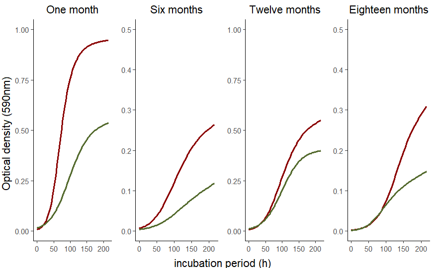

```r
M18AWCD <- bind_rows(AWCD_M18H0,AWCD_M18H72,AWCD_M18H144,AWCD_M18H216)
##AWCD_M18_Plot####
AWCD_M18 <- ggplot(M18AWCD, aes(incubation,AWCD,fill = treatment,
                                colour = treatment))+
  #  geom_jitter(show.legend = F, shape=1, height = 0, width = 40)+
  binomial_smooth(formula = y ~ splines::ns(x, 3), se=F,show.legend = F)+
  scale_colour_manual(values = c("red4","darkolivegreen"))+
  scale_fill_manual(values = c("red4","darkolivegreen"))+
  xlim(0,216)+
  ylim(0,.5)+
  theme+
  theme(plot.title=element_text(hjust=0.5))+
  labs(x =NULL, y = NULL,title ='Eighteen months')#

# AWCD Plots* (Growth curves) ####
#W. S. Cleveland, E. Grosse and W. M. Shyu (1992) Local regression models.
#Chapter 8 of Statistical Models in S eds J.M. Chambers and T.J. Hastie,
#Wadsworth & Brooks/Cole.
#install.packages(gridExtra)
library(gridExtra)
#install.packages("grid")
library(grid)
AWCD.Plots <-
  grid.arrange(AWCD_M1, AWCD_M6, AWCD_M12, AWCD_M18,
               ncol = 4, nrow = 1, heights = c(1),
               padding = unit(0.2, "line"),
               left = textGrob("Optical density (590nm)",
                               rot = 90, gp = gpar(fontsize = 13)),
               bottom = textGrob("incubation period (h)",
                                 rot = 0, gp = gpar(fontsize = 13)))
```

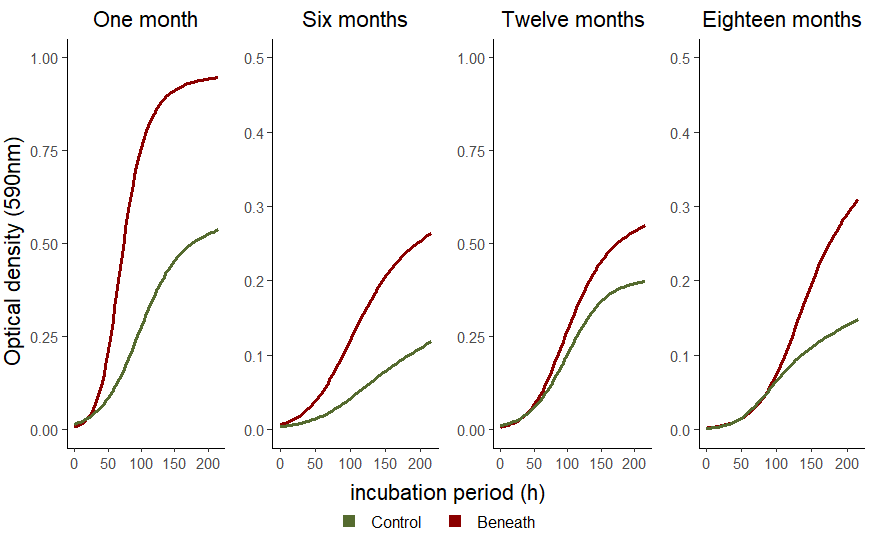

```r
legend <- legendGrob(c("Control","Beneath"),nrow = 1, pch=15,
                     gp=gpar(col = c("darkolivegreen","red4")
                             , fill = c("darkolivegreen","red4")
                             ,cex = .8))
AWCD_only <- grid.arrange(AWCD.Plots,
                          legend,
                          heights = c(20,1.5))
```

In conjunction with the growth phase results the time-point selection criteria included: The number of responses(>0.25), values above 2 and standard deviation (Weber & Legge 2010).

```r
##H0####
#Month1
Above0.25CtrlM1H0 <-  sum(M1H0[c(1:10),3:33]>0.25)
Above0.25BnthlM1H0 <- sum(M1H0[c(11:20),3:33]>0.25)
Above2CtrlM1H0 <-  sum(M1H0[c(1:10),3:33]>2)
Above2BnthlM1H0 <- sum(M1H0[c(11:20),3:33]>2)
#Month6
Above0.25CtrlM6H0 <-  sum(M6H0[c(1:10),3:33]>0.25)
Above0.25BnthlM6H0 <- sum(M6H0[c(11:20),3:33]>0.25)
Above2CtrlM6H0 <-  sum(M6H0[c(1:10),3:33]>2)
Above2BnthlM6H0 <- sum(M6H0[c(11:20),3:33]>2)
#Month12
Above0.25CtrlM12H0 <-  sum(M12H0[c(1:10),3:33]>0.25)
Above0.25BnthlM12H0 <- sum(M12H0[c(11:20),3:33]>0.25)
Above2CtrlM12H0 <-  sum(M12H0[c(1:10),3:33]>2)
Above2BnthlM12H0 <- sum(M12H0[c(11:20),3:33]>2)
#Month18
Above0.25CtrlM18H0 <-  sum(M18H0[c(1:10),3:33]>0.25)
Above0.25BnthlM18H0 <- sum(M18H0[c(11:20),3:33]>0.25)
Above2CtrlM18H0 <-  sum(M18H0[c(1:10),3:33]>2)
Above2BnthlM18H0 <- sum(M18H0[c(11:20),3:33]>2)
##H72####
#Month1
Above0.25CtrlM1H72 <-  sum(M1H72[c(1:10),3:33]>0.25)
Above0.25BnthlM1H72 <- sum(M1H72[c(11:20),3:33]>0.25)
Above2CtrlM1H72 <-  sum(M1H72[c(1:10),3:33]>2)
Above2BnthlM1H72 <- sum(M1H72[c(11:20),3:33]>2)
#Month6
Above0.25CtrlM6H72 <-  sum(M6H72[c(1:10),3:33]>0.25)
Above0.25BnthlM6H72 <- sum(M6H72[c(11:20),3:33]>0.25)
Above2CtrlM6H72 <-  sum(M6H72[c(1:10),3:33]>2)
Above2BnthlM6H72 <- sum(M6H72[c(11:20),3:33]>2)
#Month12
Above0.25CtrlM12H72 <-  sum(M12H72[c(1:10),3:33]>0.25)
Above0.25BnthlM12H72 <- sum(M12H72[c(11:20),3:33]>0.25)
Above2CtrlM12H72 <-  sum(M12H72[c(1:10),3:33]>2)
Above2BnthlM12H72 <- sum(M12H72[c(11:20),3:33]>2)
#Month18
Above0.25CtrlM18H72 <-  sum(M18H72[c(1:10),3:33]>0.25)
Above0.25BnthlM18H72 <- sum(M18H72[c(11:20),3:33]>0.25)
Above2CtrlM18H72 <-  sum(M18H72[c(1:10),3:33]>2)
Above2BnthlM18H72 <- sum(M18H72[c(11:20),3:33]>2)
##H144####
#Month1
Above0.25CtrlM1H144 <-  sum(M12H72[c(1:10),3:33]>0.25)
Above0.25BnthlM1H144 <- sum(M12H72[c(11:20),3:33]>0.25)
Above2CtrlM1H144 <-  sum(M1H144[c(1:10),3:33]>2)
Above2BnthlM1H144 <- sum(M1H144[c(11:20),3:33]>2)
#Month6
Above0.25CtrlM6H144 <-  sum(M6H72[c(1:10),3:33]>0.25)
Above0.25BnthlM6H144 <- sum(M6H72[c(11:20),3:33]>0.25)
Above2CtrlM6H144 <-  sum(M6H144[c(1:10),3:33]>2)
Above2BnthlM6H144 <- sum(M6H144[c(11:20),3:33]>2)
#Month12
Above0.25CtrlM12H144 <-  sum(M12H72[c(1:10),3:33]>0.25)
Above0.25BnthlM12H144 <- sum(M12H72[c(11:20),3:33]>0.25)
Above2CtrlM12H144 <-  sum(M12H144[c(1:10),3:33]>2)
Above2BnthlM12H144 <- sum(M12H144[c(11:20),3:33]>2)
#Month18
Above0.25CtrlM18H144 <-  sum(M12H72[c(1:10),3:33]>0.25)
Above0.25BnthlM18H144 <- sum(M12H72[c(11:20),3:33]>0.25)
Above2CtrlM18H144 <-  sum(M18H144[c(1:10),3:33]>2)
Above2BnthlM18H144 <- sum(M18H144[c(11:20),3:33]>2)
##H216####
#Month1
Above0.25CtrlM1H216 <-  sum(M1H216[c(1:10),3:33]>0.25)
Above0.25BnthlM1H216 <- sum(M1H216[c(11:20),3:33]>0.25)
Above2CtrlM1H216 <-  sum(M1H216[c(1:10),3:33]>2)
Above2BnthlM1H216 <- sum(M1H216[c(11:20),3:33]>2)
#Month6
Above0.25CtrlM6H216 <-  sum(M12H72[c(1:10),3:33]>0.25)
Above0.25BnthlM6H216 <- sum(M12H72[c(11:20),3:33]>0.25)
Above2CtrlM6H216 <-  sum(M6H216[c(1:10),3:33]>2)
Above2BnthlM6H216 <- sum(M6H216[c(11:20),3:33]>2)
#Month12
Above0.25CtrlM12H216 <-  sum(M12H216[c(1:10),3:33]>0.25)
Above0.25BnthlM12H216 <- sum(M12H216[c(11:20),3:33]>0.25)
Above2CtrlM12H216 <-  sum(M12H216[c(1:10),3:33]>2)
Above2BnthlM12H216 <- sum(M12H216[c(11:20),3:33]>2)
#Month18
Above0.25CtrlM18H216 <-  sum(M18H216[c(1:10),3:33]>0.25)
Above0.25BnthlM18H216 <- sum(M18H216[c(11:20),3:33]>0.25)
Above2CtrlM18H216 <-  sum(M18H216[c(1:10),3:33]>2)
Above2BnthlM18H216 <- sum(M18H216[c(11:20),3:33]>2)

Sm_H0Ctrl.25 <- sum(Above0.25CtrlM1H0,
    Above0.25CtrlM6H0,
    Above0.25CtrlM12H0,
    Above0.25CtrlM18H0<0)

Sm_H0Bnth.25 <- sum(Above0.25BnthlM1H0,
    Above0.25BnthlM6H0,
    Above0.25BnthlM12H0,
    Above0.25BnthlM18H0>0)

Sm_H0Ctrl2 <- sum(Above2CtrlM1H0,
    Above2CtrlM6H0,
    Above2CtrlM12H0,
    Above2CtrlM18H0>0)

Sm_H0Bnth2 <- sum(Above2BnthlM1H0,
    Above2BnthlM6H0,
    Above2BnthlM12H0,
    Above2BnthlM18H0>0)

SD_H0 <- mean(mean(SD_M1H0$`Standard deviation`[c(1:10)]),
     mean(SD_M1H0$`Standard deviation`[c(11:20)]),
     mean(SD_M6H0$`Standard deviation`[c(1:10)]),
     mean(SD_M6H0$`Standard deviation`[c(11:20)]),
     mean(SD_M12H0$`Standard deviation`[c(1:10)]),
     mean(SD_M12H0$`Standard deviation`[c(11:20)]),
     mean(SD_M18H0$`Standard deviation`[c(1:10)]),
     mean(SD_M18H0$`Standard deviation`[c(11:20)]))

#H72
Sm_H72Ctrl.25 <- sum(Above0.25CtrlM1H72,
    Above0.25CtrlM6H72,
    Above0.25CtrlM12H72,
    Above0.25CtrlM18H72<0)

Sm_H72Bnth.25 <- sum(Above0.25BnthlM1H72,
    Above0.25BnthlM6H72,
    Above0.25BnthlM12H72,
    Above0.25BnthlM18H72>0)

Sm_H72Ctrl2 <- sum(Above2CtrlM1H72,
    Above2CtrlM6H72,
    Above2CtrlM12H72,
    Above2CtrlM18H72>0)

Sm_H72Bnth2 <- sum(Above2BnthlM1H72,
    Above2BnthlM6H72,
    Above2BnthlM12H72,
    Above2BnthlM18H72>0)

SD_H72 <- mean(mean(SD_M1H72$`Standard deviation`[c(1:10)]),
     mean(SD_M1H72$`Standard deviation`[c(11:20)]),
     mean(SD_M6H72$`Standard deviation`[c(1:10)]),
     mean(SD_M6H72$`Standard deviation`[c(11:20)]),
     mean(SD_M12H72$`Standard deviation`[c(1:10)]),
     mean(SD_M12H72$`Standard deviation`[c(11:20)]),
     mean(SD_M18H72$`Standard deviation`[c(1:10)]),
     mean(SD_M18H72$`Standard deviation`[c(11:20)]))

#H144
Sm_H144Ctrl.25 <- sum(Above0.25CtrlM1H144,
    Above0.25CtrlM6H144,
    Above0.25CtrlM12H144,
    Above0.25CtrlM18H144<0)

Sm_H144Bnth.25 <- sum(Above0.25BnthlM1H144,
    Above0.25BnthlM6H144,
    Above0.25BnthlM12H144,
    Above0.25BnthlM18H144>0)

Sm_H144Ctrl2 <- sum(Above2CtrlM1H144,
    Above2CtrlM6H144,
    Above2CtrlM12H144,
    Above2CtrlM18H144>0)

Sm_H144Bnth2 <- sum(Above2BnthlM1H144,
    Above2BnthlM6H144,
    Above2BnthlM12H144,
    Above2BnthlM18H144>0)

SD_H144 <- mean(mean(SD_M1H144$`Standard deviation`[c(1:10)]),
     mean(SD_M1H144$`Standard deviation`[c(11:20)]),
     mean(SD_M6H144$`Standard deviation`[c(1:10)]),
     mean(SD_M6H144$`Standard deviation`[c(11:20)]),
     mean(SD_M12H144$`Standard deviation`[c(1:10)]),
     mean(SD_M12H144$`Standard deviation`[c(11:20)]),
     mean(SD_M18H144$`Standard deviation`[c(1:10)]),
     mean(SD_M18H144$`Standard deviation`[c(11:20)]))

#216
Sm_H216Ctrl.25 <- sum(Above0.25CtrlM1H216,
    Above0.25CtrlM6H216,
    Above0.25CtrlM12H216,
    Above0.25CtrlM18H216<0)

Sm_H216Bnth.25 <- sum(Above0.25BnthlM1H216,
    Above0.25BnthlM6H216,
    Above0.25BnthlM12H216,
    Above0.25BnthlM18H216>0)

Sm_H216Ctrl2 <- sum(Above2CtrlM1H216,
    Above2CtrlM6H216,
    Above2CtrlM12H216,
    Above2CtrlM18H216>0)

Sm_H216Bnth2 <- sum(Above2BnthlM1H216,
    Above2BnthlM6H216,
    Above2BnthlM12H216,
    Above2BnthlM18H216>0)

SD_H216 <- mean(mean(SD_M1H216$`Standard deviation`[c(1:10)]),
     mean(SD_M1H216$`Standard deviation`[c(11:20)]),
     mean(SD_M6H216$`Standard deviation`[c(1:10)]),
     mean(SD_M6H216$`Standard deviation`[c(11:20)]),
     mean(SD_M12H216$`Standard deviation`[c(1:10)]),
     mean(SD_M12H216$`Standard deviation`[c(11:20)]),
     mean(SD_M18H216$`Standard deviation`[c(1:10)]),
     mean(SD_M18H216$`Standard deviation`[c(11:20)]))
#Criteria Results Summary ####
summary_criteria_results <- data.frame(
  TimePoint = c("H0", "H72", "H144", "H216"),
  Sm_H0Ctrl.25 = c(Sm_H0Ctrl.25, Sm_H72Ctrl.25, Sm_H144Ctrl.25, Sm_H216Ctrl.25),
  Sm_H0Bnth.25 = c(Sm_H0Bnth.25, Sm_H72Bnth.25, Sm_H144Bnth.25, Sm_H216Bnth.25),
  Sm_H0Ctrl2 = c(Sm_H0Ctrl2, Sm_H72Ctrl2, Sm_H144Ctrl2, Sm_H216Ctrl2),
  Sm_H0Bnth2 = c(Sm_H0Bnth2, Sm_H72Bnth2, Sm_H144Bnth2, Sm_H216Bnth2),
  SD_H0 = c(SD_H0, SD_H72, SD_H144, SD_H216)
)

# Print the summary data frame
print(summary_criteria_results)
```

| TimePoint | Sm_H0Ctrl.25 | Sm_H0Bnth.25 | Sm_H0Ctrl2 | Sm_H0Bnth2 | SD_H0 |
| --- | --- | --- | --- | --- | --- |
| H0 | 0 | 0 | 0 | 0 | 0.01402298 |
| H72 | 147 | 296 | 0 | 6 | 0.50100173 |
| H144 | 131 | 174 | 4 | 41 | 0.62092220 |
| H216 | 425 | 544 | 9 | 56 | 0.64105223 |

```r
#-end of AWCD section#####
```

One hundred forty-four incubation hours was selected as the most appropriate time point for comparison. In section below the: “EcoPlate_rezult <- EcoPlate_rezult/mean(EcoPlate_rezult)” #REMOVED FOR AWCD and “EcoPlate_rezult <- log2(EcoPlate_rezult+1)” are replaced in the function.

```r
EcoPlate_standards <- function(data){#Substrate mean-blank mean and <0=0
  EcoPlate_rezult <- rowMeans(data.frame(bind_cols(as.data.frame(
    ifelse(data.frame(s1=c(data$V1,data$V2,data$V3,data$V4))
           -mean(c(data$V1[1],data$V5[1],data$V9[1]))<0,0,
           (s1=c(data$V1,data$V2,data$V3,data$V4))
           -mean(c(data$V1[1],data$V5[1],data$V9[1])))),
    ifelse(data.frame(s2=c(data$V5,data$V6,data$V7,data$V8))
           -mean(c(data$V1[1],data$V5[1],data$V9[1]))<0,0,
           (s2=c(data$V5,data$V6,data$V7,data$V8))
           -mean(c(data$V1[1],data$V5[1],data$V9[1]))),
    ifelse(data.frame(s3=c(data$V9,data$V10,data$V11,data$V12))
           -mean(c(data$V1[1],data$V5[1],data$V9[1]))<0,0,
           (s3=c(data$V9,data$V10,data$V11,data$V12))
           -mean(c(data$V1[1],data$V5[1],data$V9[1]))))))[-1]
  EcoPlate_rezult <- EcoPlate_rezult # Just the means
    EcoPlate_rezult <- EcoPlate_rezult/mean(EcoPlate_rezult) #REMOVE FOR AWCD
   EcoPlate_rezult <- log2(EcoPlate_rezult+1)#REMOVE FOR AWCD
  return(EcoPlate_rezult)
}
```

```r
EcoPlate_grouped <- function(samples){
  Grouped_samples <- samples%>%
    t()%>%
    `colnames<-`(as.character(c("Pyruvic Acid Methyl Ester","Tween 40", "Tween 80","α-Cyclodextrin","Glycogen","D-Cellobiose", "α-D-Lactose",  "β-Methyl-D-Glucoside", "D-Xylose","i-Erythritol","D-Mannitol", "N-Acetyl-D-Glucosamine","D-Glucosaminic Acid","Glucose-1-Phosphate","D,L-α-Glycerol Phosphate","D-Galactonic Acid γ-Lactone", "D-Galacturonic Acid","2-Hydroxy Benzoic Acid", "4-Hydroxy Benzoic Acid", "γ-Amino Butyric Acid","Itaconic Acid", "α-Keto Butyric Acid","D-Malic Acid","L-Arginine", "L-Asparagine", "L-Phenylalanine", "L-Serine", "L-Threonine", "Glycyl-L-Glutamic Acid","Phenylethylamine", "Putrescine")))%>%

    cbind.data.frame(Site,Group)%>%
    relocate(Site,.before = "Pyruvic Acid Methyl Ester")%>%
    relocate(Group,.after = Site)%>%
    as.data.frame()

  return(Grouped_samples)
}
```

The data is again imported but this time it isStandardised and transformed b the function. (Created files are rewritten and replaced)

```r
##H0####
###M1####
M1H0_0M <- read_csv("Month1_Hours0.csv")

M1H0_S1_0M <- EcoPlate_standards(setNames(data.frame(M1H0_0M[c(1:8),1:12]),
                                          paste0("V",seq_along(data.frame(M1H0_0M[c(1:8),1:12])))))
M1H0_S1_2M <- EcoPlate_standards(setNames(data.frame(M1H0_0M[c(10:17),1:12]),
                                          paste0("V",seq_along(data.frame(M1H0_0M[c(10:17),1:12])))))
M1H0_S1_5M <- EcoPlate_standards(setNames(data.frame(M1H0_0M[c(19:26),1:12]),
                                          paste0("V",seq_along(data.frame(M1H0_0M[c(19:26),1:12])))))
M1H0_S3_0M <- EcoPlate_standards(setNames(data.frame(M1H0_0M[c(28:35),1:12]),
                                          paste0("V",seq_along(data.frame(M1H0_0M[c(28:35),1:12])))))
M1H0_S3_2M <- EcoPlate_standards(setNames(data.frame(M1H0_0M[c(37:44),1:12]),
                                          paste0("V",seq_along(data.frame(M1H0_0M[c(37:44),1:12])))))
M1H0_S3_5M <- EcoPlate_standards(setNames(data.frame(M1H0_0M[c(46:53),1:12]),
                                          paste0("V",seq_along(data.frame(M1H0_0M[c(46:53),1:12])))))
M1H0_S6_0M <- EcoPlate_standards(setNames(data.frame(M1H0_0M[c(55:62),1:12]),
                                          paste0("V",seq_along(data.frame(M1H0_0M[c(55:62),1:12])))))
M1H0_S6_2M <- EcoPlate_standards(setNames(data.frame(M1H0_0M[c(64:71),1:12]),
                                          paste0("V",seq_along(data.frame(M1H0_0M[c(64:71),1:12])))))
M1H0_S6_5M <- EcoPlate_standards(setNames(data.frame(M1H0_0M[c(73:80),1:12]),
                                          paste0("V",seq_along(data.frame(M1H0_0M[c(73:80),1:12])))))
M1H0_S13_0M <- EcoPlate_standards(setNames(data.frame(M1H0_0M[c(82:89),1:12]),
                                           paste0("V",seq_along(data.frame(M1H0_0M[c(82:89),1:12])))))
M1H0_S13_2M <- EcoPlate_standards(setNames(data.frame(M1H0_0M[c(91:98),1:12]),
                                           paste0("V",seq_along(data.frame(M1H0_0M[c(97:98),1:12])))))
M1H0_S13_5M <- EcoPlate_standards(setNames(data.frame(M1H0_0M[c(100:107),1:12]),
                                           paste0("V",seq_along(data.frame(M1H0_0M[c(100:107),1:12])))))
M1H0_S15_0M <- EcoPlate_standards(setNames(data.frame(M1H0_0M[c(109:116),1:12]),
                                           paste0("V",seq_along(data.frame(M1H0_0M[c(109:116),1:12])))))
M1H0_S15_2M <- EcoPlate_standards(setNames(data.frame(M1H0_0M[c(118:125),1:12]),
                                           paste0("V",seq_along(data.frame(M1H0_0M[c(118:125),1:12])))))
M1H0_S15_5M <- EcoPlate_standards(setNames(data.frame(M1H0_0M[c(127:134),1:12]),
                                           paste0("V",seq_along(data.frame(M1H0_0M[c(127:134),1:12])))))

M1H0_0Mb <- read_csv("Month1_Hours0b.csv")

M1H0_S4_0M <- EcoPlate_standards(setNames(data.frame(M1H0_0Mb[c(1:8),1:12]),
                                          paste0("V",seq_along(data.frame(M1H0_0Mb[c(1:8),1:12])))))
M1H0_S4_2M <- EcoPlate_standards(setNames(data.frame(M1H0_0Mb[c(10:17),1:12]),
                                          paste0("V",seq_along(data.frame(M1H0_0Mb[c(10:17),1:12])))))
M1H0_S4_5M <- EcoPlate_standards(setNames(data.frame(M1H0_0Mb[c(19:26),1:12]),
                                          paste0("V",seq_along(data.frame(M1H0_0Mb[c(19:26),1:12])))))
M1H0_S8_0M <- EcoPlate_standards(setNames(data.frame(M1H0_0Mb[c(28:35),1:12]),
                                          paste0("V",seq_along(data.frame(M1H0_0Mb[c(28:35),1:12])))))
M1H0_S8_2M <- EcoPlate_standards(setNames(data.frame(M1H0_0Mb[c(37:44),1:12]),
                                          paste0("V",seq_along(data.frame(M1H0_0Mb[c(37:44),1:12])))))
M1H0_S8_5M <- EcoPlate_standards(setNames(data.frame(M1H0_0Mb[c(46:53),1:12]),
                                          paste0("V",seq_along(data.frame(M1H0_0Mb[c(46:53),1:12])))))
M1H0_S9_0M <- EcoPlate_standards(setNames(data.frame(M1H0_0Mb[c(55:62),1:12]),
                                          paste0("V",seq_along(data.frame(M1H0_0Mb[c(55:62),1:12])))))
M1H0_S9_2M <- EcoPlate_standards(setNames(data.frame(M1H0_0Mb[c(64:71),1:12]),
                                          paste0("V",seq_along(data.frame(M1H0_0Mb[c(64:71),1:12])))))
M1H0_S9_5M <- EcoPlate_standards(setNames(data.frame(M1H0_0Mb[c(73:80),1:12]),
                                          paste0("V",seq_along(data.frame(M1H0_0Mb[c(73:80),1:12])))))
M1H0_S11_0M <- EcoPlate_standards(setNames(data.frame(M1H0_0Mb[c(82:89),1:12]),
                                           paste0("V",seq_along(data.frame(M1H0_0Mb[c(82:89),1:12])))))
M1H0_S11_2M <- EcoPlate_standards(setNames(data.frame(M1H0_0Mb[c(91:98),1:12]),
                                           paste0("V",seq_along(data.frame(M1H0_0Mb[c(97:98),1:12])))))
M1H0_S11_5M <- EcoPlate_standards(setNames(data.frame(M1H0_0Mb[c(100:107),1:12]),
                                           paste0("V",seq_along(data.frame(M1H0_0Mb[c(100:107),1:12])))))
M1H0_S12_0M <- EcoPlate_standards(setNames(data.frame(M1H0_0Mb[c(109:116),1:12]),
                                           paste0("V",seq_along(data.frame(M1H0_0Mb[c(109:116),1:12])))))
M1H0_S12_2M <- EcoPlate_standards(setNames(data.frame(M1H0_0Mb[c(118:125),1:12]),
                                           paste0("V",seq_along(data.frame(M1H0_0Mb[c(118:125),1:12])))))
M1H0_S12_5M <- EcoPlate_standards(setNames(data.frame(M1H0_0Mb[c(127:134),1:12]),
                                           paste0("V",seq_along(data.frame(M1H0_0Mb[c(127:134),1:12])))))

# Group the plates of the same sample-time
M1H0_samples <- bind_cols(M1H0_S1_5M,M1H0_S3_5M,M1H0_S4_5M,M1H0_S6_5M,M1H0_S8_5M,
                          M1H0_S9_5M,M1H0_S11_5M,M1H0_S12_5M,M1H0_S13_5M,M1H0_S15_5M,
                          M1H0_S1_0M,M1H0_S3_0M,M1H0_S4_0M,M1H0_S6_0M,M1H0_S8_0M,
                          M1H0_S9_0M,M1H0_S11_0M,M1H0_S12_0M,M1H0_S13_0M,M1H0_S15_0M,
                          M1H0_S1_2M,M1H0_S3_2M,M1H0_S4_2M,M1H0_S6_2M,M1H0_S8_2M,
                          M1H0_S9_2M,M1H0_S11_2M,M1H0_S12_2M,M1H0_S13_2M,M1H0_S15_2M
)
```

```r
# Create grouped Ecoplate data frames to compare
M1H0 <- EcoPlate_grouped(M1H0_samples)
write.csv(M1H0,file = "M1H0.csv",row.names = F)

###M6####
M6H0_0M <- read_csv("Month6_Hours0.csv")
M6H0_S1_0M <- EcoPlate_standards(setNames(data.frame(M6H0_0M[c(1:8),1:12]),
                                          paste0("V",seq_along(data.frame(M6H0_0M[c(1:8),1:12])))))
M6H0_S1_2M <- EcoPlate_standards(setNames(data.frame(M6H0_0M[c(10:17),1:12]),
                                          paste0("V",seq_along(data.frame(M6H0_0M[c(10:17),1:12])))))
M6H0_S1_5M <- EcoPlate_standards(setNames(data.frame(M6H0_0M[c(19:26),1:12]),
                                          paste0("V",seq_along(data.frame(M6H0_0M[c(19:26),1:12])))))
M6H0_S3_0M <- EcoPlate_standards(setNames(data.frame(M6H0_0M[c(28:35),1:12]),
                                          paste0("V",seq_along(data.frame(M6H0_0M[c(28:35),1:12])))))
M6H0_S3_2M <- EcoPlate_standards(setNames(data.frame(M6H0_0M[c(37:44),1:12]),
                                          paste0("V",seq_along(data.frame(M6H0_0M[c(37:44),1:12])))))
M6H0_S3_5M <- EcoPlate_standards(setNames(data.frame(M6H0_0M[c(46:53),1:12]),
                                          paste0("V",seq_along(data.frame(M6H0_0M[c(46:53),1:12])))))
M6H0_S6_0M <- EcoPlate_standards(setNames(data.frame(M6H0_0M[c(55:62),1:12]),
                                          paste0("V",seq_along(data.frame(M6H0_0M[c(55:62),1:12])))))
M6H0_S6_2M <- EcoPlate_standards(setNames(data.frame(M6H0_0M[c(64:71),1:12]),
                                          paste0("V",seq_along(data.frame(M6H0_0M[c(64:71),1:12])))))
M6H0_S6_5M <- EcoPlate_standards(setNames(data.frame(M6H0_0M[c(73:80),1:12]),
                                          paste0("V",seq_along(data.frame(M6H0_0M[c(73:80),1:12])))))
M6H0_S13_0M <- EcoPlate_standards(setNames(data.frame(M6H0_0M[c(82:89),1:12]),
                                           paste0("V",seq_along(data.frame(M6H0_0M[c(82:89),1:12])))))
M6H0_S13_2M <- EcoPlate_standards(setNames(data.frame(M6H0_0M[c(91:98),1:12]),
                                           paste0("V",seq_along(data.frame(M6H0_0M[c(97:98),1:12])))))
M6H0_S13_5M <- EcoPlate_standards(setNames(data.frame(M6H0_0M[c(100:107),1:12]),
                                           paste0("V",seq_along(data.frame(M6H0_0M[c(100:107),1:12])))))
M6H0_S15_0M <- EcoPlate_standards(setNames(data.frame(M6H0_0M[c(109:116),1:12]),
                                           paste0("V",seq_along(data.frame(M6H0_0M[c(109:116),1:12])))))
M6H0_S15_2M <- EcoPlate_standards(setNames(data.frame(M6H0_0M[c(118:125),1:12]),
                                           paste0("V",seq_along(data.frame(M6H0_0M[c(118:125),1:12])))))
M6H0_S15_5M <- EcoPlate_standards(setNames(data.frame(M6H0_0M[c(127:134),1:12]),
                                           paste0("V",seq_along(data.frame(M6H0_0M[c(127:134),1:12])))))

M6H0_0Mb <- read_csv("Months6_Hours0b.csv")
M6H0_S4_0M <- EcoPlate_standards(setNames(data.frame(M6H0_0Mb[c(1:8),1:12]),
                                          paste0("V",seq_along(data.frame(M6H0_0Mb[c(1:8),1:12])))))
M6H0_S4_2M <- EcoPlate_standards(setNames(data.frame(M6H0_0Mb[c(10:17),1:12]),
                                          paste0("V",seq_along(data.frame(M6H0_0Mb[c(10:17),1:12])))))
M6H0_S4_5M <- EcoPlate_standards(setNames(data.frame(M6H0_0Mb[c(19:26),1:12]),
                                          paste0("V",seq_along(data.frame(M6H0_0Mb[c(19:26),1:12])))))
M6H0_S8_0M <- EcoPlate_standards(setNames(data.frame(M6H0_0Mb[c(28:35),1:12]),
                                          paste0("V",seq_along(data.frame(M6H0_0Mb[c(28:35),1:12])))))
M6H0_S8_2M <- EcoPlate_standards(setNames(data.frame(M6H0_0Mb[c(37:44),1:12]),
                                          paste0("V",seq_along(data.frame(M6H0_0Mb[c(37:44),1:12])))))
M6H0_S8_5M <- EcoPlate_standards(setNames(data.frame(M6H0_0Mb[c(46:53),1:12]),
                                          paste0("V",seq_along(data.frame(M6H0_0Mb[c(46:53),1:12])))))
M6H0_S9_0M <- EcoPlate_standards(setNames(data.frame(M6H0_0Mb[c(55:62),1:12]),
                                          paste0("V",seq_along(data.frame(M6H0_0Mb[c(55:62),1:12])))))
M6H0_S9_2M <- EcoPlate_standards(setNames(data.frame(M6H0_0Mb[c(64:71),1:12]),
                                          paste0("V",seq_along(data.frame(M6H0_0Mb[c(64:71),1:12])))))
M6H0_S9_5M <- EcoPlate_standards(setNames(data.frame(M6H0_0Mb[c(73:80),1:12]),
                                          paste0("V",seq_along(data.frame(M6H0_0Mb[c(73:80),1:12])))))
M6H0_S11_0M <- EcoPlate_standards(setNames(data.frame(M6H0_0Mb[c(82:89),1:12]),
                                           paste0("V",seq_along(data.frame(M6H0_0Mb[c(82:89),1:12])))))
M6H0_S11_2M <- EcoPlate_standards(setNames(data.frame(M6H0_0Mb[c(91:98),1:12]),
                                           paste0("V",seq_along(data.frame(M6H0_0Mb[c(97:98),1:12])))))
M6H0_S11_5M <- EcoPlate_standards(setNames(data.frame(M6H0_0Mb[c(100:107),1:12]),
                                           paste0("V",seq_along(data.frame(M6H0_0Mb[c(100:107),1:12])))))
M6H0_S12_0M <- EcoPlate_standards(setNames(data.frame(M6H0_0Mb[c(109:116),1:12]),
                                           paste0("V",seq_along(data.frame(M6H0_0Mb[c(109:116),1:12])))))
M6H0_S12_2M <- EcoPlate_standards(setNames(data.frame(M6H0_0Mb[c(118:125),1:12]),
                                           paste0("V",seq_along(data.frame(M6H0_0Mb[c(118:125),1:12])))))
M6H0_S12_5M <- EcoPlate_standards(setNames(data.frame(M6H0_0Mb[c(127:134),1:12]),
                                           paste0("V",seq_along(data.frame(M6H0_0Mb[c(127:134),1:12])))))

# Group the plates of the same sample-time
M6H0_samples <- bind_cols(M6H0_S1_5M,M6H0_S3_5M,M6H0_S4_5M,M6H0_S6_5M,M6H0_S8_5M,
                          M6H0_S9_5M,M6H0_S11_5M,M6H0_S12_5M,M6H0_S13_5M,M6H0_S15_5M,
                          M6H0_S1_0M,M6H0_S3_0M,M6H0_S4_0M,M6H0_S6_0M,M6H0_S8_0M,
                          M6H0_S9_0M,M6H0_S11_0M,M6H0_S12_0M,M6H0_S13_0M,M6H0_S15_0M,
                          M6H0_S1_2M,M6H0_S3_2M,M6H0_S4_2M,M6H0_S6_2M,M6H0_S8_2M,
                          M6H0_S9_2M,M6H0_S11_2M,M6H0_S12_2M,M6H0_S13_2M,M6H0_S15_2M
)
```

```r
# Create grouped Ecoplate data frames to compare
M6H0 <- EcoPlate_grouped(M6H0_samples)
write.csv(M6H0,file = "M6H0.csv",row.names = F)
###M12####
M12H0_0M <- read_csv("Month12_Hours0.csv")
M12H0_S1_0M <- EcoPlate_standards(setNames(data.frame(M12H0_0M[c(1:8),1:12]),
                                           paste0("V",seq_along(data.frame(M12H0_0M[c(1:8),1:12])))))
M12H0_S1_2M <- EcoPlate_standards(setNames(data.frame(M12H0_0M[c(10:17),1:12]),
                                           paste0("V",seq_along(data.frame(M12H0_0M[c(10:17),1:12])))))
M12H0_S1_5M <- EcoPlate_standards(setNames(data.frame(M12H0_0M[c(19:26),1:12]),
                                           paste0("V",seq_along(data.frame(M12H0_0M[c(19:26),1:12])))))
M12H0_S3_0M <- EcoPlate_standards(setNames(data.frame(M12H0_0M[c(28:35),1:12]),
                                           paste0("V",seq_along(data.frame(M12H0_0M[c(28:35),1:12])))))
M12H0_S3_2M <- EcoPlate_standards(setNames(data.frame(M12H0_0M[c(37:44),1:12]),
                                           paste0("V",seq_along(data.frame(M12H0_0M[c(37:44),1:12])))))
M12H0_S3_5M <- EcoPlate_standards(setNames(data.frame(M12H0_0M[c(46:53),1:12]),
                                           paste0("V",seq_along(data.frame(M12H0_0M[c(46:53),1:12])))))
M12H0_S6_0M <- EcoPlate_standards(setNames(data.frame(M12H0_0M[c(55:62),1:12]),
                                           paste0("V",seq_along(data.frame(M12H0_0M[c(55:62),1:12])))))
M12H0_S6_2M <- EcoPlate_standards(setNames(data.frame(M12H0_0M[c(64:71),1:12]),
                                           paste0("V",seq_along(data.frame(M12H0_0M[c(64:71),1:12])))))
M12H0_S6_5M <- EcoPlate_standards(setNames(data.frame(M12H0_0M[c(73:80),1:12]),
                                           paste0("V",seq_along(data.frame(M12H0_0M[c(73:80),1:12])))))
M12H0_S13_0M <- EcoPlate_standards(setNames(data.frame(M12H0_0M[c(82:89),1:12]),
                                            paste0("V",seq_along(data.frame(M12H0_0M[c(82:89),1:12])))))
M12H0_S13_2M <- EcoPlate_standards(setNames(data.frame(M12H0_0M[c(91:98),1:12]),
                                            paste0("V",seq_along(data.frame(M12H0_0M[c(97:98),1:12])))))
M12H0_S13_5M <- EcoPlate_standards(setNames(data.frame(M12H0_0M[c(100:107),1:12]),
                                            paste0("V",seq_along(data.frame(M12H0_0M[c(100:107),1:12])))))
M12H0_S15_0M <- EcoPlate_standards(setNames(data.frame(M12H0_0M[c(109:116),1:12]),
                                            paste0("V",seq_along(data.frame(M12H0_0M[c(109:116),1:12])))))
M12H0_S15_2M <- EcoPlate_standards(setNames(data.frame(M12H0_0M[c(118:125),1:12]),
                                            paste0("V",seq_along(data.frame(M12H0_0M[c(118:125),1:12])))))
M12H0_S15_5M <- EcoPlate_standards(setNames(data.frame(M12H0_0M[c(127:134),1:12]),
                                            paste0("V",seq_along(data.frame(M12H0_0M[c(127:134),1:12])))))

M12H0_0Mb <- read_csv("Month12_Hours0b.csv")
M12H0_S4_0M <- EcoPlate_standards(setNames(data.frame(M12H0_0Mb[c(1:8),1:12]),
                                           paste0("V",seq_along(data.frame(M12H0_0Mb[c(1:8),1:12])))))
M12H0_S4_2M <- EcoPlate_standards(setNames(data.frame(M12H0_0Mb[c(10:17),1:12]),
                                           paste0("V",seq_along(data.frame(M12H0_0Mb[c(10:17),1:12])))))
M12H0_S4_5M <- EcoPlate_standards(setNames(data.frame(M12H0_0Mb[c(19:26),1:12]),
                                           paste0("V",seq_along(data.frame(M12H0_0Mb[c(19:26),1:12])))))
M12H0_S8_0M <- EcoPlate_standards(setNames(data.frame(M12H0_0Mb[c(28:35),1:12]),
                                           paste0("V",seq_along(data.frame(M12H0_0Mb[c(28:35),1:12])))))
M12H0_S8_2M <- EcoPlate_standards(setNames(data.frame(M12H0_0Mb[c(37:44),1:12]),
                                           paste0("V",seq_along(data.frame(M12H0_0Mb[c(37:44),1:12])))))
M12H0_S8_5M <- EcoPlate_standards(setNames(data.frame(M12H0_0Mb[c(46:53),1:12]),
                                           paste0("V",seq_along(data.frame(M12H0_0Mb[c(46:53),1:12])))))
M12H0_S9_0M <- EcoPlate_standards(setNames(data.frame(M12H0_0Mb[c(55:62),1:12]),
                                           paste0("V",seq_along(data.frame(M12H0_0Mb[c(55:62),1:12])))))
M12H0_S9_2M <- EcoPlate_standards(setNames(data.frame(M12H0_0Mb[c(64:71),1:12]),
                                           paste0("V",seq_along(data.frame(M12H0_0Mb[c(64:71),1:12])))))
M12H0_S9_5M <- EcoPlate_standards(setNames(data.frame(M12H0_0Mb[c(73:80),1:12]),
                                           paste0("V",seq_along(data.frame(M12H0_0Mb[c(73:80),1:12])))))
M12H0_S11_0M <- EcoPlate_standards(setNames(data.frame(M12H0_0Mb[c(82:89),1:12]),
                                            paste0("V",seq_along(data.frame(M12H0_0Mb[c(82:89),1:12])))))
M12H0_S11_2M <- EcoPlate_standards(setNames(data.frame(M12H0_0Mb[c(91:98),1:12]),
                                            paste0("V",seq_along(data.frame(M12H0_0Mb[c(97:98),1:12])))))
M12H0_S11_5M <- EcoPlate_standards(setNames(data.frame(M12H0_0Mb[c(100:107),1:12]),
                                            paste0("V",seq_along(data.frame(M12H0_0Mb[c(100:107),1:12])))))
M12H0_S12_0M <- EcoPlate_standards(setNames(data.frame(M12H0_0Mb[c(109:116),1:12]),
                                            paste0("V",seq_along(data.frame(M12H0_0Mb[c(109:116),1:12])))))
M12H0_S12_2M <- EcoPlate_standards(setNames(data.frame(M12H0_0Mb[c(118:125),1:12]),
                                            paste0("V",seq_along(data.frame(M12H0_0Mb[c(118:125),1:12])))))
M12H0_S12_5M <- EcoPlate_standards(setNames(data.frame(M12H0_0Mb[c(127:134),1:12]),
                                            paste0("V",seq_along(data.frame(M12H0_0Mb[c(127:134),1:12])))))

# Group the plates of the same sample-time
M12H0_samples <- bind_cols(M12H0_S1_5M,M12H0_S3_5M,M12H0_S4_5M,M12H0_S6_5M,M12H0_S8_5M,
                           M12H0_S9_5M,M12H0_S11_5M,M12H0_S12_5M,M12H0_S13_5M,M12H0_S15_5M,
                           M12H0_S1_0M,M12H0_S3_0M,M12H0_S4_0M,M12H0_S6_0M,M12H0_S8_0M,
                           M12H0_S9_0M,M12H0_S11_0M,M12H0_S12_0M,M12H0_S13_0M,M12H0_S15_0M,
                           M12H0_S1_2M,M12H0_S3_2M,M12H0_S4_2M,M12H0_S6_2M,M12H0_S8_2M,
                           M12H0_S9_2M,M12H0_S11_2M,M12H0_S12_2M,M12H0_S13_2M,M12H0_S15_2M
)
```

```r
# Create grouped Ecoplate data frames to compare
M12H0 <- EcoPlate_grouped(M12H0_samples)
write.csv(M12H0,file = "M12H0.csv",row.names = F)

M18H0_0M <- read_csv("Month18_Hours0.csv")
###M18####
M18H0_S1_0M <- EcoPlate_standards(setNames(data.frame(M18H0_0M[c(1:8),1:12]),
                                           paste0("V",seq_along(data.frame(M18H0_0M[c(1:8),1:12])))))
M18H0_S1_2M <- EcoPlate_standards(setNames(data.frame(M18H0_0M[c(10:17),1:12]),
                                           paste0("V",seq_along(data.frame(M18H0_0M[c(10:17),1:12])))))
M18H0_S1_5M <- EcoPlate_standards(setNames(data.frame(M18H0_0M[c(19:26),1:12]),
                                           paste0("V",seq_along(data.frame(M18H0_0M[c(19:26),1:12])))))
M18H0_S3_0M <- EcoPlate_standards(setNames(data.frame(M18H0_0M[c(28:35),1:12]),
                                           paste0("V",seq_along(data.frame(M18H0_0M[c(28:35),1:12])))))
M18H0_S3_2M <- EcoPlate_standards(setNames(data.frame(M18H0_0M[c(37:44),1:12]),
                                           paste0("V",seq_along(data.frame(M18H0_0M[c(37:44),1:12])))))
M18H0_S3_5M <- EcoPlate_standards(setNames(data.frame(M18H0_0M[c(46:53),1:12]),
                                           paste0("V",seq_along(data.frame(M18H0_0M[c(46:53),1:12])))))
M18H0_S6_0M <- EcoPlate_standards(setNames(data.frame(M18H0_0M[c(55:62),1:12]),
                                           paste0("V",seq_along(data.frame(M18H0_0M[c(55:62),1:12])))))
M18H0_S6_2M <- EcoPlate_standards(setNames(data.frame(M18H0_0M[c(64:71),1:12]),
                                           paste0("V",seq_along(data.frame(M18H0_0M[c(64:71),1:12])))))
M18H0_S6_5M <- EcoPlate_standards(setNames(data.frame(M18H0_0M[c(73:80),1:12]),
                                           paste0("V",seq_along(data.frame(M18H0_0M[c(73:80),1:12])))))
M18H0_S13_0M <- EcoPlate_standards(setNames(data.frame(M18H0_0M[c(82:89),1:12]),
                                            paste0("V",seq_along(data.frame(M18H0_0M[c(82:89),1:12])))))
M18H0_S13_2M <- EcoPlate_standards(setNames(data.frame(M18H0_0M[c(91:98),1:12]),
                                            paste0("V",seq_along(data.frame(M18H0_0M[c(97:98),1:12])))))
M18H0_S13_5M <- EcoPlate_standards(setNames(data.frame(M18H0_0M[c(100:107),1:12]),
                                            paste0("V",seq_along(data.frame(M18H0_0M[c(100:107),1:12])))))
M18H0_S15_0M <- EcoPlate_standards(setNames(data.frame(M18H0_0M[c(109:116),1:12]),
                                            paste0("V",seq_along(data.frame(M18H0_0M[c(109:116),1:12])))))
M18H0_S15_2M <- EcoPlate_standards(setNames(data.frame(M18H0_0M[c(118:125),1:12]),
                                            paste0("V",seq_along(data.frame(M18H0_0M[c(118:125),1:12])))))
M18H0_S15_5M <- EcoPlate_standards(setNames(data.frame(M18H0_0M[c(127:134),1:12]),
                                            paste0("V",seq_along(data.frame(M18H0_0M[c(127:134),1:12])))))

M18H0_0Mb <- read_csv("Month18_Hours0b.csv")
M18H0_S4_0M <- EcoPlate_standards(setNames(data.frame(M18H0_0Mb[c(1:8),1:12]),
                                           paste0("V",seq_along(data.frame(M18H0_0Mb[c(1:8),1:12])))))
M18H0_S4_2M <- EcoPlate_standards(setNames(data.frame(M18H0_0Mb[c(10:17),1:12]),
                                           paste0("V",seq_along(data.frame(M18H0_0Mb[c(10:17),1:12])))))
M18H0_S4_5M <- EcoPlate_standards(setNames(data.frame(M18H0_0Mb[c(19:26),1:12]),
                                           paste0("V",seq_along(data.frame(M18H0_0Mb[c(19:26),1:12])))))
M18H0_S8_0M <- EcoPlate_standards(setNames(data.frame(M18H0_0Mb[c(28:35),1:12]),
                                           paste0("V",seq_along(data.frame(M18H0_0Mb[c(28:35),1:12])))))
M18H0_S8_2M <- EcoPlate_standards(setNames(data.frame(M18H0_0Mb[c(37:44),1:12]),
                                           paste0("V",seq_along(data.frame(M18H0_0Mb[c(37:44),1:12])))))
M18H0_S8_5M <- EcoPlate_standards(setNames(data.frame(M18H0_0Mb[c(46:53),1:12]),
                                           paste0("V",seq_along(data.frame(M18H0_0Mb[c(46:53),1:12])))))
M18H0_S9_0M <- EcoPlate_standards(setNames(data.frame(M18H0_0Mb[c(55:62),1:12]),
                                           paste0("V",seq_along(data.frame(M18H0_0Mb[c(55:62),1:12])))))
M18H0_S9_2M <- EcoPlate_standards(setNames(data.frame(M18H0_0Mb[c(64:71),1:12]),
                                           paste0("V",seq_along(data.frame(M18H0_0Mb[c(64:71),1:12])))))
M18H0_S9_5M <- EcoPlate_standards(setNames(data.frame(M18H0_0Mb[c(73:80),1:12]),
                                           paste0("V",seq_along(data.frame(M18H0_0Mb[c(73:80),1:12])))))
M18H0_S11_0M <- EcoPlate_standards(setNames(data.frame(M18H0_0Mb[c(82:89),1:12]),
                                            paste0("V",seq_along(data.frame(M18H0_0Mb[c(82:89),1:12])))))
M18H0_S11_2M <- EcoPlate_standards(setNames(data.frame(M18H0_0Mb[c(91:98),1:12]),
                                            paste0("V",seq_along(data.frame(M18H0_0Mb[c(97:98),1:12])))))
M18H0_S11_5M <- EcoPlate_standards(setNames(data.frame(M18H0_0Mb[c(100:107),1:12]),
                                            paste0("V",seq_along(data.frame(M18H0_0Mb[c(100:107),1:12])))))
M18H0_S12_0M <- EcoPlate_standards(setNames(data.frame(M18H0_0Mb[c(109:116),1:12]),
                                            paste0("V",seq_along(data.frame(M18H0_0Mb[c(109:116),1:12])))))
M18H0_S12_2M <- EcoPlate_standards(setNames(data.frame(M18H0_0Mb[c(118:125),1:12]),
                                            paste0("V",seq_along(data.frame(M18H0_0Mb[c(118:125),1:12])))))
M18H0_S12_5M <- EcoPlate_standards(setNames(data.frame(M18H0_0Mb[c(127:134),1:12]),
                                            paste0("V",seq_along(data.frame(M18H0_0Mb[c(127:134),1:12])))))

M18H0_samples <- bind_cols(M18H0_S1_5M,M18H0_S3_5M,M18H0_S4_5M,M18H0_S6_5M,M18H0_S8_5M,
                           M18H0_S9_5M,M18H0_S11_5M,M18H0_S12_5M,M18H0_S13_5M,M18H0_S15_5M,
                           M18H0_S1_0M,M18H0_S3_0M,M18H0_S4_0M,M18H0_S6_0M,M18H0_S8_0M,
                           M18H0_S9_0M,M18H0_S11_0M,M18H0_S12_0M,M18H0_S13_0M,M18H0_S15_0M,
                           M18H0_S1_2M,M18H0_S3_2M,M18H0_S4_2M,M18H0_S6_2M,M18H0_S8_2M,
                           M18H0_S9_2M,M18H0_S11_2M,M18H0_S12_2M,M18H0_S13_2M,M18H0_S15_2M
)
```

```r
# Create grouped Ecoplate data frames to compare
M18H0 <- EcoPlate_grouped(M18H0_samples)
write.csv(M18H0,file = "M18H0.csv",row.names = F)

##H72####
###M1####
M1H72_S1_0M <- EcoPlate_standards(read.csv("M1H72S1m0.csv", header = F))
M1H72_S3_0M <- EcoPlate_standards(read.csv("M1H72S3m0.csv", header = F))
M1H72_S4_0M <- EcoPlate_standards(read.csv("M1H72S4m0.csv", header = F))
M1H72_S6_0M <- EcoPlate_standards(read.csv("M1H72S6m0.csv", header = F))
M1H72_S8_0M <- EcoPlate_standards(read.csv("M1H72S8m0.csv", header = F))
M1H72_S9_0M <- EcoPlate_standards(read.csv("M1H72S9m0.csv", header = F))
M1H72_S11_0M <- EcoPlate_standards(read.csv("M1H72S11m0.csv", header = F))
M1H72_S12_0M <- EcoPlate_standards(read.csv("M1H72S12m0.csv", header = F))
M1H72_S13_0M <- EcoPlate_standards(read.csv("M1H72S13m0.csv", header = F))
M1H72_S15_0M <- EcoPlate_standards(read.csv("M1H72S15m0.csv", header = F))

M1H72_S1_2.5M <- EcoPlate_standards(read.csv("M1H72S1m2.5.csv", header = F))
M1H72_S3_2.5M <- EcoPlate_standards(read.csv("M1H72S3m2.5.csv", header = F))
M1H72_S4_2.5M <- EcoPlate_standards(read.csv("M1H72S4m2.5.csv", header = F))
M1H72_S6_2.5M <- EcoPlate_standards(read.csv("M1H72S6m2.5.csv", header = F))
M1H72_S8_2.5M <- EcoPlate_standards(read.csv("M1H72S8m2.5.csv", header = F))
M1H72_S9_2.5M <- EcoPlate_standards(read.csv("M1H72S9m2.5.csv", header = F))
M1H72_S11_2.5M <- EcoPlate_standards(read.csv("M1H72S11m2.5.csv", header = F))
M1H72_S12_2.5M <- EcoPlate_standards(read.csv("M1H72S12m2.5.csv", header = F))
M1H72_S13_2.5M <- EcoPlate_standards(read.csv("M1H72S13m2.5.csv", header = F))
M1H72_S15_2.5M <- EcoPlate_standards(read.csv("M1H72S15m2.5.csv", header = F))

M1H72_S1_5M <- EcoPlate_standards(read.csv("M1H72S1m5.csv", header = F))
M1H72_S3_5M <- EcoPlate_standards(read.csv("M1H72S3m5.csv", header = F))
M1H72_S4_5M <- EcoPlate_standards(read.csv("M1H72S4m5.csv", header = F))
M1H72_S6_5M <- EcoPlate_standards(read.csv("M1H72S6m5.csv", header = F))
M1H72_S8_5M <- EcoPlate_standards(read.csv("M1H72S8m5.csv", header = F))
M1H72_S9_5M <- EcoPlate_standards(read.csv("M1H72S9m5.csv", header = F))
M1H72_S11_5M <- EcoPlate_standards(read.csv("M1H72S11m5.csv", header = F))
M1H72_S12_5M <- EcoPlate_standards(read.csv("M1H72S12m5.csv", header = F))
M1H72_S13_5M <- EcoPlate_standards(read.csv("M1H72S13m5.csv", header = F))
M1H72_S15_5M <- EcoPlate_standards(read.csv("M1H72S15m5.csv", header = F))
# Group the plates of the same sample-time
M1H72_samples <- bind_cols(M1H72_S1_5M,M1H72_S3_5M,M1H72_S4_5M,M1H72_S6_5M,M1H72_S8_5M,
                           M1H72_S9_5M,M1H72_S11_5M,M1H72_S12_5M,M1H72_S13_5M,M1H72_S15_5M,
                           M1H72_S1_0M,M1H72_S3_0M,M1H72_S4_0M,M1H72_S6_0M,M1H72_S8_0M,
                           M1H72_S9_0M,M1H72_S11_0M,M1H72_S12_0M,M1H72_S13_0M,M1H72_S15_0M,
                           M1H72_S1_2.5M,M1H72_S3_2.5M,M1H72_S4_2.5M,M1H72_S6_2.5M,M1H72_S8_2.5M,
                           M1H72_S9_2.5M,M1H72_S11_2.5M,M1H72_S12_2.5M,M1H72_S13_2.5M,M1H72_S15_2.5M
)

# Create grouped Ecoplate data frames to compare
M1H72 <- EcoPlate_grouped(M1H72_samples)
write.csv(M1H72,file = "M1H72.csv",row.names = F)

# Grassland environmental data####
Grass_Env <- bind_cols(data.frame(as.factor(M1H72$Site)),as.factor(M1H72$Group))
colnames(Grass_Env) <- c("Site","Group")
#Grass_Env$Group_ordered <- factor(Grass_Env$Group,levels = c("control","beneath","two meters"),ordered=TRUE)# keep the levels order
Grass_Env_Ctrl_Ben <- data.frame(Grass_Env[-(21:30),1:2])


###M6####
M6H72_S1_0M <- EcoPlate_standards(read.csv("M6H72S1m0.csv", header = F))
M6H72_S3_0M <- EcoPlate_standards(read.csv("M6H72S3m0.csv", header = F))
M6H72_S4_0M <- EcoPlate_standards(read.csv("M6H72S4m0.csv", header = F))
M6H72_S6_0M <- EcoPlate_standards(read.csv("M6H72S6m0.csv", header = F))
M6H72_S8_0M <- EcoPlate_standards(read.csv("M6H72S8m0.csv", header = F))
M6H72_S9_0M <- EcoPlate_standards(read.csv("M6H72S9m0.csv", header = F))
M6H72_S11_0M <- EcoPlate_standards(read.csv("M6H72S11m0.csv", header = F))
M6H72_S12_0M <- EcoPlate_standards(read.csv("M6H72S12m0.csv", header = F))
M6H72_S13_0M <- EcoPlate_standards(read.csv("M6H72S13m0.csv", header = F))
M6H72_S15_0M <- EcoPlate_standards(read.csv("M6H72S15m0.csv", header = F))

M6H72_S1_2.5M <- EcoPlate_standards(read.csv("M6H72S1m2.5.csv", header = F))
M6H72_S3_2.5M <- EcoPlate_standards(read.csv("M6H72S3m2.5.csv", header = F))
M6H72_S4_2.5M <- EcoPlate_standards(read.csv("M6H72S4m2.5.csv", header = F))
M6H72_S6_2.5M <- EcoPlate_standards(read.csv("M6H72S6m2.5.csv", header = F))
M6H72_S8_2.5M <- EcoPlate_standards(read.csv("M6H72S8m2.5.csv", header = F))
M6H72_S9_2.5M <- EcoPlate_standards(read.csv("M6H72S9m2.5.csv", header = F))
M6H72_S11_2.5M <- EcoPlate_standards(read.csv("M6H72S11m2.5.csv", header = F))
M6H72_S12_2.5M <- EcoPlate_standards(read.csv("M6H72S12m2.5.csv", header = F))
M6H72_S13_2.5M <- EcoPlate_standards(read.csv("M6H72S13m2.5.csv", header = F))
M6H72_S15_2.5M <- EcoPlate_standards(read.csv("M6H72S15m2.5.csv", header = F))

M6H72_S1_5M <- EcoPlate_standards(read.csv("M6H72S1m5.csv", header = F))
M6H72_S3_5M <- EcoPlate_standards(read.csv("M6H72S3m5.csv", header = F))
M6H72_S4_5M <- EcoPlate_standards(read.csv("M6H72S4m5.csv", header = F))
M6H72_S6_5M <- EcoPlate_standards(read.csv("M6H72S6m5.csv", header = F))
M6H72_S8_5M <- EcoPlate_standards(read.csv("M6H72S8m5.csv", header = F))
M6H72_S9_5M <- EcoPlate_standards(read.csv("M6H72S9m5.csv", header = F))
M6H72_S11_5M <- EcoPlate_standards(read.csv("M6H72S11m5.csv", header = F))
M6H72_S12_5M <- EcoPlate_standards(read.csv("M6H72S12m5.csv", header = F))
M6H72_S13_5M <- EcoPlate_standards(read.csv("M6H72S13m5.csv", header = F))
M6H72_S15_5M <- EcoPlate_standards(read.csv("M6H72S15m5.csv", header = F))
# Group the plates of the same sample-time
M6H72_samples <- bind_cols(M6H72_S1_5M,M6H72_S3_5M,M6H72_S4_5M,M6H72_S6_5M,M6H72_S8_5M,
                           M6H72_S9_5M,M6H72_S11_5M,M6H72_S12_5M,M6H72_S13_5M,M6H72_S15_5M,
                           M6H72_S1_0M,M6H72_S3_0M,M6H72_S4_0M,M6H72_S6_0M,M6H72_S8_0M,
                           M6H72_S9_0M,M6H72_S11_0M,M6H72_S12_0M,M6H72_S13_0M,M6H72_S15_0M,
                           M6H72_S1_2.5M,M6H72_S3_2.5M,M6H72_S4_2.5M,M6H72_S6_2.5M,M6H72_S8_2.5M,
                           M6H72_S9_2.5M,M6H72_S11_2.5M,M6H72_S12_2.5M,M6H72_S13_2.5M,M6H72_S15_2.5M
)
# Create grouped Ecoplate data frames to compare
M6H72 <- EcoPlate_grouped(M6H72_samples)
write.csv(M6H72,file = "M6H72.csv",row.names = F)
###M12####
M12H72_S1_0M <- EcoPlate_standards(read.csv("M12H72S1m0.csv", header = F))
M12H72_S3_0M <- EcoPlate_standards(read.csv("M12H72S3m0.csv", header = F))
M12H72_S4_0M <- EcoPlate_standards(read.csv("M12H72S4m0.csv", header = F))
M12H72_S6_0M <- EcoPlate_standards(read.csv("M12H72S6m0.csv", header = F))
M12H72_S8_0M <- EcoPlate_standards(read.csv("M12H72S8m0.csv", header = F))
M12H72_S9_0M <- EcoPlate_standards(read.csv("M12H72S9m0.csv", header = F))
M12H72_S11_0M <- EcoPlate_standards(read.csv("M12H72S11m0.csv", header = F))
M12H72_S12_0M <- EcoPlate_standards(read.csv("M12H72S12m0.csv", header = F))
M12H72_S13_0M <- EcoPlate_standards(read.csv("M12H72S13m0.csv", header = F))
M12H72_S15_0M <- EcoPlate_standards(read.csv("M12H72S15m0.csv", header = F))
```

```r
M12H72_S1_2.5M <- EcoPlate_standards(read.csv("M12H72S1m2.5.csv", header = F))
M12H72_S3_2.5M <- EcoPlate_standards(read.csv("M12H72S3m2.5.csv", header = F))
M12H72_S4_2.5M <- EcoPlate_standards(read.csv("M12H72S4m2.5.csv", header = F))
M12H72_S6_2.5M <- EcoPlate_standards(read.csv("M12H72S6m2.5.csv", header = F))
M12H72_S8_2.5M <- EcoPlate_standards(read.csv("M12H72S8m2.5.csv", header = F))
M12H72_S9_2.5M <- EcoPlate_standards(read.csv("M12H72S9m2.5.csv", header = F))
M12H72_S11_2.5M <- EcoPlate_standards(read.csv("M12H72S11m2.5.csv", header = F))
M12H72_S12_2.5M <- EcoPlate_standards(read.csv("M12H72S12m2.5.csv", header = F))
M12H72_S13_2.5M <- EcoPlate_standards(read.csv("M12H72S13m2.5.csv", header = F))
M12H72_S15_2.5M <- EcoPlate_standards(read.csv("M12H72S15m2.5.csv", header = F))

M12H72_S1_5M <- EcoPlate_standards(read.csv("M12H72S1m5.csv", header = F))
M12H72_S3_5M <- EcoPlate_standards(read.csv("M12H72S3m5.csv", header = F))
M12H72_S4_5M <- EcoPlate_standards(read.csv("M12H72S4m5.csv", header = F))
M12H72_S6_5M <- EcoPlate_standards(read.csv("M12H72S6m5.csv", header = F))
M12H72_S8_5M <- EcoPlate_standards(read.csv("M12H72S8m5.csv", header = F))
M12H72_S9_5M <- EcoPlate_standards(read.csv("M12H72S9m5.csv", header = F))
M12H72_S11_5M <- EcoPlate_standards(read.csv("M12H72S11m5.csv", header = F))
M12H72_S12_5M <- EcoPlate_standards(read.csv("M12H72S12m5.csv", header = F))
M12H72_S13_5M <- EcoPlate_standards(read.csv("M12H72S13m5.csv", header = F))
M12H72_S15_5M <- EcoPlate_standards(read.csv("M12H72S15m5.csv", header = F))
# Group the plates of the same sample-time
M12H72_samples <- bind_cols(M12H72_S1_5M,M12H72_S3_5M,M12H72_S4_5M,M12H72_S6_5M,M12H72_S8_5M,
                            M12H72_S9_5M,M12H72_S11_5M,M12H72_S12_5M,M12H72_S13_5M,M12H72_S15_5M,
                            M12H72_S1_0M,M12H72_S3_0M,M12H72_S4_0M,M12H72_S6_0M,M12H72_S8_0M,
                            M12H72_S9_0M,M12H72_S11_0M,M12H72_S12_0M,M12H72_S13_0M,M12H72_S15_0M,
                            M12H72_S1_2.5M,M12H72_S3_2.5M,M12H72_S4_2.5M,M12H72_S6_2.5M,M12H72_S8_2.5M,
                            M12H72_S9_2.5M,M12H72_S11_2.5M,M12H72_S12_2.5M,M12H72_S13_2.5M,M12H72_S15_2.5M
)
# Create grouped Ecoplate data frames to compare
M12H72 <- EcoPlate_grouped(M12H72_samples)
write.csv(M12H72,file = "M12H72.csv",row.names = F)
###M18####
M18H72_S1_0M <- EcoPlate_standards(read.csv("M18H72S1m0.csv", header = F))
M18H72_S3_0M <- EcoPlate_standards(read.csv("M18H72S3m0.csv", header = F))
M18H72_S4_0M <- EcoPlate_standards(read.csv("M18H72S4m0.csv", header = F))
M18H72_S6_0M <- EcoPlate_standards(read.csv("M18H72S6m0.csv", header = F))
M18H72_S8_0M <- EcoPlate_standards(read.csv("M18H72S8m0.csv", header = F))
M18H72_S9_0M <- EcoPlate_standards(read.csv("M18H72S9m0.csv", header = F))
M18H72_S11_0M <- EcoPlate_standards(read.csv("M18H72S11m0.csv", header = F))
M18H72_S12_0M <- EcoPlate_standards(read.csv("M18H72S12m0.csv", header = F))
M18H72_S13_0M <- EcoPlate_standards(read.csv("M18H72S13m0.csv", header = F))
M18H72_S15_0M <- EcoPlate_standards(read.csv("M18H72S15m0.csv", header = F))

M18H72_S1_2.5M <- EcoPlate_standards(read.csv("M18H72S1m2.5.csv", header = F))
M18H72_S3_2.5M <- EcoPlate_standards(read.csv("M18H72S3m2.5.csv", header = F))
M18H72_S4_2.5M <- EcoPlate_standards(read.csv("M18H72S4m2.5.csv", header = F))
M18H72_S6_2.5M <- EcoPlate_standards(read.csv("M18H72S6m2.5.csv", header = F))
M18H72_S8_2.5M <- EcoPlate_standards(read.csv("M18H72S8m2.5.csv", header = F))
M18H72_S9_2.5M <- EcoPlate_standards(read.csv("M18H72S9m2.5.csv", header = F))
M18H72_S11_2.5M <- EcoPlate_standards(read.csv("M18H72S11m2.5.csv", header = F))
M18H72_S12_2.5M <- EcoPlate_standards(read.csv("M18H72S12m2.5.csv", header = F))
M18H72_S13_2.5M <- EcoPlate_standards(read.csv("M18H72S13m2.5.csv", header = F))
M18H72_S15_2.5M <- EcoPlate_standards(read.csv("M18H72S15m2.5.csv", header = F))

M18H72_S1_5M <- EcoPlate_standards(read.csv("M18H72S1m5.csv", header = F))
M18H72_S3_5M <- EcoPlate_standards(read.csv("M18H72S3m5.csv", header = F))
M18H72_S4_5M <- EcoPlate_standards(read.csv("M18H72S4m5.csv", header = F))
M18H72_S6_5M <- EcoPlate_standards(read.csv("M18H72S6m5.csv", header = F))
M18H72_S8_5M <- EcoPlate_standards(read.csv("M18H72S8m5.csv", header = F))
M18H72_S9_5M <- EcoPlate_standards(read.csv("M18H72S9m5.csv", header = F))
M18H72_S11_5M <- EcoPlate_standards(read.csv("M18H72S11m5.csv", header = F))
M18H72_S12_5M <- EcoPlate_standards(read.csv("M18H72S12m5.csv", header = F))
M18H72_S13_5M <- EcoPlate_standards(read.csv("M18H72S13m5.csv", header = F))
M18H72_S15_5M <- EcoPlate_standards(read.csv("M18H72S15m5.csv", header = F))
# Group the plates of the same sample-time
M18H72_samples <- bind_cols(M18H72_S1_5M,M18H72_S3_5M,M18H72_S4_5M,M18H72_S6_5M,M18H72_S8_5M,
                            M18H72_S9_5M,M18H72_S11_5M,M18H72_S12_5M,M18H72_S13_5M,M18H72_S15_5M,
                            M18H72_S1_0M,M18H72_S3_0M,M18H72_S4_0M,M18H72_S6_0M,M18H72_S8_0M,
                            M18H72_S9_0M,M18H72_S11_0M,M18H72_S12_0M,M18H72_S13_0M,M18H72_S15_0M,
                            M18H72_S1_2.5M,M18H72_S3_2.5M,M18H72_S4_2.5M,M18H72_S6_2.5M,M18H72_S8_2.5M,
                            M18H72_S9_2.5M,M18H72_S11_2.5M,M18H72_S12_2.5M,M18H72_S13_2.5M,M18H72_S15_2.5M
)
# Create grouped Ecoplate data frames to compare
M18H72 <- EcoPlate_grouped(M18H72_samples)
write.csv(M18H72,file = "M18H72.csv",row.names = F)

##H144####
###M1####
M1H144_S1_0M <- EcoPlate_standards(read.csv("M1H144S1m0.csv", header = F))
M1H144_S3_0M <- EcoPlate_standards(read.csv("M1H144S3m0.csv", header = F))
M1H144_S4_0M <- EcoPlate_standards(read.csv("M1H144S4m0.csv", header = F))
M1H144_S6_0M <- EcoPlate_standards(read.csv("M1H144S6m0.csv", header = F))
M1H144_S8_0M <- EcoPlate_standards(read.csv("M1H144S8m0.csv", header = F))
M1H144_S9_0M <- EcoPlate_standards(read.csv("M1H144S9m0.csv", header = F))
M1H144_S11_0M <- EcoPlate_standards(read.csv("M1H144S11m0.csv", header = F))
M1H144_S12_0M <- EcoPlate_standards(read.csv("M1H144S12m0.csv", header = F))
M1H144_S13_0M <- EcoPlate_standards(read.csv("M1H144S13m0.csv", header = F))
M1H144_S15_0M <- EcoPlate_standards(read.csv("M1H144S15m0.csv", header = F))
```

```r
M1H144_S1_2.5M <- EcoPlate_standards(read.csv("M1H144S1m2.5.csv", header = F))
M1H144_S3_2.5M <- EcoPlate_standards(read.csv("M1H144S3m2.5.csv", header = F))
M1H144_S4_2.5M <- EcoPlate_standards(read.csv("M1H144S4m2.5.csv", header = F))
M1H144_S6_2.5M <- EcoPlate_standards(read.csv("M1H144S6m2.5.csv", header = F))
M1H144_S8_2.5M <- EcoPlate_standards(read.csv("M1H144S8m2.5.csv", header = F))
M1H144_S9_2.5M <- EcoPlate_standards(read.csv("M1H144S9m2.5.csv", header = F))
M1H144_S11_2.5M <- EcoPlate_standards(read.csv("M1H144S11m2.5.csv", header = F))
M1H144_S12_2.5M <- EcoPlate_standards(read.csv("M1H144S12m2.5.csv", header = F))
M1H144_S13_2.5M <- EcoPlate_standards(read.csv("M1H144S13m2.5.csv", header = F))
M1H144_S15_2.5M <- EcoPlate_standards(read.csv("M1H144S15m2.5.csv", header = F))

M1H144_S1_5M <- EcoPlate_standards(read.csv("M1H144S1m5.csv", header = F))
M1H144_S3_5M <- EcoPlate_standards(read.csv("M1H144S3m5.csv", header = F))
M1H144_S4_5M <- EcoPlate_standards(read.csv("M1H144S4m5.csv", header = F))
M1H144_S6_5M <- EcoPlate_standards(read.csv("M1H144S6m5.csv", header = F))
M1H144_S8_5M <- EcoPlate_standards(read.csv("M1H144S8m5.csv", header = F))
M1H144_S9_5M <- EcoPlate_standards(read.csv("M1H144S9m5.csv", header = F))
M1H144_S11_5M <- EcoPlate_standards(read.csv("M1H144S11m5.csv", header = F))
M1H144_S12_5M <- EcoPlate_standards(read.csv("M1H144S12m5.csv", header = F))
M1H144_S13_5M <- EcoPlate_standards(read.csv("M1H144S13m5.csv", header = F))
M1H144_S15_5M <- EcoPlate_standards(read.csv("M1H144S15m5.csv", header = F))
# Group the plates of the same sample-time
M1H144_samples <- bind_cols(M1H144_S1_5M,M1H144_S3_5M,M1H144_S4_5M,M1H144_S6_5M,M1H144_S8_5M,
                            M1H144_S9_5M,M1H144_S11_5M,M1H144_S12_5M,M1H144_S13_5M,M1H144_S15_5M,
                            M1H144_S1_0M,M1H144_S3_0M,M1H144_S4_0M,M1H144_S6_0M,M1H144_S8_0M,
                            M1H144_S9_0M,M1H144_S11_0M,M1H144_S12_0M,M1H144_S13_0M,M1H144_S15_0M,
                            M1H144_S1_2.5M,M1H144_S3_2.5M,M1H144_S4_2.5M,M1H144_S6_2.5M,M1H144_S8_2.5M,
                            M1H144_S9_2.5M,M1H144_S11_2.5M,M1H144_S12_2.5M,M1H144_S13_2.5M,M1H144_S15_2.5M
)

# Create grouped Ecoplate data frames to compare
M1H144 <- EcoPlate_grouped(M1H144_samples)
write.csv(M1H144,file = "M1H144.csv",row.names = F)
###M6####
M6H144_S1_0M <- EcoPlate_standards(read.csv("M6H144S1m0.csv", header = F))
M6H144_S3_0M <- EcoPlate_standards(read.csv("M6H144S3m0.csv", header = F))
M6H144_S4_0M <- EcoPlate_standards(read.csv("M6H144S4m0.csv", header = F))
M6H144_S6_0M <- EcoPlate_standards(read.csv("M6H144S6m0.csv", header = F))
M6H144_S8_0M <- EcoPlate_standards(read.csv("M6H144S8m0.csv", header = F))
M6H144_S9_0M <- EcoPlate_standards(read.csv("M6H144S9m0.csv", header = F))
M6H144_S11_0M <- EcoPlate_standards(read.csv("M6H144S11m0.csv", header = F))
M6H144_S12_0M <- EcoPlate_standards(read.csv("M6H144S12m0.csv", header = F))
M6H144_S13_0M <- EcoPlate_standards(read.csv("M6H144S13m0.csv", header = F))
M6H144_S15_0M <- EcoPlate_standards(read.csv("M6H144S15m0.csv", header = F))

M6H144_S1_2.5M <- EcoPlate_standards(read.csv("M6H144S1m2.5.csv", header = F))
M6H144_S3_2.5M <- EcoPlate_standards(read.csv("M6H144S3m2.5.csv", header = F))
M6H144_S4_2.5M <- EcoPlate_standards(read.csv("M6H144S4m2.5.csv", header = F))
M6H144_S6_2.5M <- EcoPlate_standards(read.csv("M6H144S6m2.5.csv", header = F))
M6H144_S8_2.5M <- EcoPlate_standards(read.csv("M6H144S8m2.5.csv", header = F))
M6H144_S9_2.5M <- EcoPlate_standards(read.csv("M6H144S9m2.5.csv", header = F))
M6H144_S11_2.5M <- EcoPlate_standards(read.csv("M6H144S11m2.5.csv", header = F))
M6H144_S12_2.5M <- EcoPlate_standards(read.csv("M6H144S12m2.5.csv", header = F))
M6H144_S13_2.5M <- EcoPlate_standards(read.csv("M6H144S13m2.5.csv", header = F))
M6H144_S15_2.5M <- EcoPlate_standards(read.csv("M6H144S15m2.5.csv", header = F))

M6H144_S1_5M <- EcoPlate_standards(read.csv("M6H144S1m5.csv", header = F))
M6H144_S3_5M <- EcoPlate_standards(read.csv("M6H144S3m5.csv", header = F))
M6H144_S4_5M <- EcoPlate_standards(read.csv("M6H144S4m5.csv", header = F))
M6H144_S6_5M <- EcoPlate_standards(read.csv("M6H144S6m5.csv", header = F))
M6H144_S8_5M <- EcoPlate_standards(read.csv("M6H144S8m5.csv", header = F))
M6H144_S9_5M <- EcoPlate_standards(read.csv("M6H144S9m5.csv", header = F))
M6H144_S11_5M <- EcoPlate_standards(read.csv("M6H144S11m5.csv", header = F))
M6H144_S12_5M <- EcoPlate_standards(read.csv("M6H144S12m5.csv", header = F))
M6H144_S13_5M <- EcoPlate_standards(read.csv("M6H144S13m5.csv", header = F))
M6H144_S15_5M <- EcoPlate_standards(read.csv("M6H144S15m5.csv", header = F))
# Group the plates of the same sample-time
M6H144_samples <- bind_cols(M6H144_S1_5M,M6H144_S3_5M,M6H144_S4_5M,M6H144_S6_5M,M6H144_S8_5M,
                            M6H144_S9_5M,M6H144_S11_5M,M6H144_S12_5M,M6H144_S13_5M,M6H144_S15_5M,
                            M6H144_S1_0M,M6H144_S3_0M,M6H144_S4_0M,M6H144_S6_0M,M6H144_S8_0M,
                            M6H144_S9_0M,M6H144_S11_0M,M6H144_S12_0M,M6H144_S13_0M,M6H144_S15_0M,
                            M6H144_S1_2.5M,M6H144_S3_2.5M,M6H144_S4_2.5M,M6H144_S6_2.5M,M6H144_S8_2.5M,
                            M6H144_S9_2.5M,M6H144_S11_2.5M,M6H144_S12_2.5M,M6H144_S13_2.5M,M6H144_S15_2.5M
)
# Create grouped Ecoplate data frames to compare
M6H144 <- EcoPlate_grouped(M6H144_samples)
write.csv(M6H144,file = "M6H144.csv",row.names = F)
###M12####
M12H144_S1_0M <- EcoPlate_standards(read.csv("M12H144S1m0.csv", header = F))
M12H144_S3_0M <- EcoPlate_standards(read.csv("M12H144S3m0.csv", header = F))
M12H144_S4_0M <- EcoPlate_standards(read.csv("M12H144S4m0.csv", header = F))
M12H144_S6_0M <- EcoPlate_standards(read.csv("M12H144S6m0.csv", header = F))
M12H144_S8_0M <- EcoPlate_standards(read.csv("M12H144S8m0.csv", header = F))
M12H144_S9_0M <- EcoPlate_standards(read.csv("M12H144S9m0.csv", header = F))
M12H144_S11_0M <- EcoPlate_standards(read.csv("M12H144S11m0.csv", header = F))
M12H144_S12_0M <- EcoPlate_standards(read.csv("M12H144S12m0.csv", header = F))
M12H144_S13_0M <- EcoPlate_standards(read.csv("M12H144S13m0.csv", header = F))
M12H144_S15_0M <- EcoPlate_standards(read.csv("M12H144S15m0.csv", header = F))
```

```r
M12H144_S1_2.5M <- EcoPlate_standards(read.csv("M12H144S1m2.5.csv", header = F))
M12H144_S3_2.5M <- EcoPlate_standards(read.csv("M12H144S3m2.5.csv", header = F))
M12H144_S4_2.5M <- EcoPlate_standards(read.csv("M12H144S4m2.5.csv", header = F))
M12H144_S6_2.5M <- EcoPlate_standards(read.csv("M12H144S6m2.5.csv", header = F))
M12H144_S8_2.5M <- EcoPlate_standards(read.csv("M12H144S8m2.5.csv", header = F))
M12H144_S9_2.5M <- EcoPlate_standards(read.csv("M12H144S9m2.5.csv", header = F))
M12H144_S11_2.5M <- EcoPlate_standards(read.csv("M12H144S11m2.5.csv", header = F))
M12H144_S12_2.5M <- EcoPlate_standards(read.csv("M12H144S12m2.5.csv", header = F))
M12H144_S13_2.5M <- EcoPlate_standards(read.csv("M12H144S13m2.5.csv", header = F))
M12H144_S15_2.5M <- EcoPlate_standards(read.csv("M12H144S15m2.5.csv", header = F))

M12H144_S1_5M <- EcoPlate_standards(read.csv("M12H144S1m5.csv", header = F))
M12H144_S3_5M <- EcoPlate_standards(read.csv("M12H144S3m5.csv", header = F))
M12H144_S4_5M <- EcoPlate_standards(read.csv("M12H144S4m5.csv", header = F))
M12H144_S6_5M <- EcoPlate_standards(read.csv("M12H144S6m5.csv", header = F))
M12H144_S8_5M <- EcoPlate_standards(read.csv("M12H144S8m5.csv", header = F))
M12H144_S9_5M <- EcoPlate_standards(read.csv("M12H144S9m5.csv", header = F))
M12H144_S11_5M <- EcoPlate_standards(read.csv("M12H144S11m5.csv", header = F))
M12H144_S12_5M <- EcoPlate_standards(read.csv("M12H144S12m5.csv", header = F))
M12H144_S13_5M <- EcoPlate_standards(read.csv("M12H144S13m5.csv", header = F))
M12H144_S15_5M <- EcoPlate_standards(read.csv("M12H144S15m5.csv", header = F))
# Group the plates of the same sample-time
M12H144_samples <- bind_cols(M12H144_S1_5M,M12H144_S3_5M,M12H144_S4_5M,M12H144_S6_5M,M12H144_S8_5M,
                             M12H144_S9_5M,M12H144_S11_5M,M12H144_S12_5M,M12H144_S13_5M,M12H144_S15_5M,
                             M12H144_S1_0M,M12H144_S3_0M,M12H144_S4_0M,M12H144_S6_0M,M12H144_S8_0M,
                             M12H144_S9_0M,M12H144_S11_0M,M12H144_S12_0M,M12H144_S13_0M,M12H144_S15_0M,
                             M12H144_S1_2.5M,M12H144_S3_2.5M,M12H144_S4_2.5M,M12H144_S6_2.5M,M12H144_S8_2.5M,
                             M12H144_S9_2.5M,M12H144_S11_2.5M,M12H144_S12_2.5M,M12H144_S13_2.5M,M12H144_S15_2.5M
)
# Create grouped Ecoplate data frames to compare
M12H144 <- EcoPlate_grouped(M12H144_samples)
write.csv(M12H144,file = "M12H144.csv",row.names = F)
###M18####
M18H144_S1_0M <- EcoPlate_standards(read.csv("M18H144S1m0.csv", header = F))
M18H144_S3_0M <- EcoPlate_standards(read.csv("M18H144S3m0.csv", header = F))
M18H144_S4_0M <- EcoPlate_standards(read.csv("M18H144S4m0.csv", header = F))
M18H144_S6_0M <- EcoPlate_standards(read.csv("M18H144S6m0.csv", header = F))
M18H144_S8_0M <- EcoPlate_standards(read.csv("M18H144S8m0.csv", header = F))
M18H144_S9_0M <- EcoPlate_standards(read.csv("M18H144S9m0.csv", header = F))
M18H144_S11_0M <- EcoPlate_standards(read.csv("M18H144S11m0.csv", header = F))
M18H144_S12_0M <- EcoPlate_standards(read.csv("M18H144S12m0.csv", header = F))
M18H144_S13_0M <- EcoPlate_standards(read.csv("M18H144S13m0.csv", header = F))
M18H144_S15_0M <- EcoPlate_standards(read.csv("M18H144S15m0.csv", header = F))

M18H144_S1_2.5M <- EcoPlate_standards(read.csv("M18H144S1m2.5.csv", header = F))
M18H144_S3_2.5M <- EcoPlate_standards(read.csv("M18H144S3m2.5.csv", header = F))
M18H144_S4_2.5M <- EcoPlate_standards(read.csv("M18H144S4m2.5.csv", header = F))
M18H144_S6_2.5M <- EcoPlate_standards(read.csv("M18H144S6m2.5.csv", header = F))
M18H144_S8_2.5M <- EcoPlate_standards(read.csv("M18H144S8m2.5.csv", header = F))
M18H144_S9_2.5M <- EcoPlate_standards(read.csv("M18H144S9m2.5.csv", header = F))
M18H144_S11_2.5M <- EcoPlate_standards(read.csv("M18H144S11m2.5.csv", header = F))
M18H144_S12_2.5M <- EcoPlate_standards(read.csv("M18H144S12m2.5.csv", header = F))
M18H144_S13_2.5M <- EcoPlate_standards(read.csv("M18H144S13m2.5.csv", header = F))
M18H144_S15_2.5M <- EcoPlate_standards(read.csv("M18H144S15m2.5.csv", header = F))

M18H144_S1_5M <- EcoPlate_standards(read.csv("M18H144S1m5.csv", header = F))
M18H144_S3_5M <- EcoPlate_standards(read.csv("M18H144S3m5.csv", header = F))
M18H144_S4_5M <- EcoPlate_standards(read.csv("M18H144S4m5.csv", header = F))
M18H144_S6_5M <- EcoPlate_standards(read.csv("M18H144S6m5.csv", header = F))
M18H144_S8_5M <- EcoPlate_standards(read.csv("M18H144S8m5.csv", header = F))
M18H144_S9_5M <- EcoPlate_standards(read.csv("M18H144S9m5.csv", header = F))
M18H144_S11_5M <- EcoPlate_standards(read.csv("M18H144S11m5.csv", header = F))
M18H144_S12_5M <- EcoPlate_standards(read.csv("M18H144S12m5.csv", header = F))
M18H144_S13_5M <- EcoPlate_standards(read.csv("M18H144S13m5.csv", header = F))
M18H144_S15_5M <- EcoPlate_standards(read.csv("M18H144S15m5.csv", header = F))
# Group the plates of the same sample-time
M18H144_samples <- bind_cols(M18H144_S1_5M,M18H144_S3_5M,M18H144_S4_5M,M18H144_S6_5M,M18H144_S8_5M,
                             M18H144_S9_5M,M18H144_S11_5M,M18H144_S12_5M,M18H144_S13_5M,M18H144_S15_5M,
                             M18H144_S1_0M,M18H144_S3_0M,M18H144_S4_0M,M18H144_S6_0M,M18H144_S8_0M,
                             M18H144_S9_0M,M18H144_S11_0M,M18H144_S12_0M,M18H144_S13_0M,M18H144_S15_0M,
                             M18H144_S1_2.5M,M18H144_S3_2.5M,M18H144_S4_2.5M,M18H144_S6_2.5M,M18H144_S8_2.5M,
                             M18H144_S9_2.5M,M18H144_S11_2.5M,M18H144_S12_2.5M,M18H144_S13_2.5M,M18H144_S15_2.5M
)
# Create grouped Ecoplate data frames to compare
M18H144 <- EcoPlate_grouped(M18H144_samples)
write.csv(M18H144,file = "M18H144.csv",row.names = F)

##H216####
###M1####
M1H216_S1_0M <- EcoPlate_standards(read.csv("M1H216S1m0.csv", header = F))
M1H216_S3_0M <- EcoPlate_standards(read.csv("M1H216S3m0.csv", header = F))
M1H216_S4_0M <- EcoPlate_standards(read.csv("M1H216S4m0.csv", header = F))
M1H216_S6_0M <- EcoPlate_standards(read.csv("M1H216S6m0.csv", header = F))
M1H216_S8_0M <- EcoPlate_standards(read.csv("M1H216S8m0.csv", header = F))
M1H216_S9_0M <- EcoPlate_standards(read.csv("M1H216S9m0.csv", header = F))
M1H216_S11_0M <- EcoPlate_standards(read.csv("M1H216S11m0.csv", header = F))
M1H216_S12_0M <- EcoPlate_standards(read.csv("M1H216S12m0.csv", header = F))
M1H216_S13_0M <- EcoPlate_standards(read.csv("M1H216S13m0.csv", header = F))
M1H216_S15_0M <- EcoPlate_standards(read.csv("M1H216S15m0.csv", header = F))
```

```r
M1H216_S1_2.5M <- EcoPlate_standards(read.csv("M1H216S1m2.5.csv", header = F))
M1H216_S3_2.5M <- EcoPlate_standards(read.csv("M1H216S3m2.5.csv", header = F))
M1H216_S4_2.5M <- EcoPlate_standards(read.csv("M1H216S4m2.5.csv", header = F))
M1H216_S6_2.5M <- EcoPlate_standards(read.csv("M1H216S6m2.5.csv", header = F))
M1H216_S8_2.5M <- EcoPlate_standards(read.csv("M1H216S8m2.5.csv", header = F))
M1H216_S9_2.5M <- EcoPlate_standards(read.csv("M1H216S9m2.5.csv", header = F))
M1H216_S11_2.5M <- EcoPlate_standards(read.csv("M1H216S11m2.5.csv", header = F))
M1H216_S12_2.5M <- EcoPlate_standards(read.csv("M1H216S12m2.5.csv", header = F))
M1H216_S13_2.5M <- EcoPlate_standards(read.csv("M1H216S13m2.5.csv", header = F))
M1H216_S15_2.5M <- EcoPlate_standards(read.csv("M1H216S15m2.5.csv", header = F))

M1H216_S1_5M <- EcoPlate_standards(read.csv("M1H216S1m5.csv", header = F))
M1H216_S3_5M <- EcoPlate_standards(read.csv("M1H216S3m5.csv", header = F))
M1H216_S4_5M <- EcoPlate_standards(read.csv("M1H216S4m5.csv", header = F))
M1H216_S6_5M <- EcoPlate_standards(read.csv("M1H216S6m5.csv", header = F))
M1H216_S8_5M <- EcoPlate_standards(read.csv("M1H216S8m5.csv", header = F))
M1H216_S9_5M <- EcoPlate_standards(read.csv("M1H216S9m5.csv", header = F))
M1H216_S11_5M <- EcoPlate_standards(read.csv("M1H216S11m5.csv", header = F))
M1H216_S12_5M <- EcoPlate_standards(read.csv("M1H216S12m5.csv", header = F))
M1H216_S13_5M <- EcoPlate_standards(read.csv("M1H216S13m5.csv", header = F))
M1H216_S15_5M <- EcoPlate_standards(read.csv("M1H216S15m5.csv", header = F))
# Group the plates of the same sample-time
M1H216_samples <- bind_cols(M1H216_S1_5M,M1H216_S3_5M,M1H216_S4_5M,M1H216_S6_5M,M1H216_S8_5M,
                            M1H216_S9_5M,M1H216_S11_5M,M1H216_S12_5M,M1H216_S13_5M,M1H216_S15_5M,
                            M1H216_S1_0M,M1H216_S3_0M,M1H216_S4_0M,M1H216_S6_0M,M1H216_S8_0M,
                            M1H216_S9_0M,M1H216_S11_0M,M1H216_S12_0M,M1H216_S13_0M,M1H216_S15_0M,
                            M1H216_S1_2.5M,M1H216_S3_2.5M,M1H216_S4_2.5M,M1H216_S6_2.5M,M1H216_S8_2.5M,
                            M1H216_S9_2.5M,M1H216_S11_2.5M,M1H216_S12_2.5M,M1H216_S13_2.5M,M1H216_S15_2.5M
)

# Create grouped Ecoplate data frames to compare
M1H216 <- EcoPlate_grouped(M1H216_samples)
write.csv(M1H216,file = "M1H216.csv",row.names = F)
###M6####
M6H216_S1_0M <- EcoPlate_standards(read.csv("M6H216S1m0.csv", header = F))
M6H216_S3_0M <- EcoPlate_standards(read.csv("M6H216S3m0.csv", header = F))
M6H216_S4_0M <- EcoPlate_standards(read.csv("M6H216S4m0.csv", header = F))
M6H216_S6_0M <- EcoPlate_standards(read.csv("M6H216S6m0.csv", header = F))
M6H216_S8_0M <- EcoPlate_standards(read.csv("M6H216S8m0.csv", header = F))
M6H216_S9_0M <- EcoPlate_standards(read.csv("M6H216S9m0.csv", header = F))
M6H216_S11_0M <- EcoPlate_standards(read.csv("M6H216S11m0.csv", header = F))
M6H216_S12_0M <- EcoPlate_standards(read.csv("M6H216S12m0.csv", header = F))
M6H216_S13_0M <- EcoPlate_standards(read.csv("M6H216S13m0.csv", header = F))
M6H216_S15_0M <- EcoPlate_standards(read.csv("M6H216S15m0.csv", header = F))

M6H216_S1_2.5M <- EcoPlate_standards(read.csv("M6H216S1m2.5.csv", header = F))
M6H216_S3_2.5M <- EcoPlate_standards(read.csv("M6H216S3m2.5.csv", header = F))
M6H216_S4_2.5M <- EcoPlate_standards(read.csv("M6H216S4m2.5.csv", header = F))
M6H216_S6_2.5M <- EcoPlate_standards(read.csv("M6H216S6m2.5.csv", header = F))
M6H216_S8_2.5M <- EcoPlate_standards(read.csv("M6H216S8m2.5.csv", header = F))
M6H216_S9_2.5M <- EcoPlate_standards(read.csv("M6H216S9m2.5.csv", header = F))
M6H216_S11_2.5M <- EcoPlate_standards(read.csv("M6H216S11m2.5.csv", header = F))
M6H216_S12_2.5M <- EcoPlate_standards(read.csv("M6H216S12m2.5.csv", header = F))
M6H216_S13_2.5M <- EcoPlate_standards(read.csv("M6H216S13m2.5.csv", header = F))
M6H216_S15_2.5M <- EcoPlate_standards(read.csv("M6H216S15m2.5.csv", header = F))

M6H216_S1_5M <- EcoPlate_standards(read.csv("M6H216S1m5.csv", header = F))
M6H216_S3_5M <- EcoPlate_standards(read.csv("M6H216S3m5.csv", header = F))
M6H216_S4_5M <- EcoPlate_standards(read.csv("M6H216S4m5.csv", header = F))
M6H216_S6_5M <- EcoPlate_standards(read.csv("M6H216S6m5.csv", header = F))
M6H216_S8_5M <- EcoPlate_standards(read.csv("M6H216S8m5.csv", header = F))
M6H216_S9_5M <- EcoPlate_standards(read.csv("M6H216S9m5.csv", header = F))
M6H216_S11_5M <- EcoPlate_standards(read.csv("M6H216S11m5.csv", header = F))
M6H216_S12_5M <- EcoPlate_standards(read.csv("M6H216S12m5.csv", header = F))
M6H216_S13_5M <- EcoPlate_standards(read.csv("M6H216S13m5.csv", header = F))
M6H216_S15_5M <- EcoPlate_standards(read.csv("M6H216S15m5.csv", header = F))
# Group the plates of the same sample-time
M6H216_samples <- bind_cols(M6H216_S1_5M,M6H216_S3_5M,M6H216_S4_5M,M6H216_S6_5M,M6H216_S8_5M,
                            M6H216_S9_5M,M6H216_S11_5M,M6H216_S12_5M,M6H216_S13_5M,M6H216_S15_5M,
                            M6H216_S1_0M,M6H216_S3_0M,M6H216_S4_0M,M6H216_S6_0M,M6H216_S8_0M,
                            M6H216_S9_0M,M6H216_S11_0M,M6H216_S12_0M,M6H216_S13_0M,M6H216_S15_0M,
                            M6H216_S1_2.5M,M6H216_S3_2.5M,M6H216_S4_2.5M,M6H216_S6_2.5M,M6H216_S8_2.5M,
                            M6H216_S9_2.5M,M6H216_S11_2.5M,M6H216_S12_2.5M,M6H216_S13_2.5M,M6H216_S15_2.5M
)
# Create grouped Ecoplate data frames to compare
M6H216 <- EcoPlate_grouped(M6H216_samples)
write.csv(M6H216,file = "M6H216.csv",row.names = F)
###M12####
M12H216_S1_0M <- EcoPlate_standards(read.csv("M12H216S1m0.csv", header = F))
M12H216_S3_0M <- EcoPlate_standards(read.csv("M12H216S3m0.csv", header = F))
M12H216_S4_0M <- EcoPlate_standards(read.csv("M12H216S4m0.csv", header = F))
M12H216_S6_0M <- EcoPlate_standards(read.csv("M12H216S6m0.csv", header = F))
M12H216_S8_0M <- EcoPlate_standards(read.csv("M12H216S8m0.csv", header = F))
M12H216_S9_0M <- EcoPlate_standards(read.csv("M12H216S9m0.csv", header = F))
M12H216_S11_0M <- EcoPlate_standards(read.csv("M12H216S11m0.csv", header = F))
M12H216_S12_0M <- EcoPlate_standards(read.csv("M12H216S12m0.csv", header = F))
M12H216_S13_0M <- EcoPlate_standards(read.csv("M12H216S13m0.csv", header = F))
M12H216_S15_0M <- EcoPlate_standards(read.csv("M12H216S15m0.csv", header = F))
```